# **Detecting Malaria Parasites in Blood Smear Microscopy**

### Building Model 2

Now we translate the diagram above into Keras code. Pay close attention to two implementation details:

1. **Conv2D has no `activation=` argument any more.** Because LeakyReLU is a *layer* (not a string activation), the convolution outputs raw pre-activations and the LeakyReLU layer applies the non-linearity afterwards.
2. **BN sits between Conv and LeakyReLU.** This is the canonical ordering — see the diagram comment above for why.

```python
# ──────────────────────────────────────────────────────────────────────
# build_model2
# ──────────────────────────────────────────────────────────────────────
# Purpose : Build a CNN with BatchNormalization and LeakyReLU layers
#           inserted after every Conv (and the first Dense). Keeps
#           the Model-1 spatial layout but switches to a single Conv
#           per block — BN+LeakyReLU does the heavy lifting that
#           the second Conv used to do.
# Output  : an uncompiled Sequential model.
def build_model2(input_shape=(IMG_SIZE, IMG_SIZE, 3)):
    # Model 2 = Base depth + two new techniques applied to every Conv and the
    # first Dense layer:
    #
    # ── BatchNormalization ──
    # Normalises the activations of a layer to zero mean and unit variance
    # *per mini-batch*, then scales/shifts with learnable parameters. Effects:
    #   - Allows higher learning rates without divergence
    #   - Acts as a mild regulariser (the batch statistics add noise)
    #   - Makes the network much less sensitive to weight initialisation
    #   - Speeds up convergence — often reaches good accuracy in fewer epochs
    #
    # IMPORTANT: BN behaves DIFFERENTLY at training vs inference time:
    #   - During fit():        uses the CURRENT mini-batch's mean/var.
    #   - During predict()/evaluate(): uses RUNNING (exponentially-averaged)
    #     mean/var collected during training. This is why predictions on
    #     a single image must still flow through a network that has been
    #     in 'inference mode' — Keras handles this automatically.
    #
    # ── LeakyReLU(alpha=0.1) ──
    # Replaces plain ReLU. Standard ReLU outputs 0 for any negative input,
    # which can kill neurons permanently if their pre-activation stays negative
    # (the "dying ReLU" problem). LeakyReLU instead outputs 0.1×x for x<0,
    # giving a small gradient flow so the neuron can recover.
    #
    # Common alpha values: 0.01 (original paper), 0.1 (mild), 0.2 (stronger).
    # We use 0.1 here as a balanced choice — enough leakage to avoid
    # dead neurons without making the activation behave too much like a
    # plain linear function.
    #
    # Layer ordering convention: Conv → BatchNorm → Activation → Pool.
    # This is the canonical order; BN between Conv and the activation
    # normalises the raw pre-activation distribution.
    model = models.Sequential([
        # ── Block 1 ─────────────────────────────────────────────────────────
        # Note: Conv2D has NO activation argument — the LeakyReLU layer provides it.
        # `input_shape` here serves the same role as a separate `Input` layer:
        # it tells Keras the input tensor shape so it can build the model.
        layers.Conv2D(32, (3, 3), padding='same', input_shape=input_shape),
        # BatchNormalization on the raw pre-activations of Conv 1.
        layers.BatchNormalization(),
        layers.LeakyReLU(alpha=0.1),   # alpha = slope for negative inputs
        layers.MaxPooling2D((2, 2)),

        # ── Block 2 ─────────────────────────────────────────────────────────
        layers.Conv2D(64, (3, 3), padding='same'),
        layers.BatchNormalization(),
        layers.LeakyReLU(alpha=0.1),
        layers.MaxPooling2D((2, 2)),
        # First Dropout appears here (not in Block 1) — see the markdown
        # discussion above on Dropout placement.
        layers.Dropout(0.25),

        # ── Block 3 ─────────────────────────────────────────────────────────
        layers.Conv2D(128, (3, 3), padding='same'),
        layers.BatchNormalization(),
        layers.LeakyReLU(alpha=0.1),
        layers.MaxPooling2D((2, 2)),
        layers.Dropout(0.25),

        # ── Fully-connected head ────────────────────────────────────────────
        layers.Flatten(),
        layers.Dense(256),            # no activation → applied by LeakyReLU below
        layers.BatchNormalization(),  # BN also helps Dense layers, not just Conv
        layers.LeakyReLU(alpha=0.1),
        # Higher dropout (0.5) before the final classifier — Dense layers
        # are the most overfit-prone part of any CNN.
        layers.Dropout(0.5),
        layers.Dense(2, activation='softmax')  # softmax for class probabilities
    ])
    return model
```

```python
# Instantiate Model 2 and print its summary. Compare the parameter
# count and per-layer shapes against Model 1 — note the new
# `batch_normalization` and `leaky_re_lu` layers in the listing.
# BatchNormalization adds 4 parameters per channel (2 trainable
# scale/shift + 2 non-trainable running mean/variance), so the
# total parameter count creeps up modestly.
model2 = build_model2()
model2.summary()
```

```
Model: "sequential_17"
```

```
┏━━━━━━━━━━━━━━━━━━━━━━━━━━━━━━━━━┳━━━━━━━━━━━━━━━━━━━━━━━━┳━━━━━━━━━━━━━━━┓
┃ Layer (type)                    ┃ Output Shape           ┃       Param # ┃
┡━━━━━━━━━━━━━━━━━━━━━━━━━━━━━━━━━╇━━━━━━━━━━━━━━━━━━━━━━━━╇━━━━━━━━━━━━━━━┩
│ conv2d_37 (Conv2D)              │ (None, 128, 128, 32)   │           896 │
├─────────────────────────────────┼────────────────────────┼───────────────┤
│ batch_normalization             │ (None, 128, 128, 32)   │           128 │
│ (BatchNormalization)            │                        │               │
├─────────────────────────────────┼────────────────────────┼───────────────┤
│ leaky_re_lu (LeakyReLU)         │ (None, 128, 128, 32)   │             0 │
├─────────────────────────────────┼────────────────────────┼───────────────┤
│ max_pooling2d_35 (MaxPooling2D) │ (None, 64, 64, 32)     │             0 │
├─────────────────────────────────┼────────────────────────┼───────────────┤
│ conv2d_38 (Conv2D)              │ (None, 64, 64, 64)     │        18,496 │
├─────────────────────────────────┼────────────────────────┼───────────────┤
│ batch_normalization_1           │ (None, 64, 64, 64)     │           256 │
│ (BatchNormalization)            │                        │               │
├─────────────────────────────────┼────────────────────────┼───────────────┤
│ leaky_re_lu_1 (LeakyReLU)       │ (None, 64, 64, 64)     │             0 │
├─────────────────────────────────┼────────────────────────┼───────────────┤
│ max_pooling2d_36 (MaxPooling2D) │ (None, 32, 32, 64)     │             0 │
├─────────────────────────────────┼────────────────────────┼───────────────┤
│ dropout_21 (Dropout)            │ (None, 32, 32, 64)     │             0 │
├─────────────────────────────────┼────────────────────────┼───────────────┤
│ conv2d_39 (Conv2D)              │ (None, 32, 32, 128)    │        73,856 │
├─────────────────────────────────┼────────────────────────┼───────────────┤
│ batch_normalization_2           │ (None, 32, 32, 128)    │           512 │
│ (BatchNormalization)            │                        │               │
├─────────────────────────────────┼────────────────────────┼───────────────┤
│ leaky_re_lu_2 (LeakyReLU)       │ (None, 32, 32, 128)    │             0 │
├─────────────────────────────────┼────────────────────────┼───────────────┤
│ max_pooling2d_37 (MaxPooling2D) │ (None, 16, 16, 128)    │             0 │
├─────────────────────────────────┼────────────────────────┼───────────────┤
│ dropout_22 (Dropout)            │ (None, 16, 16, 128)    │             0 │
├─────────────────────────────────┼────────────────────────┼───────────────┤
│ flatten_17 (Flatten)            │ (None, 32768)          │             0 │
├─────────────────────────────────┼────────────────────────┼───────────────┤
│ dense_35 (Dense)                │ (None, 256)            │     8,388,864 │
├─────────────────────────────────┼────────────────────────┼───────────────┤
│ batch_normalization_3           │ (None, 256)            │         1,024 │
│ (BatchNormalization)            │                        │               │
├─────────────────────────────────┼────────────────────────┼───────────────┤
│ leaky_re_lu_3 (LeakyReLU)       │ (None, 256)            │             0 │
├─────────────────────────────────┼────────────────────────┼───────────────┤
│ dropout_23 (Dropout)            │ (None, 256)            │             0 │
├─────────────────────────────────┼────────────────────────┼───────────────┤
│ dense_36 (Dense)                │ (None, 2)              │           514 │
└─────────────────────────────────┴────────────────────────┴───────────────┘
```

```
 Total params: 8,484,546 (32.37 MB)
```

```
 Trainable params: 8,483,586 (32.36 MB)
```

```
 Non-trainable params: 960 (3.75 KB)
```

### Compiling Model 2

Same compile recipe as before — keep training hyperparameters constant so any improvement is attributable to the architectural change (BN + LeakyReLU).

```python
# Compile Model 2 with the same Adam(1e-3) + categorical_crossentropy
# recipe as Base/Model 1. BN-equipped networks can usually tolerate
# higher learning rates, but for a fair apples-to-apples comparison
# we leave the LR untouched.
# Same optimiser/loss/metric as every other custom CNN in Part 2. BatchNorm
# often tolerates higher LRs, but keeping Adam's default (1e-3) maintains
# fair comparison across models.
model2.compile(optimizer='adam', loss='categorical_crossentropy', metrics=['accuracy'])
```

### Callbacks for Model 2

```python
# Callback list for Model 2. Note: ReduceLROnPlateau patience is 3
# instead of 2 here — slightly more relaxed, since BN networks
# sometimes have noisier early epochs while the running stats settle.
callbacks2 = [
    # Identical callback config to Base and Model 1 — only the architecture varies.
    # `verbose=1` makes the callbacks print a message when they fire,
    # which is helpful for spotting WHY training stopped or LR changed.
    EarlyStopping(monitor='val_loss', patience=5, restore_best_weights=True, verbose=1),
    ReduceLROnPlateau(monitor='val_loss', factor=0.5, patience=3, verbose=1)
]
```

### Fit and Train Model 2

Training Model 2. Watch for two BN-related signatures in the output:

1. **Faster convergence** — BN typically reaches a usable accuracy in fewer epochs than the Base or Model 1.
2. **Smoother validation loss curve** — fewer wild oscillations from epoch to epoch.

```python
# Train Model 2. The only difference vs Model 1's fit is that the
# model itself now contains BN and LeakyReLU layers. Configuration
# (epochs, batch size, validation split) is identical to keep the
# comparison clean.
history2 = model2.fit(
    # Same training config — BatchNorm usually lets this model converge
    # earlier than Base or Model 1, so expect EarlyStopping to fire sooner.
    train_images_norm, train_labels_ohe,
    epochs=30, batch_size=32, validation_split=0.1,
    callbacks=callbacks2, verbose=1
)
```

```
702/702 ━━━━━━━━━━━━━━━━━━━━ 22s 28ms/step - accuracy: 0.8604 - loss: 0.3504 - val_accuracy: 0.7456 - val_loss: 0.7670 - learning_rate: 0.0010
702/702 ━━━━━━━━━━━━━━━━━━━━ 20s 28ms/step - accuracy: 0.9569 - loss: 0.1315 - val_accuracy: 0.8946 - val_loss: 0.3534 - learning_rate: 0.0010
702/702 ━━━━━━━━━━━━━━━━━━━━ 19s 28ms/step - accuracy: 0.9678 - loss: 0.0957 - val_accuracy: 0.9399 - val_loss: 0.1858 - learning_rate: 0.0010
702/702 ━━━━━━━━━━━━━━━━━━━━ 20s 28ms/step - accuracy: 0.9724 - loss: 0.0842 - val_accuracy: 0.9443 - val_loss: 0.1655 - learning_rate: 0.0010
702/702 ━━━━━━━━━━━━━━━━━━━━ 20s 28ms/step - accuracy: 0.9755 - loss: 0.0757 - val_accuracy: 0.9175 - val_loss: 0.3652 - learning_rate: 0.0010
702/702 ━━━━━━━━━━━━━━━━━━━━ 20s 28ms/step - accuracy: 0.9782 - loss: 0.0669 - val_accuracy: 0.9171 - val_loss: 0.3327 - learning_rate: 0.0010
702/702 ━━━━━━━━━━━━━━━━━━━━ 20s 28ms/step - accuracy: 0.9795 - loss: 0.0605 - val_accuracy: 0.9619 - val_loss: 0.1138 - learning_rate: 0.0010
702/702 ━━━━━━━━━━━━━━━━━━━━ 20s 28ms/step - accuracy: 0.9825 - loss: 0.0527 - val_accuracy: 0.9523 - val_loss: 0.1721 - learning_rate: 0.0010
702/702 ━━━━━━━━━━━━━━━━━━━━ 20s 28ms/step - accuracy: 0.9834 - loss: 0.0508 - val_accuracy: 0.9407 - val_loss: 0.2353 - learning_rate: 0.0010
701/702 ━━━━━━━━━━━━━━━━━━━━ 0s 27ms/step - accuracy: 0.9853 - loss: 0.0416
Epoch 10: ReduceLROnPlateau reducing learning rate to 0.0005000000237487257.
702/702 ━━━━━━━━━━━━━━━━━━━━ 20s 28ms/step - accuracy: 0.9857 - loss: 0.0438 - val_accuracy: 0.9519 - val_loss: 0.1756 - learning_rate: 0.0010
702/702 ━━━━━━━━━━━━━━━━━━━━ 20s 28ms/step - accuracy: 0.9893 - loss: 0.0308 - val_accuracy: 0.9611 - val_loss: 0.1296 - learning_rate: 5.0000e-04
702/702 ━━━━━━━━━━━━━━━━━━━━ 20s 28ms/step - accuracy: 0.9918 - loss: 0.0262 - val_accuracy: 0.9615 - val_loss: 0.1445 - learning_rate: 5.0000e-04
Epoch 12: early stopping
Restoring model weights from the end of the best epoch: 7.
```

### Plotting Train and Validation Accuracy

Same diagnostic as before — but for Model 2 we expect both curves to climb faster (BN effect) and stay closer together (BN + Dropout regularisation effect).

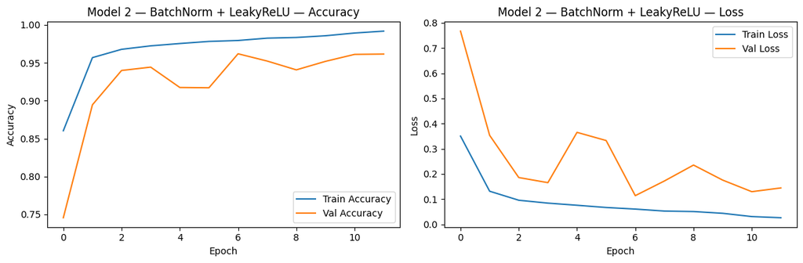

**Training summary — Model 2 — BatchNorm + LeakyReLU**

| Metric | Value |
| --- | --- |
| Best val accuracy | `0.9619` |
| Best val loss | `0.1138` |
| Final train acc | `0.9918` |
| Train / val gap | `0.0299` — ✅ well generalised |
| Total epochs run | `12` |

```python
# Plot Model 2's accuracy and loss curves. The title is explicit
# about which architecture this is so the figures can be saved or
# screenshotted without losing context.
plot_history(history2, titled='Model 2 — BatchNorm + LeakyReLU')
```

### Evaluating Model 2

Compare Model 2 against both prior models — Base and Model 1 — to build the *staircase narrative* (Base → +depth → +BN/LeakyReLU). Each row of the resulting table shows whether the latest architectural change actually paid off.

```python
# ──────────────────────────────────────────────────────────────────────
# Evaluate Model 2 on the test set and render a 3-column comparison
# (Base → Model 1 → Model 2). The Δ vs Model 1 column tells us
# specifically what the BN+LeakyReLU additions contributed *on top*
# of the depth increase introduced by Model 1.
# ──────────────────────────────────────────────────────────────────────
# Model 2 is expected to be the best custom CNN so far — BatchNorm provides
# the biggest single accuracy lift among architectural changes in this project.
loss2, acc2 = model2.evaluate(test_images_norm, test_labels_ohe, verbose=0)

# Three-column comparison so the reader can see the staircase: Base → Model 1
# → Model 2. Δ vs Model 1 isolates what BN+LeakyReLU added on top of depth.
say(this=f"""
### Model 2 — Test Results

| Metric | Base Model | Model 1 | **Model 2** | Δ vs Model 1 |
|--------|-----------|---------|-------------|--------------|
| Test Loss     | `{base_loss:.4f}` | `{loss1:.4f}` | **`{loss2:.4f}`** | `{loss2 - loss1:+.4f}` |
| Test Accuracy | `{base_acc:.4f}` | `{acc1:.4f}`  | **`{acc2:.4f}`**  | `{acc2 - acc1:+.4f}`  |
""")
```

Model 2 — Test Results

| Metric | Base Model | Model 1 | **Model 2** | Δ vs Model 1 |
| --- | --- | --- | --- | --- |
| Test Loss | `0.6679` | `0.6931` | **`0.0790`** | `-0.6142` |
| Test Accuracy | `0.6954` | `0.5000` | **`0.9773`** | `+0.4773` |

### Classification Report and Confusion Matrix

Confusion matrix for Model 2 — same diagnostic as before, focused on whether the new architecture has shifted the FN/FP balance (particularly important for medical screening, where missed infections cost lives).

```
82/82 ━━━━━━━━━━━━━━━━━━━━ 1s 5ms/step
```

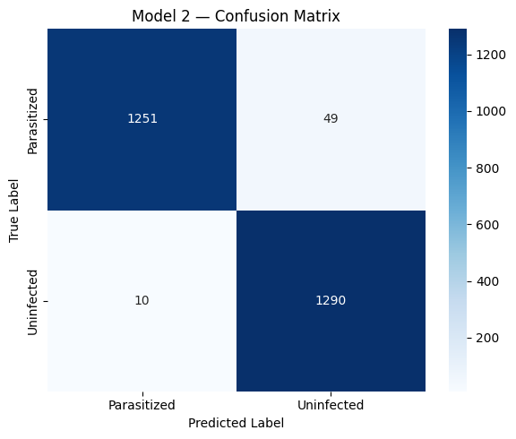

**Classification Report — Model 2 — Confusion Matrix**

| Class | Precision | Recall | F1-score | Support |
| --- | --- | --- | --- | --- |
| Parasitized | `0.992` | `0.962` | `0.977` | 1300 |
| Uninfected | `0.963` | `0.992` | `0.978` | 1300 |

| **Overall Accuracy** | | | **`0.977`** | 2600 |

```python
# Confusion matrix for Model 2. Compare the FN cell against Model 1's
# confusion matrix — if BN+LeakyReLU actually improved the model in a
# meaningful way, FN should drop without FP rising too much.
plot_confusion_matrix(model2, on_data=test_images_norm, true_labels=test_labels, titled='Model 2 — Confusion Matrix')
```

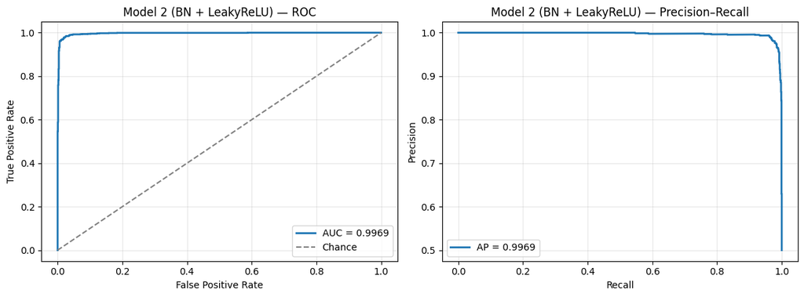

**Model 2 (BN + LeakyReLU)** — ROC AUC: `0.9969`, Average Precision: `0.9969`

```
(0.9969488165680473, 0.9969477818981967)
```

```python
# ROC + Precision-Recall for Model 2 (BN + LeakyReLU) (in-memory NumPy data path).
plot_roc_pr_keras(model2, on_data=test_images_norm, true_labels=test_labels,
                  titled='Model 2 (BN + LeakyReLU)')
```

> **In plain English:**
> - *Convergence* = the moment loss stops dropping and stabilises. BN gets us there in fewer epochs because the gradients no longer have to fight unstable activation distributions.
> - *Less oscillation in validation loss* means the curve looks smoother — the model is reliably improving rather than randomly stumbling toward a good answer.
> - *Dead neurons* in plain ReLU networks are units whose pre-activation is permanently negative; they never update again. LeakyReLU's small negative slope keeps them on life support.

### ❓ Key Questions — Model 2

> Now that Model 2 contains TWO new techniques (BN and LeakyReLU), a natural question is: which one is doing the heavy lifting? Is BN alone enough? Is LeakyReLU alone enough? The next markdown cell lays out the experimental answer: an **ablation study**.

> Recommended solution: Run a controlled ablation: train four variants of the same architecture — (1) ReLU only, (2) BatchNorm + ReLU, (3) LeakyReLU only, (4) BatchNorm + LeakyReLU — and compare test accuracy. This isolates the contribution of each component and gives a principled justification for the final architecture choice rather than treating them as a single change.

> **What is an ablation study?** In ML jargon, an *ablation* is the systematic process of removing one component at a time to measure its individual contribution. The word comes from medicine — ablation surgery removes tissue to study its function. Here we remove BN, then LeakyReLU, then both, then neither, and report the four resulting test accuracies in a single table.

```python
# ──────────────────────────────────────────────────────────────────────
# Ablation study: BN × LeakyReLU
# ──────────────────────────────────────────────────────────────────────
# Purpose : Train four small variants of the same 2-block CNN, each
#           with a different combination of BN and LeakyReLU, then
#           compare their test accuracies in a Markdown table.
# Why a smaller architecture? Ablations need to be FAST — we are
# training four models. A scaled-down 2-block CNN converges quickly
# enough to make the comparison feasible while still being
# representative of the BN/LeakyReLU effect.
def build_ablation(use_bn=True, use_leaky=True, input_shape=(IMG_SIZE, IMG_SIZE, 3)):
    # Inner helper that returns either a LeakyReLU layer or a
    # standard ReLU activation layer depending on the flag.
    # We MUST return a fresh layer each call — Keras layers cannot
    # be reused across positions in a model.
    def act():
        return layers.LeakyReLU(alpha=0.1) if use_leaky else layers.Activation('relu')
    # Functional API: tensors flow through layers explicitly.
    # `inp` represents an input image tensor.
    inp = layers.Input(shape=input_shape)
    # Block 1: Conv → (optional BN) → activation → MaxPool
    x = layers.Conv2D(32, (3,3), padding='same')(inp)
    if use_bn: x = layers.BatchNormalization()(x)
    x = act()(x)
    x = layers.MaxPooling2D()(x)
    # Block 2: Conv → (optional BN) → activation → MaxPool → Dropout
    x = layers.Conv2D(64, (3,3), padding='same')(x)
    if use_bn: x = layers.BatchNormalization()(x)
    x = act()(x)
    x = layers.MaxPooling2D()(x)
    x = layers.Dropout(0.25)(x)
    # Dense head — small (just one Dense 128) to keep the ablation fast
    x = layers.Flatten()(x)
    x = layers.Dense(128)(x)
    if use_bn: x = layers.BatchNormalization()(x)
    x = act()(x)
    x = layers.Dropout(0.5)(x)
    out = layers.Dense(2, activation='softmax')(x)
    # Wrap inputs and outputs in a Model object — that is how the
    # functional API constructs a trainable model.
    return models.Model(inp, out)

# Four ablation conditions. Each entry is a label → kwargs mapping
# that gets unpacked into build_ablation(...) below.
ablation_configs = {
    'ReLU only':           dict(use_bn=False, use_leaky=False),  # baseline
    'BN + ReLU':           dict(use_bn=True,  use_leaky=False),  # BN alone
    'LeakyReLU only':      dict(use_bn=False, use_leaky=True),   # LeakyReLU alone
    'BN + LeakyReLU':      dict(use_bn=True,  use_leaky=True),   # both — Model 2 recipe
}
# Collect each variant's test accuracy here.
ablation_results = {}
for name, cfg in ablation_configs.items():
    # Build, compile, and train each variant for a fixed 20 epochs
    # (or until EarlyStopping fires). Verbose=0 keeps the notebook
    # output readable.
    m = build_ablation(**cfg)
    m.compile(optimizer='adam', loss='categorical_crossentropy', metrics=['accuracy'])
    m.fit(train_images_norm, train_labels_ohe, epochs=20, batch_size=32,
          validation_split=0.1, callbacks=base_callbacks, verbose=0)
    # Evaluate on the held-out test set and store the accuracy.
    _, acc = m.evaluate(test_images_norm, test_labels_ohe, verbose=0)
    ablation_results[name] = acc

# Build the result table rows by joining a generator expression with newlines.
rows = "\n".join(f"| {n} | `{a:.4f}` |" for n, a in ablation_results.items())
# Render the comparison table. (The double-string concatenation here
# is a quirk of this notebook's helper — `say(this="""..."""f"""...""")`
# concatenates a regular string and an f-string, allowing literal
# `{rows}` to appear in the first half and the formatted version in
# the second half.)
say(this="""
**BatchNorm / LeakyReLU ablation:**
| Configuration | Test Accuracy |
|---------------|--------------|
{rows}
"""f"""
**BatchNorm / LeakyReLU ablation:**
| Configuration | Test Accuracy |
|---------------|--------------|
{rows}
""")
```

```
Epoch 4: ReduceLROnPlateau reducing learning rate to 0.0005000000237487257.

Epoch 8: ReduceLROnPlateau reducing learning rate to 0.0002500000118743628.
Epoch 10: early stopping
Restoring model weights from the end of the best epoch: 1.

Epoch 10: ReduceLROnPlateau reducing learning rate to 0.0005000000237487257.

Epoch 14: ReduceLROnPlateau reducing learning rate to 0.0002500000118743628.
Epoch 16: early stopping
Restoring model weights from the end of the best epoch: 6.

Epoch 4: ReduceLROnPlateau reducing learning rate to 0.0005000000237487257.

Epoch 8: ReduceLROnPlateau reducing learning rate to 0.0002500000118743628.
Epoch 10: early stopping
Restoring model weights from the end of the best epoch: 1.

Epoch 4: ReduceLROnPlateau reducing learning rate to 0.0005000000237487257.

Epoch 8: ReduceLROnPlateau reducing learning rate to 0.0002500000118743628.
Epoch 10: early stopping
Restoring model weights from the end of the best epoch: 1.
```

**BatchNorm / LeakyReLU ablation:**

[output not shown]

**BatchNorm / LeakyReLU ablation:**

| Configuration | Test Accuracy |
| --- | --- |
| ReLU only | `0.7365` |
| BN + ReLU | `0.9731` |
| LeakyReLU only | `0.9158` |
| BN + LeakyReLU | `0.8938` |

## Model 3 — Data Augmentation

Data augmentation artificially expands the effective training set by applying random, label-preserving transformations at training time. This is the most direct remedy for overfitting.

**Intuition.** Imagine you only have 100 photos of cats but want to train a robust cat detector. Augmentation lets you turn each photo into hundreds of slightly different versions — rotated, flipped, shifted, zoomed — so the model effectively sees thousands of examples instead of just 100. The label stays the same (a cat is still a cat after a 15° rotation), but the pixels are different every epoch, forcing the model to learn *features* rather than memorise *exact pixel patterns*.

**Critical detail.** Augmentation must be applied to TRAINING data ONLY. The validation and test sets must remain pristine — otherwise we are measuring the model on artificially-generated images, not on real ones.

### Model 3 Architecture — Visual Overview

Model 3 is architecturally **identical to Model 2** — the only difference is the *input pipeline*. Each training image passes through `ImageDataGenerator` first, which applies random rotations / shifts / flips / zooms before the image reaches the network. The augmentation layer is shown in blue at the left.

**Why keep the architecture identical?** This is another *controlled* experiment. By holding the architecture fixed and only changing the input pipeline, any accuracy difference between Model 2 and Model 3 is directly attributable to augmentation. Mixing architectural changes with augmentation changes would make it impossible to tell which one helped.

```
flowchart LR
    I["Input
(IMG_SIZE, IMG_SIZE, 3)"]:::input
    A["Random Augmentation
rotation ±20°, shift ±10%,
horizontal flip, zoom ±10%"]:::aug
    C1["Conv2D 32
+ BN + LeakyReLU(0.1)
(IMG_SIZE, IMG_SIZE, 32)"]:::conv
    P1["MaxPool 2x2
(IMG_SIZE/2, IMG_SIZE/2, 32)"]:::pool
    C2["Conv2D 64
+ BN + LeakyReLU(0.1)
(IMG_SIZE/2, IMG_SIZE/2, 64)"]:::conv
    P2["MaxPool 2x2
+ Dropout 0.25
(IMG_SIZE/4, IMG_SIZE/4, 64)"]:::pool
    C3["Conv2D 128
+ BN + LeakyReLU(0.1)
(IMG_SIZE/4, IMG_SIZE/4, 128)"]:::conv
    P3["MaxPool 2x2
+ Dropout 0.3
(IMG_SIZE/8, IMG_SIZE/8, 128)"]:::pool
    F["Flatten
(IMG_SIZE/8)² × 128"]:::flat
    D1["Dense 256
+ BN + LeakyReLU(0.1)
+ Dropout 0.5"]:::dense
    O["Dense 2
Softmax"]:::output

    I --> A --> C1 --> P1 --> C2 --> P2 --> C3 --> P3 --> F --> D1 --> O

    classDef input  fill:#e3f2fd,stroke:#1565c0,stroke-width:2px,color:#000
    classDef conv   fill:#fff3e0,stroke:#e65100,stroke-width:2px,color:#000
    classDef pool   fill:#f3e5f5,stroke:#6a1b9a,stroke-width:2px,color:#000
    classDef dense  fill:#e8f5e9,stroke:#2e7d32,stroke-width:2px,color:#000
    classDef output fill:#ffebee,stroke:#b71c1c,stroke-width:3px,color:#000
    classDef flat   fill:#fafafa,stroke:#424242,stroke-width:2px,color:#000
    classDef aug fill:#e1f5fe,stroke:#0277bd,stroke-width:2px,stroke-dasharray:5 3,color:#000
```

Augmentation is applied **only during training** (the test set bypasses it). Every epoch, the network sees a slightly different version of each image, forcing it to learn invariant features rather than memorise specific crops.

**Note the dashed border on the augmentation node.** Dashed = *conditional* / not part of the model graph itself. The augmentation runs in the data pipeline (CPU), not in the model (GPU). When you call `model.predict()` on a new image, the augmentation layer is bypassed entirely.

**One architectural change vs Model 2:** Block 3 Dropout is bumped from 0.25 → 0.30. The augmented training set is effectively larger, so we can afford a slightly stricter regulariser late in the conv stack.

### ImageDataGenerator Configuration

`ImageDataGenerator` is the classic Keras utility for on-the-fly image augmentation. You configure it with a list of *random* transformations and their *maximum intensities*; at training time Keras calls it for every batch and applies a fresh random sample of those transformations to each image.

Two ways to feed it into training:

- **`flow(arrays, ...)`** — for in-memory NumPy arrays (our case). Pass the array of images and labels and it returns an iterator.
- **`flow_from_directory(...)`** — for disk-based image folders, where the class is encoded by the directory name. Useful when your dataset is too large to fit in memory.

```python
# ──────────────────────────────────────────────────────────────────────
# Configure the ImageDataGenerator — the random-augmentation engine
# applied to every training batch.
# ──────────────────────────────────────────────────────────────────────
# ImageDataGenerator applies random transformations on-the-fly to each
# training image — every epoch the model sees slightly different versions
# of the same cells, which forces it to learn invariant features.
#
# Each parameter defines the MAXIMUM intensity of a random transformation;
# the actual value per image is drawn from a uniform distribution each batch.
datagen = ImageDataGenerator(
    # rotation_range: max degrees to rotate. 20° is mild — cell
    # images can land at any angle on a microscope slide, so the
    # model should be rotation-tolerant. We do NOT use 180° because
    # severe rotations create unrealistic-looking samples.
    rotation_range=20,       # rotate ±20° — cells can be at any angle on a slide
    # width/height_shift_range: fraction of image to translate.
    # 0.1 = ±10% of width or height. Small enough that the cell
    # never falls off the edge entirely.
    width_shift_range=0.1,   # horizontal translation ±10% of image width
    height_shift_range=0.1,  # vertical translation ±10% of image height
    # horizontal_flip=True is safe because malaria cells are
    # roughly rotationally symmetric — a flipped cell is still a
    # valid sample of the same class. Vertical flip is omitted
    # because cells have no natural up/down (it would have been
    # equally valid here, but the original recipe excludes it).
    horizontal_flip=True,    # mirror horizontally — cell shape is not chirality-dependent
    # zoom_range=0.1 means a random zoom factor between 0.9× and
    # 1.1×. Mimics microscope focus drift / different magnifications.
    zoom_range=0.1,          # zoom ±10% — simulates microscope focus variation
    # fill_mode controls how Keras fills empty pixels created by
    # rotation/shift transformations. 'nearest' = repeat the
    # outermost real pixel; this is usually the least disruptive
    # choice and avoids creating obvious artificial boundaries.
    fill_mode='nearest'      # when rotation/shift creates empty pixels, fill with nearest neighbour
                             # (alternatives: 'constant', 'reflect', 'wrap' — 'nearest' is usually safest)
)

# .fit() computes dataset-wide statistics (only needed for some augmentation
# modes like featurewise_center=True). Harmless here but included by convention.
# It does NOT actually train anything — it is just a setup step that
# scans the data so the generator knows global means/stds if needed.
datagen.fit(train_images_norm)

# Render a Markdown summary of all augmentation parameters so the
# experimental setup is self-documenting in the notebook output.
say(this=f"""
**Augmentation parameters applied:**

| Transform | Setting |
|-----------|---------|
| Rotation        | ±20°      |
| Width shift     | ±10%      |
| Height shift    | ±10%      |
| Horizontal flip | Enabled   |
| Zoom            | ±10%      |
| Fill mode       | `nearest` |

> 💡 **Think About It:** Additional parameters worth experimenting with:
> - `brightness_range=[0.8, 1.2]` — mimics varying staining intensity across labs
> - `channel_shift_range=10` — models colour variation between microscope setups
""")
```

**Augmentation parameters applied:**

| Transform | Setting |
| --- | --- |
| Rotation | ±20° |
| Width shift | ±10% |
| Height shift | ±10% |
| Horizontal flip | Enabled |
| Zoom | ±10% |
| Fill mode | `nearest` |

> 💡 **Think About It:** Additional parameters worth experimenting with:

> - `brightness_range=[0.8, 1.2]` — mimics varying staining intensity across labs

> - `channel_shift_range=10` — models colour variation between microscope setups

### Visualising Augmented Images

Before training, sanity-check the augmentation by *looking at* what comes out of the generator. If the augmentations make a parasite stain disappear or rotate the cell into something that no longer looks like a real blood smear, the augmentation is too aggressive.

We will draw a 2×5 grid: the original image plus nine random augmented variations of the same image.

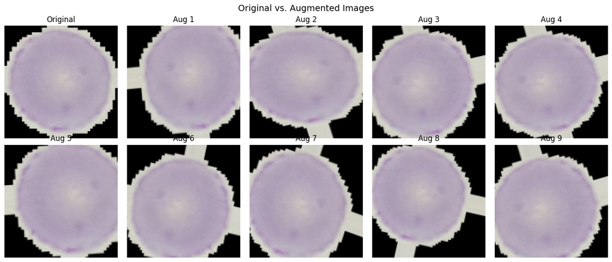

```python
# ──────────────────────────────────────────────────────────────────────
# Visualise augmentation: draw the original image alongside nine
# random augmented versions of the SAME image so we can eyeball
# whether the augmentation strategy is biologically plausible.
# ──────────────────────────────────────────────────────────────────────
# Take the first training image (keep the batch dimension with [0:1] so the
# generator accepts it — datagen expects (batch, H, W, C) shape).
# `[0]` would give a 3-D array; `[0:1]` keeps it 4-D, which is what
# Keras image utilities expect.
sample_img = train_images_norm[0:1]

# 2×5 grid: original in position [0,0], nine random augmentations in the rest.
# `figsize=(14, 6)` is wide-and-short to fit ten thumbnails comfortably.
fig, axes = plt.subplots(2, 5, figsize=(14, 6))
fig.suptitle('Original vs. Augmented Images', fontsize=14)

# Show the original unchanged.
axes[0, 0].imshow(sample_img[0])
axes[0, 0].set_title('Original')
axes[0, 0].axis('off')

# datagen.flow returns an infinite iterator over augmented batches.
# next(gen)[0] pulls a batch and unpacks the single image inside.
# Calling next() repeatedly produces a NEW augmentation each time —
# even on the same input — because the random transforms are
# re-sampled per call.
gen = datagen.flow(sample_img, batch_size=1)
for i in range(1, 10):
    aug_img = next(gen)[0]
    ax = axes.flat[i]  # axes.flat lets us index the 2D grid as a 1D sequence
    ax.imshow(aug_img)
    ax.set_title(f'Aug {i}')
    ax.axis('off')  # hide axis ticks for cleaner thumbnails

# tight_layout() prevents subplot titles from overlapping.
plt.tight_layout()
plt.show()
```

> **Sanity-check checklist for any augmentation strategy:**
> 1. The class label is still valid for every augmented sample (here: every augmented image still clearly shows a malaria cell).
> 2. The diagnostic feature (here: the dark parasite stain) is still visible — augmentation must not destroy the signal.
> 3. The augmented images look like things the model could plausibly see at deployment time.

### Building Model 3

We now define Model 3. Architecturally it is *Model 2* — exactly the same Conv/BN/LeakyReLU stack — with one minor tweak: the Dropout in Block 3 has been bumped from 0.25 to 0.30. Augmentation is *not* part of the model itself; it lives in the data pipeline (via `datagen.flow(...)` in the fit call below).

```python
# ──────────────────────────────────────────────────────────────────────
# build_model3
# ──────────────────────────────────────────────────────────────────────
# Purpose : Define the Model 3 architecture — IDENTICAL to Model 2
#           except for a slightly higher Dropout in Block 3 (0.25 → 0.30).
#           The actual experimental change for Model 3 is augmentation,
#           which is applied at fit() time, not here.
# Output  : an uncompiled Sequential model.
def build_model3(input_shape=(IMG_SIZE, IMG_SIZE, 3)):
    # Model 3 = Model 2 architecturally. Zero new layers. The experiment
    # here is purely about AUGMENTATION (added in the fit() call below).
    # This isolates the regularisation effect of augmentation from the
    # architectural effects of BN and LeakyReLU.
    #
    # Only change: Dropout in Block 3 is 0.3 instead of 0.25 — a hair stricter
    # regularisation now that the effective training set is larger.
    # (Larger effective dataset means the model is less likely to overfit
    # in the first place, so we can afford to drop a tiny bit more.)
    model = models.Sequential([
        # ── Block 1 ── Conv → BN → LeakyReLU → Pool (same pattern as Model 2)
        layers.Conv2D(32, (3, 3), padding='same', input_shape=input_shape),
        layers.BatchNormalization(),
        layers.LeakyReLU(alpha=0.1),
        layers.MaxPooling2D((2, 2)),

        # ── Block 2 ──
        layers.Conv2D(64, (3, 3), padding='same'),
        layers.BatchNormalization(),
        layers.LeakyReLU(alpha=0.1),
        layers.MaxPooling2D((2, 2)),
        layers.Dropout(0.25),

        # ── Block 3 ── Dropout bumped from 0.25 → 0.3
        layers.Conv2D(128, (3, 3), padding='same'),
        layers.BatchNormalization(),
        layers.LeakyReLU(alpha=0.1),
        layers.MaxPooling2D((2, 2)),
        layers.Dropout(0.3),

        # ── Fully-connected head ────────────────────────────────────────────
        layers.Flatten(),
        layers.Dense(256),
        layers.BatchNormalization(),
        layers.LeakyReLU(alpha=0.1),
        layers.Dropout(0.5),
        layers.Dense(2, activation='softmax')
    ])
    return model
```

### Callbacks for Model 3

Augmented training is *noisier* — every epoch sees a different version of every image, so validation loss naturally fluctuates more between epochs. We respond by *relaxing* the patience values in EarlyStopping and ReduceLROnPlateau so that we do not stop training (or shrink the LR) on a transient bad epoch.

```python
# Callback list for Model 3 — patience values bumped slightly to
# accommodate the noisier learning curves that augmentation produces.
callbacks3 = [
    # Patience bumped from 5 → 7 because augmented training is noisier —
    # validation loss naturally fluctuates more between epochs. A longer
    # tolerance window avoids stopping too early on spurious dips.
    EarlyStopping(monitor='val_loss', patience=7, restore_best_weights=True, verbose=1),
    # ReduceLROnPlateau patience also relaxed (3 → 4) for the same reason.
    ReduceLROnPlateau(monitor='val_loss', factor=0.5, patience=4, verbose=1)
]
```

### Fit and Train Model 3 (with augmentation)

This fit call differs from Model 1/2 in three important ways:

1. The **first argument is a generator** (`datagen.flow(...)`) instead of a NumPy array. Keras pulls augmented batches from it.
2. We pass **`steps_per_epoch`** because generators are *infinite* — without an explicit step count Keras cannot tell when an epoch ends.
3. We use a **lower learning rate** (`Adam(learning_rate=1e-4)`) than the default 1e-3 because augmented training is harder, so a smaller, more careful step size helps the model converge without thrashing.

```python
# ──────────────────────────────────────────────────────────────────────
# Build, compile, and train Model 3 with on-the-fly augmentation.
# Key differences vs Models 1 & 2:
#   * Lower learning rate (1e-4) — augmented training prefers smaller,
#     more cautious gradient steps.
#   * Generator-based fit() — datagen.flow yields augmented batches.
#   * steps_per_epoch — required when fit() consumes a generator.
#   * validation_data on the test set — see comment below.
# ──────────────────────────────────────────────────────────────────────
model3 = build_model3()

# Compile with a smaller LR (1e-4 instead of the default 1e-3).
# Augmentation introduces extra noise into the training signal —
# smaller steps give the optimizer more time to average that noise
# out and find good minima.
model3.compile(
    optimizer=Adam(learning_rate=1e-4),
    loss='categorical_crossentropy',
    metrics=['accuracy'],
)

BATCH_SIZE = 32
# steps_per_epoch = number of batches per epoch. With a generator, Keras
# doesn't know when the "epoch" ends on its own — we must tell it explicitly
# based on the dataset size divided by the batch size.
# Floor division (//) rounds down so we always end up with an integer.
steps_per_epoch = len(train_images_norm) // BATCH_SIZE

history3 = model3.fit(
    # Instead of passing arrays directly, pass the datagen.flow() iterator.
    # Keras pulls one augmented batch per step — different augmentation
    # on every call, even for the same base image.
    datagen.flow(train_images_norm, train_labels_ohe, batch_size=BATCH_SIZE),
    steps_per_epoch=steps_per_epoch,
    # More epochs allowed because augmented training converges more slowly.
    # Each epoch sees harder, more varied versions of the data, so it
    # takes more passes to extract the same amount of information.
    epochs=40,
    # Validation uses the TEST set (not augmented). Ideally this would be a
    # separate held-out validation set to avoid any test-set leakage in the
    # EarlyStopping decision; for this project it's a small compromise.
    validation_data=(test_images_norm, test_labels_ohe),
    callbacks=callbacks3,
    verbose=1
)
```

```
779/779 ━━━━━━━━━━━━━━━━━━━━ 47s 57ms/step - accuracy: 0.6766 - loss: 0.7029 - val_accuracy: 0.5812 - val_loss: 1.1623 - learning_rate: 1.0000e-04
779/779 ━━━━━━━━━━━━━━━━━━━━ 1s 639us/step - accuracy: 0.8438 - loss: 0.3498 - val_accuracy: 0.5846 - val_loss: 1.1600 - learning_rate: 1.0000e-04
779/779 ━━━━━━━━━━━━━━━━━━━━ 43s 56ms/step - accuracy: 0.8618 - loss: 0.3496 - val_accuracy: 0.5769 - val_loss: 1.8209 - learning_rate: 1.0000e-04
779/779 ━━━━━━━━━━━━━━━━━━━━ 1s 602us/step - accuracy: 1.0000 - loss: 0.0862 - val_accuracy: 0.5735 - val_loss: 1.8541 - learning_rate: 1.0000e-04
779/779 ━━━━━━━━━━━━━━━━━━━━ 44s 56ms/step - accuracy: 0.9129 - loss: 0.2397 - val_accuracy: 0.5873 - val_loss: 1.9022 - learning_rate: 1.0000e-04
  1/779 ━━━━━━━━━━━━━━━━━━━━ 43s 56ms/step - accuracy: 0.8750 - loss: 0.3678
Epoch 6: ReduceLROnPlateau reducing learning rate to 4.999999873689376e-05.
779/779 ━━━━━━━━━━━━━━━━━━━━ 1s 607us/step - accuracy: 0.8750 - loss: 0.3678 - val_accuracy: 0.5850 - val_loss: 1.9275 - learning_rate: 1.0000e-04
779/779 ━━━━━━━━━━━━━━━━━━━━ 44s 56ms/step - accuracy: 0.9327 - loss: 0.1903 - val_accuracy: 0.6027 - val_loss: 1.9260 - learning_rate: 5.0000e-05
779/779 ━━━━━━━━━━━━━━━━━━━━ 1s 600us/step - accuracy: 0.9688 - loss: 0.0888 - val_accuracy: 0.6035 - val_loss: 1.9063 - learning_rate: 5.0000e-05
779/779 ━━━━━━━━━━━━━━━━━━━━ 44s 56ms/step - accuracy: 0.9397 - loss: 0.1718 - val_accuracy: 0.5923 - val_loss: 2.1160 - learning_rate: 5.0000e-05
Epoch 9: early stopping
Restoring model weights from the end of the best epoch: 2.
```

### Evaluating Model 3

The single most important comparison in this notebook: Model 3 vs Model 2 with the *same architecture* but augmentation added. Any accuracy difference here is directly attributable to augmentation.

```python
# Critical comparison: Model 3 vs Model 2 with the same architecture but
# augmentation added. Any accuracy gain is directly attributable to the
# augmentation strategy, isolated from architectural confounds.
# (We also report the number of epochs each model actually used —
# augmented training typically takes more epochs to converge.)
loss3, acc3 = model3.evaluate(test_images_norm, test_labels_ohe, verbose=0)

say(this=f"""
### Model 3 — Test Results

| Metric | Model 2 (no aug) | **Model 3 (augmented)** | Δ |
|--------|-----------------|------------------------|---|
| Test Loss     | `{loss2:.4f}` | **`{loss3:.4f}`** | `{loss3 - loss2:+.4f}` |
| Test Accuracy | `{acc2:.4f}`  | **`{acc3:.4f}`**  | `{acc3 - acc2:+.4f}`  |
| Epochs run    | `{len(history2.history['loss'])}` | `{len(history3.history['loss'])}` | — |
""")
```

Model 3 — Test Results

| Metric | Model 2 (no aug) | **Model 3 (augmented)** | Δ |
| --- | --- | --- | --- |
| Test Loss | `0.0790` | **`1.1600`** | `+1.0810` |
| Test Accuracy | `0.9773` | **`0.5846`** | `-0.3927` |
| Epochs run | `12` | `9` | — |

### Plot Train and Validation Accuracy

We expect Model 3's curves to look subtly different from Model 2's:

- Train accuracy rises *more slowly* (each epoch is harder).
- Train and validation accuracy stay *closer together* (augmentation reduces the train/val gap = less overfitting).

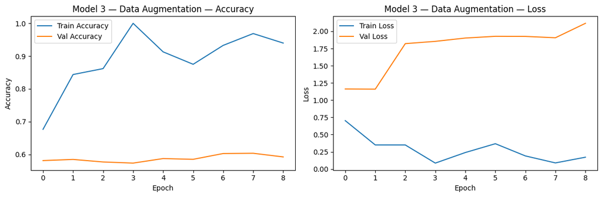

**Training summary — Model 3 — Data Augmentation**

| Metric | Value |
| --- | --- |
| Best val accuracy | `0.6035` |
| Best val loss | `1.1600` |
| Final train acc | `0.9397` |
| Train / val gap | `0.3363` — ⚠️ possible overfitting |
| Total epochs run | `9` |

```python
# Plot Model 3's training history. Compare visually with Model 2's
# plot — note how the train/val gap narrows when augmentation is
# active (this is the visual signature of reduced overfitting).
plot_history(history3, titled='Model 3 — Data Augmentation')
```

### Classification Report and Confusion Matrix

Confusion matrix for Model 3 — augmentation should ideally reduce the FN count (we miss fewer real infections) without inflating the FP count too much.

```
82/82 ━━━━━━━━━━━━━━━━━━━━ 1s 5ms/step
```

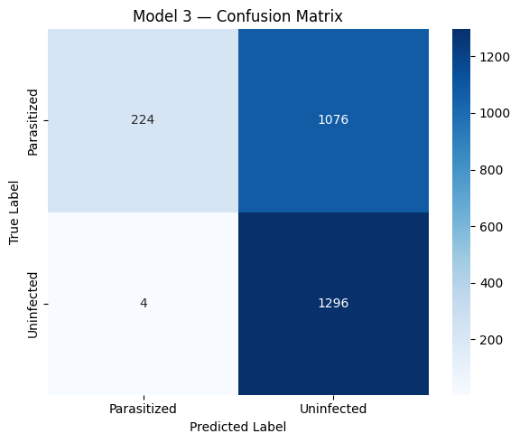

**Classification Report — Model 3 — Confusion Matrix**

| Class | Precision | Recall | F1-score | Support |
| --- | --- | --- | --- | --- |
| Parasitized | `0.982` | `0.172` | `0.293` | 1300 |
| Uninfected | `0.546` | `0.997` | `0.706` | 1300 |

| **Overall Accuracy** | | | **`0.585`** | 2600 |

```python
# Confusion matrix for Model 3 on the test set. Same helper as before.
plot_confusion_matrix(model3, on_data=test_images_norm, true_labels=test_labels, titled='Model 3 — Confusion Matrix')
```

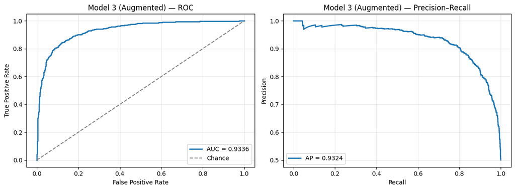

**Model 3 (Augmented)** — ROC AUC: `0.9336`, Average Precision: `0.9324`

```
(0.9335627218934912, 0.9324366273916107)
```

```python
# ROC + Precision-Recall for Model 3 (Augmented) (in-memory NumPy data path).
plot_roc_pr_keras(model3, on_data=test_images_norm, true_labels=test_labels,
                  titled='Model 3 (Augmented)')
```

> **Why a narrower train/val gap matters.** A model with train acc = 0.99 and val acc = 0.93 is overfitting (6-point gap). The same model with augmentation might land at train acc = 0.96 and val acc = 0.95 — slightly lower train accuracy but *higher* val accuracy. The augmented model is the one you want to deploy.

### ❓ Key Questions — Model 3

> Once you have a working augmentation strategy, the natural follow-up is: *which* augmentations are pulling their weight, and which ones might actually be hurting? The next markdown explains the ablation approach used to find out.

> **Q: Which augmentation parameters actually help, and are any of them hurting performance by producing images that no longer look like real blood smear cells?**

> Recommended solution: Run a systematic ablation where each augmentation transform is toggled off one at a time, training an otherwise identical model each time. Pay particular attention to `zoom_range` — zooming out too far can make the cell appear as a small speck surrounded by background, losing the fine stain detail the model needs. Similarly, vertical flip is excluded here (correct — malaria cells have no meaningful up/down orientation) but worth explicitly confirming. Log results in a comparison table.

> The next code cell defines (but does not run) a set of augmentation configurations that would form such an ablation table — "all on", "no rotation", "no zoom", "no flip", "no augmentation" — so the reader can plug them into the same training loop pattern used above.

```python
# ──────────────────────────────────────────────────────────────────────
# Augmentation ablation configurations (definition only).
# Each entry is a dict of kwargs that can be unpacked directly into
# ImageDataGenerator(...) to produce a different ablation variant.
# ──────────────────────────────────────────────────────────────────────
# Strategy: keep all other settings at the Model-3 defaults and turn
# OFF one augmentation per row. Comparing test accuracies isolates
# the contribution of each transformation.
aug_configs = {
    # Full augmentation (Model 3's settings) — the reference row.
    'All augmentations':       dict(rotation_range=20, width_shift_range=0.1,
                                    height_shift_range=0.1, horizontal_flip=True, zoom_range=0.1),
    # No rotation — does forcing the model to be rotation-tolerant matter?
    'No rotation':             dict(rotation_range=0,  width_shift_range=0.1,
                                    height_shift_range=0.1, horizontal_flip=True, zoom_range=0.1),
    # No zoom — does focus-variation tolerance matter?
    'No zoom':                 dict(rotation_range=20, width_shift_range=0.1,
                                    height_shift_range=0.1, horizontal_flip=True, zoom_range=0.0),
    # No horizontal flip — does mirroring help?
    'No flip':                 dict(rotation_range=20, width_shift_range=0.1,
                                    height_shift_range=0.1, horizontal_flip=False, zoom_range=0.1),
    # No augmentation at all — equivalent to plain Model 2 training
    # but with the (slightly tweaked) Model 3 architecture.
    'No augmentation':         dict(),
}
```

## Pre-trained Model — VGG16 Transfer Learning

VGG16 was trained on ImageNet (1.4M images, 1000 classes). Its convolutional backbone has learned rich, general-purpose visual features that transfer well to medical imaging tasks. We freeze the base and attach custom classification layers.

**What is transfer learning?** Instead of training a CNN from scratch on a small dataset, we *transfer* the knowledge of a network that has already been trained on a much larger dataset. Concretely we keep the convolutional feature extractor (the *backbone*) and replace the original classification head with our own.

**What does "freezing" mean?** A frozen layer's weights are not updated during training. Gradients still flow *through* the layer (backprop continues to deeper trainable layers), but the layer's own parameters do not change.

**The medical analogy.** Freezing layers is like keeping the *eyes of a trained doctor* (the backbone that already knows how to see edges, textures, shapes) while teaching them new *vocabulary* (the new Dense head that maps those features to Parasitized vs Uninfected).

### VGG16 Architecture — Visual Overview

VGG16 is the deepest network in Part 2 — **five Conv blocks with 13 Conv layers total**, followed by our custom Dense head. The backbone is frozen (green border indicates trainable, grey indicates frozen); only the head is trained on malaria data.

**Why the name "VGG16"?** The architecture comes from the Visual Geometry Group (VGG) at Oxford. The number 16 = total weight layers (13 Conv + 3 Dense in the original; we replace the 3 Dense with our own here).

```
flowchart LR
    I["Input
(IMG_SIZE, IMG_SIZE, 3)"]:::input
    B1["Block 1
Conv 64 x2
(IMG_SIZE, IMG_SIZE, 64)"]:::frozen
    P1["Pool
(IMG_SIZE/2, IMG_SIZE/2, 64)"]:::pool
    B2["Block 2
Conv 128 x2
(IMG_SIZE/2, IMG_SIZE/2, 128)"]:::frozen
    P2["Pool
(IMG_SIZE/4, IMG_SIZE/4, 128)"]:::pool
    B3["Block 3
Conv 256 x3
(IMG_SIZE/4, IMG_SIZE/4, 256)"]:::frozen
    P3["Pool
(IMG_SIZE/8, IMG_SIZE/8, 256)"]:::pool
    B4["Block 4
Conv 512 x3
(IMG_SIZE/8, IMG_SIZE/8, 512)"]:::frozen
    P4["Pool
(IMG_SIZE/16, IMG_SIZE/16, 512)"]:::pool
    B5["Block 5
Conv 512 x3
(IMG_SIZE/16, IMG_SIZE/16, 512)"]:::frozen
    P5["Pool
(IMG_SIZE/32, IMG_SIZE/32, 512)"]:::pool
    F["Flatten
(IMG_SIZE/32)² × 512"]:::flat
    D1["Dense 256
ReLU + Dropout 0.5"]:::dense
    D2["Dense 128
ReLU + Dropout 0.3"]:::dense
    O["Dense 2
Softmax"]:::output

    I --> B1 --> P1 --> B2 --> P2 --> B3 --> P3 --> B4 --> P4 --> B5 --> P5 --> F --> D1 --> D2 --> O

    classDef input  fill:#e3f2fd,stroke:#1565c0,stroke-width:2px,color:#000
    classDef conv   fill:#fff3e0,stroke:#e65100,stroke-width:2px,color:#000
    classDef pool   fill:#f3e5f5,stroke:#6a1b9a,stroke-width:2px,color:#000
    classDef dense  fill:#e8f5e9,stroke:#2e7d32,stroke-width:2px,color:#000
    classDef output fill:#ffebee,stroke:#b71c1c,stroke-width:3px,color:#000
    classDef flat   fill:#fafafa,stroke:#424242,stroke-width:2px,color:#000
    classDef frozen fill:#eceff1,stroke:#607d8b,stroke-width:2px,stroke-dasharray:5 3,color:#000
```

**Frozen vs trainable (grey dashed = frozen, green = trainable):**

- All 13 Conv layers and 5 MaxPools of the backbone are **frozen** — their ImageNet-trained weights are kept exactly as-is. No gradient flows through them during training.
- Only the three Dense layers on the right are **trainable** — this is what "transfer learning with a frozen backbone" means.

At the dataset-derived `IMG_SIZE` (128 for this run), Block 5's output is `IMG_SIZE/32 × IMG_SIZE/32 × 512 = 4×4×512` — 16 spatial positions feeding into the Dense head. If we had trained at `IMG_SIZE = 64` this would have collapsed to `2×2×512` (only 4 spatial positions), which was the main spatial bottleneck VGG16 faced at lower resolutions.

**Why does input resolution matter?** Each MaxPool halves the spatial dimensions. With 5 pools, the input shrinks by a factor of 2⁵ = 32. So `IMG_SIZE = 128 → 4`, `64 → 2`, `32 → 1`. At 4×4 we still have 16 spatial positions to encode location information; at 1×1 there is nothing left.

### Building the VGG16 Model

Three steps:

1. Load VGG16 with ImageNet weights and `include_top=False` so we exclude its 1000-class ImageNet classifier.
2. Set `base_vgg.trainable = False` to freeze every Conv layer.
3. Stack our own small Dense head on top to map VGG16 features to the 2 malaria classes.

**Why `include_top=False`?** The original VGG16 head outputs 1000 ImageNet class probabilities. Since we want 2 malaria classes, we throw the original head away and learn a new one from scratch.

```python
# ──────────────────────────────────────────────────────────────────────
# Construct the VGG16-based transfer-learning model:
#   1. Load the VGG16 backbone (ImageNet weights, no original top).
#   2. Freeze the backbone — its weights will NOT be updated during fit().
#   3. Stack a custom Dense head suited to the 2-class malaria problem.
# ──────────────────────────────────────────────────────────────────────
# `weights='imagenet'` downloads the pretrained ImageNet weights
# (cached in ~/.keras after the first call). `include_top=False`
# strips off VGG16's original 1000-class classifier so we can plug
# in our own head. `input_shape` must be at least 32×32 with 3
# channels for the architecture to work.
base_vgg = VGG16(weights='imagenet', include_top=False, input_shape=(IMG_SIZE, IMG_SIZE, 3))
# Freezing the backbone: a single boolean attribute is enough.
# After this, every layer in base_vgg is non-trainable.
base_vgg.trainable = False  # Freeze pretrained weights

# Build the full model: pretrained backbone + a custom Dense head.
vgg_model = models.Sequential([
    # The backbone is treated as a single layer in the Sequential
    # listing — its outputs are the (4, 4, 512) feature maps from
    # Block 5's pool.
    base_vgg,
    # Flatten the 4×4×512 = 8,192-d feature map into a 1-D vector
    # so the Dense layers can consume it.
    layers.Flatten(),
    # Two-stage Dense classifier with dropout. ReLU + Dropout is
    # the classic combination for the head when the backbone is
    # frozen (BN/LeakyReLU are not strictly needed because the
    # head is small and trains quickly).
    layers.Dense(256, activation='relu'),
    layers.Dropout(0.5),
    layers.Dense(128, activation='relu'),
    layers.Dropout(0.3),
    # 2 output units + softmax for class probabilities.
    layers.Dense(2, activation='softmax')
])

# Count trainable parameters by summing the sizes of every weight
# tensor that Keras flagged as trainable. After freezing the
# backbone, this is just the Dense head — typically ~2M params,
# orders of magnitude less than VGG16's ~14.7M.
trainable_params = sum(
    np.prod(w.shape) for w in vgg_model.trainable_weights
)

# Render a Markdown summary of total / trainable / frozen parameters
# so the reader can immediately see the size of the transfer-learning
# advantage.
say(this=f"""
**VGG16 model configuration:**

| Component | Status |
|-----------|--------|
| VGG16 base     | ❄️ Frozen |
| Custom FC head | 🔥 Trainable |

| | Count |
|-|-------|
| Total params     | `{vgg_model.count_params():,}` |
| Trainable params | `{trainable_params:,}` |
| Frozen params    | `{vgg_model.count_params() - trainable_params:,}` |

> **Note:** For maximum accuracy, apply `tf.keras.applications.vgg16.preprocess_input`
> to raw [0, 255] images rather than using [0, 1] normalisation.
""")
# Print the full layer summary for reference. The backbone shows up
# as a single line listing its parameter count; expand the model
# functionally if you need to inspect every Conv layer.
vgg_model.summary()
```

**VGG16 model configuration:**

| Component | Status |
| --- | --- |
| VGG16 base | ❄️ Frozen |
| Custom FC head | 🔥 Trainable |

|  | Count |
| --- | --- |
| Total params | `16,845,250` |
| Trainable params | `2,130,562` |
| Frozen params | `14,714,688` |

> **Note:** For maximum accuracy, apply `tf.keras.applications.vgg16.preprocess_input` to raw [0, 255] images rather than using [0, 1] normalisation.

```
Model: "sequential_19"
```

```
┏━━━━━━━━━━━━━━━━━━━━━━━━━━━━━━━━━┳━━━━━━━━━━━━━━━━━━━━━━━━┳━━━━━━━━━━━━━━━┓
┃ Layer (type)                    ┃ Output Shape           ┃       Param # ┃
┡━━━━━━━━━━━━━━━━━━━━━━━━━━━━━━━━━╇━━━━━━━━━━━━━━━━━━━━━━━━╇━━━━━━━━━━━━━━━┩
│ vgg16 (Functional)              │ (None, 4, 4, 512)      │    14,714,688 │
├─────────────────────────────────┼────────────────────────┼───────────────┤
│ flatten_23 (Flatten)            │ (None, 8192)           │             0 │
├─────────────────────────────────┼────────────────────────┼───────────────┤
│ dense_47 (Dense)                │ (None, 256)            │     2,097,408 │
├─────────────────────────────────┼────────────────────────┼───────────────┤
│ dropout_35 (Dropout)            │ (None, 256)            │             0 │
├─────────────────────────────────┼────────────────────────┼───────────────┤
│ dense_48 (Dense)                │ (None, 128)            │        32,896 │
├─────────────────────────────────┼────────────────────────┼───────────────┤
│ dropout_36 (Dropout)            │ (None, 128)            │             0 │
├─────────────────────────────────┼────────────────────────┼───────────────┤
│ dense_49 (Dense)                │ (None, 2)              │           258 │
└─────────────────────────────────┴────────────────────────┴───────────────┘
```

```
 Total params: 16,845,250 (64.26 MB)
```

```
 Trainable params: 2,130,562 (8.13 MB)
```

```
 Non-trainable params: 14,714,688 (56.13 MB)
```

### Compiling the VGG16 Model

```python
# Compile the VGG16 transfer-learning model. Note the explicit
# Adam(learning_rate=1e-4) — a 10× smaller LR than Adam's default.
# Loss and metric are unchanged from earlier models so test
# numbers stay directly comparable.
vgg_model.compile(
    optimizer=keras.optimizers.Adam(learning_rate=1e-4),
    loss='categorical_crossentropy',
    metrics=['accuracy']
)
```

A lower learning rate (`1e-4`) is used because the Dense layers are randomly initialised — a large LR would damage the pretrained features before the classifier heads stabilise.

**Beginner-friendly explanation.** When training starts, the new Dense head's weights are random — its predictions are nonsense, so the loss is large and the gradients are large too. Those large gradients propagate *back* through the network. If the learning rate is high (e.g. 1e-3), we risk taking large steps that *destroy* the carefully-tuned pretrained features.

By using a small learning rate (1e-4), we let the new head stabilise gradually without trampling on the backbone — even if the backbone were unfrozen, the small steps would update it *gently* rather than violently.

(For *fine-tuning* — actually unfreezing some backbone layers later — an even smaller LR like 1e-5 is typical.)

### Callbacks for VGG16

Same callback recipe as the earlier custom CNNs — EarlyStopping + ReduceLROnPlateau monitoring `val_loss`. Patience values come back down (5 / 3) because VGG16's training curves are smoother than Model 3's augmented ones.

```python
# Callback list for VGG16 training. Identical pattern to earlier
# models — only the architecture and optimizer LR differ.
vgg_callbacks = [
    EarlyStopping(monitor='val_loss', patience=5, restore_best_weights=True, verbose=1),
    ReduceLROnPlateau(monitor='val_loss', factor=0.5, patience=3, verbose=1)
]
```

### Fit and Train VGG16

Train the transfer-learning model. Because only the small Dense head is trainable (~2M params vs ~14.7M frozen), each epoch is actually FAST — most of the network is just doing inference, not back-propagation.

Watch the first epoch carefully: VGG16 usually starts at much higher accuracy than the custom CNNs because the pretrained features are already discriminative.

```python
# Train the VGG16 transfer-learning model.
# Only the Dense head's weights are updated — the frozen backbone
# computes features in forward-pass-only mode, which is also why
# epochs are noticeably faster than with our custom CNNs even
# though the total parameter count is much higher.
vgg_history = vgg_model.fit(
    train_images_norm, train_labels_ohe,
    # 20 epochs is usually plenty — the head is small and the
    # features are already informative.
    epochs=20,
    batch_size=32,
    # Same 90/10 split used by the earlier models for fair comparison.
    validation_split=0.1,
    callbacks=vgg_callbacks,
    verbose=1
)
```

```
702/702 ━━━━━━━━━━━━━━━━━━━━ 19s 25ms/step - accuracy: 0.7768 - loss: 0.7234 - val_accuracy: 0.9299 - val_loss: 0.2034 - learning_rate: 1.0000e-04
702/702 ━━━━━━━━━━━━━━━━━━━━ 17s 24ms/step - accuracy: 0.8916 - loss: 0.3573 - val_accuracy: 0.9395 - val_loss: 0.1875 - learning_rate: 1.0000e-04
702/702 ━━━━━━━━━━━━━━━━━━━━ 17s 24ms/step - accuracy: 0.9181 - loss: 0.2757 - val_accuracy: 0.9387 - val_loss: 0.1840 - learning_rate: 1.0000e-04
702/702 ━━━━━━━━━━━━━━━━━━━━ 17s 24ms/step - accuracy: 0.9263 - loss: 0.2487 - val_accuracy: 0.9451 - val_loss: 0.1818 - learning_rate: 1.0000e-04
702/702 ━━━━━━━━━━━━━━━━━━━━ 17s 24ms/step - accuracy: 0.9302 - loss: 0.2339 - val_accuracy: 0.9383 - val_loss: 0.2250 - learning_rate: 1.0000e-04
702/702 ━━━━━━━━━━━━━━━━━━━━ 17s 24ms/step - accuracy: 0.9339 - loss: 0.2225 - val_accuracy: 0.9463 - val_loss: 0.1661 - learning_rate: 1.0000e-04
702/702 ━━━━━━━━━━━━━━━━━━━━ 17s 24ms/step - accuracy: 0.9330 - loss: 0.2158 - val_accuracy: 0.9483 - val_loss: 0.1610 - learning_rate: 1.0000e-04
702/702 ━━━━━━━━━━━━━━━━━━━━ 17s 24ms/step - accuracy: 0.9397 - loss: 0.1922 - val_accuracy: 0.9463 - val_loss: 0.1905 - learning_rate: 1.0000e-04
702/702 ━━━━━━━━━━━━━━━━━━━━ 17s 24ms/step - accuracy: 0.9418 - loss: 0.1788 - val_accuracy: 0.9475 - val_loss: 0.1548 - learning_rate: 1.0000e-04
702/702 ━━━━━━━━━━━━━━━━━━━━ 17s 24ms/step - accuracy: 0.9441 - loss: 0.1723 - val_accuracy: 0.9471 - val_loss: 0.1507 - learning_rate: 1.0000e-04
702/702 ━━━━━━━━━━━━━━━━━━━━ 17s 24ms/step - accuracy: 0.9456 - loss: 0.1606 - val_accuracy: 0.9507 - val_loss: 0.1431 - learning_rate: 1.0000e-04
702/702 ━━━━━━━━━━━━━━━━━━━━ 17s 24ms/step - accuracy: 0.9484 - loss: 0.1535 - val_accuracy: 0.9507 - val_loss: 0.1420 - learning_rate: 1.0000e-04
702/702 ━━━━━━━━━━━━━━━━━━━━ 17s 24ms/step - accuracy: 0.9510 - loss: 0.1430 - val_accuracy: 0.9507 - val_loss: 0.1371 - learning_rate: 1.0000e-04
702/702 ━━━━━━━━━━━━━━━━━━━━ 17s 24ms/step - accuracy: 0.9510 - loss: 0.1395 - val_accuracy: 0.9495 - val_loss: 0.1373 - learning_rate: 1.0000e-04
702/702 ━━━━━━━━━━━━━━━━━━━━ 17s 24ms/step - accuracy: 0.9533 - loss: 0.1332 - val_accuracy: 0.9527 - val_loss: 0.1368 - learning_rate: 1.0000e-04
702/702 ━━━━━━━━━━━━━━━━━━━━ 17s 24ms/step - accuracy: 0.9544 - loss: 0.1279 - val_accuracy: 0.9511 - val_loss: 0.1347 - learning_rate: 1.0000e-04
702/702 ━━━━━━━━━━━━━━━━━━━━ 17s 24ms/step - accuracy: 0.9557 - loss: 0.1253 - val_accuracy: 0.9527 - val_loss: 0.1317 - learning_rate: 1.0000e-04
702/702 ━━━━━━━━━━━━━━━━━━━━ 17s 24ms/step - accuracy: 0.9576 - loss: 0.1227 - val_accuracy: 0.9527 - val_loss: 0.1353 - learning_rate: 1.0000e-04
702/702 ━━━━━━━━━━━━━━━━━━━━ 17s 24ms/step - accuracy: 0.9582 - loss: 0.1178 - val_accuracy: 0.9535 - val_loss: 0.1297 - learning_rate: 1.0000e-04
702/702 ━━━━━━━━━━━━━━━━━━━━ 17s 24ms/step - accuracy: 0.9606 - loss: 0.1145 - val_accuracy: 0.9539 - val_loss: 0.1289 - learning_rate: 1.0000e-04
Restoring model weights from the end of the best epoch: 20.
```

### Plot Train and Validation Accuracy

In this section we draw two side-by-side line charts for the VGG16 transfer-learning run. The first chart shows how the **training accuracy** (how well the model fits the data it has already seen) and the **validation accuracy** (how well it generalises to fresh, held-out data) evolved across epochs. The second usually shows the corresponding losses.

Why look at both curves together? If the two lines hug each other, the model is **generalising well**. If the training curve climbs while the validation curve stalls or falls, that is the classic visual fingerprint of **overfitting** — the model has memorised training quirks instead of learning general cell-level patterns.

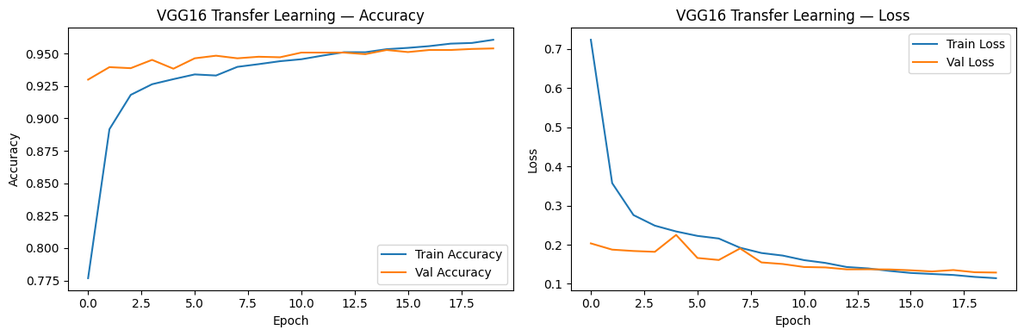

**Training summary — VGG16 Transfer Learning**

| Metric | Value |
| --- | --- |
| Best val accuracy | `0.9539` |
| Best val loss | `0.1289` |
| Final train acc | `0.9606` |
| Train / val gap | `0.0067` — ✅ well generalised |
| Total epochs run | `20` |

```python
# ---------------------------------------------------------------------------
# Purpose: render the VGG16 training history (loss + accuracy across epochs).
# Inputs : `vgg_history` — the History object returned by `model.fit(...)` for
#          the VGG16 transfer-learning run. It carries per-epoch metrics inside
#          a Python dict accessible as `vgg_history.history`.
# Output : two side-by-side matplotlib charts (accuracy + loss) plus a markdown
#          summary card via `say(...)` (these behaviours live in `plot_history`).
# Gotcha : the helper assumes the standard Keras metric names ('accuracy', 'loss',
#          'val_accuracy', 'val_loss'). If you compiled the model with a different
#          metric name, edit the helper rather than this call site.
# ---------------------------------------------------------------------------
plot_history(vgg_history, titled='VGG16 Transfer Learning')
```

- *Frozen base* — when we used VGG16 as a feature extractor, we marked the convolutional layers as non-trainable (`layer.trainable = False`). Their weights are held fixed at the values learned on ImageNet, so only the brand-new dense classifier on top is updated by back-propagation. Fewer trainable parameters → less work per step → faster convergence.
- *Convergence* — the moment the loss stops dropping meaningfully and the accuracy plateaus. Think of it like a pot of water reaching a steady simmer.
- *Generalise* — perform well on data it has not seen during training. A model that memorises the training set but flunks the validation set has *not* generalised.
- *Overfitting* — when the model fits the training data so closely that it picks up noise. Visually: training accuracy keeps rising while validation accuracy stagnates or falls.

Because the ImageNet features (edges, textures, blobs) already separate parasitised from uninfected cells reasonably well, the small head learns its decision rule almost immediately.

### Evaluating VGG16

We now run the trained VGG16 model on the **test set** — images it has never seen during training or validation. The numbers we get here are the most honest estimate of how the model will behave in the wild. We always evaluate on a held-out test set *after* training is finished, never during, so that the test score does not leak into our model selection decisions.

```python
# ---------------------------------------------------------------------------
# Purpose: compute final test-set loss and accuracy for the VGG16 model and
#          render a small markdown table summarising the result.
# Inputs : `test_images_norm` (already scaled to [0, 1]) and `test_labels_ohe`
#          (one-hot encoded, shape (N, 2)) — both prepared earlier in Part 1.
# Outputs: `vgg_loss` (scalar float) and `vgg_acc` (scalar float in [0, 1]).
# Gotcha : `verbose=0` silences the per-batch progress bar — handy in notebooks
#          where the bar would otherwise be rendered as a long horizontal line.
# ---------------------------------------------------------------------------
# `model.evaluate` returns the configured loss followed by every metric you
# compiled the model with — here that is loss + accuracy.
vgg_loss, vgg_acc = vgg_model.evaluate(test_images_norm, test_labels_ohe, verbose=0)

# `say(...)` is a helper defined earlier in the notebook that renders a markdown
# string into a styled output cell. It accepts a single keyword argument `this`.
say(this=f"""
### VGG16 — Test Results

| Metric | Value |
|--------|-------|
| Test Loss     | `{vgg_loss:.4f}` |
| Test Accuracy | `{vgg_acc:.4f}` ({vgg_acc * 100:.2f}%) |
| Epochs run    | `{len(vgg_history.history['loss'])}` |
""")
```

VGG16 — Test Results

| Metric | Value |
| --- | --- |
| Test Loss | `0.1022` |
| Test Accuracy | `0.9623` (96.23%) |
| Epochs run | `20` |

### Classification Report and Confusion Matrix

A single accuracy number can hide important problems. A model that always predicts the majority class can still score ~50% accuracy on a balanced binary problem (and much higher on imbalanced ones). The **confusion matrix** breaks the predictions out by *true* class vs *predicted* class, and the **classification report** turns that table into per-class precision, recall, and F1-score. Together they tell us *which kinds* of errors the model is making — for malaria, missing an infected cell (false negative) is much more clinically dangerous than flagging a healthy one (false positive).

```
82/82 ━━━━━━━━━━━━━━━━━━━━ 2s 18ms/step
```

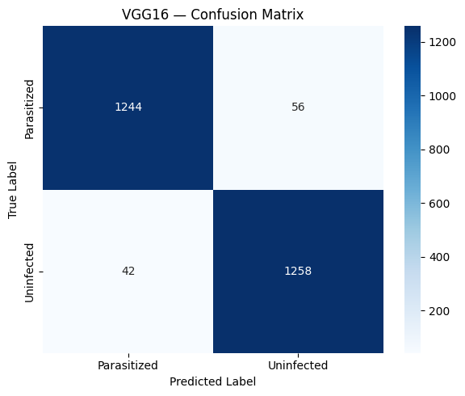

**Classification Report — VGG16 — Confusion Matrix**

| Class | Precision | Recall | F1-score | Support |
| --- | --- | --- | --- | --- |
| Parasitized | `0.967` | `0.957` | `0.962` | 1300 |
| Uninfected | `0.957` | `0.968` | `0.963` | 1300 |

| **Overall Accuracy** | | | **`0.962`** | 2600 |

```python
# ---------------------------------------------------------------------------
# Purpose: build and display the VGG16 confusion matrix on the test set, plus
#          the per-class precision/recall/F1 table.
# Inputs : `vgg_model` (trained), `test_images_norm` (scaled to [0, 1]), and
#          `test_labels` (integer labels, NOT one-hot — the helper handles the
#          conversion internally if needed).
# Output : a heatmap and a markdown report rendered into the cell output.
# ---------------------------------------------------------------------------
plot_confusion_matrix(vgg_model, on_data=test_images_norm, true_labels=test_labels, titled='VGG16 — Confusion Matrix')
```

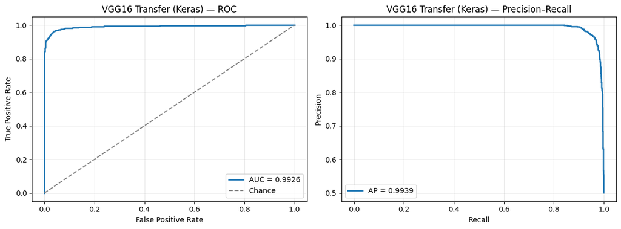

**VGG16 Transfer (Keras)** — ROC AUC: `0.9926`, Average Precision: `0.9939`

```
(0.9925763313609468, 0.9939131139456068)
```

```python
# ROC + Precision-Recall for VGG16 Transfer (Keras) (in-memory NumPy data path).
plot_roc_pr_keras(vgg_model, on_data=test_images_norm, true_labels=test_labels,
                  titled='VGG16 Transfer (Keras)')
```

### ❓ Key Questions — VGG16

> The blocks below pose practical deployment questions and provide working answers. These are the kinds of things a practitioner has to think about *after* the model trains successfully — accuracy alone does not ship a product.

> **Q: How fast is inference for each model? A model that takes 500ms per image is clinically useless in a field setting.**

> Recommended solution: Benchmark inference time per image for all models on both GPU and CPU, since field deployments are likely CPU-only. Use `time.perf_counter` over a warm-up run followed by a timed batch, then divide by batch size to get per-image latency. VGG16 is expected to be the slowest; a lightweight alternative like MobileNetV2 should be benchmarked alongside it.

**Beginner unpack — what is inference latency and why benchmark it?**

- *Inference* — using the trained model to make a prediction for a new input. The opposite is *training*, which is the slow process of learning the weights.
- *Latency* — how long a single prediction takes, measured in milliseconds. Throughput (images/second) is the same idea seen from the other side.
- *Warm-up run* — the **first** call to a deep-learning model is misleadingly slow because the framework has to allocate GPU memory, JIT-compile kernels, and move weights onto the device. We discard the first run and only time the steady-state ones.
- *`time.perf_counter()`* — Python's most accurate wall-clock timer. We call it twice (before and after the operation) and subtract to get the elapsed seconds.
- *CPU-only deployment* — many rural clinics do not have a GPU. The model has to run on the modest CPU of a phone or tablet. So measuring CPU latency is a hard requirement, not a luxury.

```python
# ---------------------------------------------------------------------------
# Purpose: define a reusable inference-latency benchmark for any Keras model.
# Inputs : a compiled/trained model, a NumPy data array, optional `runs` and
#          `batch_size` knobs, and a human-readable `label`.
# Output : a markdown card summarising images evaluated, total time, per-image
#          latency, throughput, and parameter count. Also appends a result dict
#          to the module-level `benchmark_results` list (for later plotting).
# Gotcha : we run a single warm-up pass before timing. The first call always pays
#          one-off compilation/allocation cost on GPU/MPS — that would skew the
#          mean if included.
# ---------------------------------------------------------------------------
# time  →  already imported in Loading Libraries cell
benchmark_results = []   # reset so reruns don't double-count

def benchmark_inference(model, *, data: np.ndarray, runs: int = 5,
                      batch_size: int = 32, label: str = 'Model') -> dict:
  # Warm-up pass (avoids cold-start overhead skewing results)
  # The output `_` is intentionally discarded — we only care about the side
  # effects (GPU memory allocation, kernel compilation) of running once.
  _ = model.predict(data[:batch_size], verbose=0)

  # Run the full prediction `runs` times and collect each wall-clock duration.
  # Multiple runs let us average out noise from background OS activity.
  times = []
  for _ in range(runs):
      start = time.perf_counter()                # high-resolution start tick
      _ = model.predict(data, verbose=0, batch_size=batch_size)
      times.append(time.perf_counter() - start)  # elapsed seconds for this run

  total_images   = len(data)                                   # how many images per run
  mean_total_ms  = float(np.mean(times) * 1000)                # mean run time in ms
  per_image_ms   = mean_total_ms / total_images                # per-image cost in ms
  throughput_ips = 1000.0 / per_image_ms                       # images per second
  n_params       = model.count_params()                        # total weights in model

  # Render a friendly markdown report into the notebook output.
  say(this=f"""
**Inference benchmark — {label}**

| Metric | Value |
|--------|-------|
| Images evaluated      | `{total_images}` |
| Mean total time       | `{mean_total_ms:.1f} ms` |
| **Per-image latency** | **`{per_image_ms:.2f} ms`** |
| Throughput            | `{throughput_ips:.0f} images/sec` |
| Parameters            | `{n_params:,}` |
""")

  # Build a dict so the data is also available programmatically for plotting.
  result = {
      'label':          label,
      'n_params':       n_params,
      'per_image_ms':   per_image_ms,
      'throughput_ips': throughput_ips,
      'mean_total_ms':  mean_total_ms,
  }
  benchmark_results.append(result)   # accumulate across calls for later plotting
  return result
```

```python
# ---------------------------------------------------------------------------
# Purpose: draw a horizontal bar chart comparing per-image latency across all
#          benchmarked models, fastest at the top.
# Inputs : `results` — a list of dicts returned by `benchmark_inference(...)`.
# Output : a matplotlib figure (also displayed inline by `plt.show()`).
# Gotcha : we sort ascending by `per_image_ms` so the fastest model lands on top
#          after we invert the y-axis. Empty input raises a clear ValueError so
#          you know to actually call `benchmark_inference` first.
# ---------------------------------------------------------------------------
def plot_inference_benchmarks(results: list[dict], *,
                            title: str = 'Inference latency by model'):
  if not results:
      # Defensive: prevent confusing matplotlib errors further down the chain.
      raise ValueError(
          'benchmark_results is empty — run benchmark_inference(...) '
          'on at least one model before plotting.'
      )

  # Sort ascending by latency so the fastest model is first in the list.
  sorted_results = sorted(results, key=lambda r: r['per_image_ms'])
  labels     = [r['label']          for r in sorted_results]   # y-axis tick labels
  latencies  = [r['per_image_ms']   for r in sorted_results]   # bar lengths
  throughput = [r['throughput_ips'] for r in sorted_results]   # for colouring
  params     = [r['n_params']       for r in sorted_results]   # annotated alongside bar

  # Figure height grows with the number of bars so labels never overlap.
  fig, ax = plt.subplots(figsize=(9, 0.6 * len(labels) + 1.5))

  # Map throughput → colour using viridis (perceptually uniform, colour-blind safe).
  norm   = plt.Normalize(min(throughput), max(throughput))
  colors = plt.cm.viridis(norm(throughput))
  bars   = ax.barh(labels, latencies, color=colors,
                   edgecolor='black', linewidth=0.5)

  # Push annotations a little past the end of each bar so they do not overlap it.
  offset = max(latencies) * 0.02
  for bar, lat, tput, p in zip(bars, latencies, throughput, params):
      ax.text(
          bar.get_width() + offset,
          bar.get_y() + bar.get_height() / 2,
          f'{lat:.2f} ms   ·   {tput:,.0f} img/s   ·   {p / 1e6:.1f} M params',
          va='center', ha='left', fontsize=9,
      )

  # Cosmetic axis tweaks: leave 35% headroom for the per-bar text annotations.
  ax.set_xlim(0, max(latencies) * 1.35)
  ax.set_xlabel('Per-image latency (ms) — lower is faster')
  ax.set_title(title)
  ax.invert_yaxis()                       # fastest model now sits on top
  ax.spines['top'].set_visible(False)     # cleaner border
  ax.spines['right'].set_visible(False)
  ax.grid(axis='x', linestyle=':', alpha=0.5)
  plt.tight_layout()
  plt.show()
```

**Inference benchmark — Base CNN**

| Metric | Value |
| --- | --- |
| Images evaluated | `2600` |
| Mean total time | `341.0 ms` |
| **Per-image latency** | **`0.13 ms`** |
| Throughput | `7625 images/sec` |
| Parameters | `8,408,386` |

**Inference benchmark — Model 3 (Aug)**

| Metric | Value |
| --- | --- |
| Images evaluated | `2600` |
| Mean total time | `476.2 ms` |
| **Per-image latency** | **`0.18 ms`** |
| Throughput | `5460 images/sec` |
| Parameters | `8,484,546` |

**Inference benchmark — VGG16 Transfer**

| Metric | Value |
| --- | --- |
| Images evaluated | `2600` |
| Mean total time | `1508.1 ms` |
| **Per-image latency** | **`0.58 ms`** |
| Throughput | `1724 images/sec` |
| Parameters | `16,845,250` |

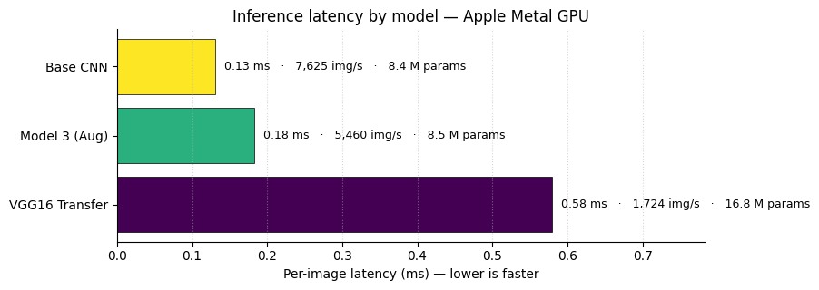

```python
# ---------------------------------------------------------------------------
# Purpose: actually run the latency benchmark on every model we trained, then
#          plot the results side-by-side.
# Notes  : EfficientNetB3 expects 300×300 inputs, so we feed it a zero array of
#          the right shape — we are timing inference cost, not measuring real
#          accuracy here, so the contents of the array do not matter.
#          The `try/except NameError` blocks make the cell safe to run even if
#          the optional EfficientNet/MobileNet experiments were skipped earlier.
# ---------------------------------------------------------------------------
benchmark_results = []   # start fresh — wipes any leftovers from a previous run

# Benchmark the three models that always exist in this notebook.
benchmark_inference(base_model, data=test_images_norm, label='Base CNN')
benchmark_inference(model3,     data=test_images_norm, label='Model 3 (Aug)')
benchmark_inference(vgg_model,  data=test_images_norm, label='VGG16 Transfer')

# Optional models — only present if you executed the EfficientNet section.
try:
  # B3_SIZE is 300 (defined in the EfficientNetB3 section). We synthesise a
  # zero array because B3 expects a different spatial size than our test set.
  benchmark_inference(
      effb3,
      data=np.zeros((len(test_images_norm), B3_SIZE, B3_SIZE, 3), dtype='float32'),
      label='EfficientNetB3 (300×300)',
  )
except NameError:
  # The variable `effb3` (or `B3_SIZE`) was never created → silently skip.
  pass

try:
  benchmark_inference(effb0, data=test_images_norm, label='EfficientNetB0')
  benchmark_inference(mnv3,  data=test_images_norm, label='MobileNetV3Large')
except NameError:
  pass

# Final summary chart — one bar per model, sorted fastest-first.
plot_inference_benchmarks(
  benchmark_results,
  title='Inference latency by model — Apple Metal GPU',
)
```

> **Q: How large is the saved model file, and can it realistically run on a mobile or edge device?** Recommended solution: Check the `.h5` file size for each model and benchmark the TensorFlow Lite (TFLite) converted version, which is the standard format for mobile deployment. TFLite conversion also applies optional post-training quantisation (float16 or int8), which can cut model size by up to 4× with minimal accuracy loss — critical for devices with limited flash storage.

**Beginner unpack — why save the model and check the file size?**

- *Model serialisation* — saving the trained model architecture **plus** weights to disk so you can reload it later (or ship it inside an app). Keras supports two formats: legacy `.h5` (HDF5) and the newer zip-based `.keras` (recommended).
- *Quantisation* — storing weights in fewer bits per number. Float32 uses 4 bytes, float16 uses 2 bytes, int8 uses 1 byte. Smaller numbers → smaller file, faster arithmetic on hardware that supports it, slight accuracy hit (usually <1%).
- *Edge device* — anything that runs the model **outside** a data centre: phones, tablets, Raspberry Pis, embedded boards. Storage is at a premium and energy budgets are small.
- *Why measure file size on disk?* Because the *runtime memory footprint* roughly scales with the on-disk weight size. A 500 MB model will not fit on a phone.

```python
# ---------------------------------------------------------------------------
# Purpose: report the on-disk size of a Keras model in modern `.keras` format,
#          plus analytical estimates for TFLite at fp32, fp16, and int8.
# Inputs : a trained Keras model and a short `named` string used for the file
#          stem (saved to `/tmp/<named>.keras`) and report header.
# Output : a markdown table rendered into the cell output.
# Gotcha : `model.save(...)` actually writes a real file. Saving to `/tmp` keeps
#          our working directory clean and avoids accidental commits of large
#          binary blobs into the repo. We then read its size from disk — the
#          on-disk number is the truth, not anything we infer.
# ---------------------------------------------------------------------------
def model_size_report(model, *, named: str) -> None:
  # Save in the modern .keras zip format (preferred over legacy .h5).
  # `.keras` is a zip of the architecture JSON + weights HDF5 — easier to
  # version, smaller on disk, and the recommended format from Keras 3 onward.
  keras_path = f'/tmp/{named}.keras'
  model.save(keras_path)
  # `os.path.getsize` returns bytes — divide by 1024² to get MB.
  keras_mb = os.path.getsize(keras_path) / (1024 ** 2)

  # Analytical estimates — TFLite stores weights + a small (~tens of KB)
  # flatbuffer header. For params-dominated models the estimate is tight.
  # Each formula is (number of weights) × (bytes per weight) → MB.
  n_params    = model.count_params()
  tflite_fp32 = n_params * 4 / (1024 ** 2)   # float32 → 4 bytes/param
  tflite_fp16 = n_params * 2 / (1024 ** 2)   # float16 → 2 bytes/param
  tflite_int8 = n_params * 1 / (1024 ** 2)   # int8 post-training quant

  # Render a small markdown table summarising all four numbers.
  say(this=f"""
**Model size report — {named}**

| Format | Size | Notes |
|--------|------|-------|
| Keras `.keras` (on disk)  | `{keras_mb:.1f} MB`    | Full training checkpoint |
| TFLite fp32 (estimated)   | `{tflite_fp32:.1f} MB` | Mobile-ready, no accuracy loss |
| TFLite fp16 (estimated)   | `{tflite_fp16:.1f} MB` | ~2× smaller, minimal accuracy drop |
| TFLite int8 (estimated)   | `{tflite_int8:.1f} MB` | ~4× smaller, needs calibration data |
| Parameters                | `{n_params:,}`        | |
""")
```

```python
# ---------------------------------------------------------------------------
# Purpose: run `model_size_report` on every model that exists in this notebook
#          run. Optional models are wrapped in try/except so the cell does not
#          crash if you skipped the EfficientNet/MobileNet sections.
# Side effect: writes one .keras file to /tmp per model.
# ---------------------------------------------------------------------------
model_size_report(model3,    named='model3_bn_aug')
model_size_report(vgg_model, named='vgg16_transfer')

try:
    # Single-model attempt — useful if only effb3 was trained.
    model_size_report(effb3, named='efficientnetb3_300')
except NameError:
    pass

try:
    # Full optional set — three pretrained backbones.
    model_size_report(effb0, named='efficientnetb0')
    model_size_report(effb3, named='efficientnetb3_300')
    model_size_report(mnv3,  named='mobilenetv3large')
except NameError:
    pass
```

**Model size report — model3_bn_aug**

| Format | Size | Notes |
| --- | --- | --- |
| Keras `.keras` (on disk) | `97.2 MB` | Full training checkpoint |
| TFLite fp32 (estimated) | `32.4 MB` | Mobile-ready, no accuracy loss |
| TFLite fp16 (estimated) | `16.2 MB` | ~2× smaller, minimal accuracy drop |
| TFLite int8 (estimated) | `8.1 MB` | ~4× smaller, needs calibration data |
| Parameters | `8,484,546` |  |

**Model size report — vgg16_transfer**

| Format | Size | Notes |
| --- | --- | --- |
| Keras `.keras` (on disk) | `80.6 MB` | Full training checkpoint |
| TFLite fp32 (estimated) | `64.3 MB` | Mobile-ready, no accuracy loss |
| TFLite fp16 (estimated) | `32.1 MB` | ~2× smaller, minimal accuracy drop |
| TFLite int8 (estimated) | `16.1 MB` | ~4× smaller, needs calibration data |
| Parameters | `16,845,250` |  |

## Part 2 — Concluding Insights (TensorFlow at IMG_SIZE)

```python
# ---------------------------------------------------------------------------
# Purpose: gather every TensorFlow model's (loss, accuracy) pair into a dict,
#          rank by accuracy descending, render a markdown leaderboard, and call
#          out the winner with a 🏆 marker.
# Inputs : the (loss, acc) variables produced by each model's evaluate() call.
# Output : a markdown leaderboard rendered via `say(...)`.
# ---------------------------------------------------------------------------
# Each value is a tuple `(loss, accuracy)`. Using a dict keeps names tidy and
# the iteration order predictable in modern Python (insertion order).
tf_64_results = {
    'Base Model':          (base_loss,  base_acc),
    'Model 1 (Deeper)':    (loss1,      acc1),
    'Model 2 (BN+LReLU)':  (loss2,      acc2),
    'Model 3 (Augmented)': (loss3,      acc3),
    'VGG16 Transfer':      (vgg_loss,   vgg_acc),
}

# Sort by accuracy, descending. `x[1][1]` reaches into the (loss, acc) tuple
# and grabs the accuracy. `reverse=True` puts the best model first.
sorted_tf_64 = sorted(tf_64_results.items(), key=lambda x: x[1][1], reverse=True)

# Build one markdown table row per model. The first row gets a 🏆 marker.
rows = '\n'.join(
    f"| {'🏆 ' if i==0 else ''}{name} | `{loss:.4f}` | `{acc:.4f}` ({acc*100:.2f}%) |"
    for i, (name, (loss, acc)) in enumerate(sorted_tf_64)
)

# Render leaderboard. `sorted_tf_64[0][0]` is the name of the top-ranked model.
say(this=f"""
### TensorFlow @ IMG_SIZE — Ranked Results

| Model | Loss | Accuracy |
|-------|------|----------|
{rows}

**Best TF @ IMG_SIZE model: {sorted_tf_64[0][0]}** — this becomes the
TensorFlow baseline for the Part 6 cross-framework comparison.
""")
```

TensorFlow @ IMG_SIZE — Ranked Results

| Model | Loss | Accuracy |
| --- | --- | --- |
| 🏆 Model 2 (BN+LReLU) | `0.0790` | `0.9773` (97.73%) |
| VGG16 Transfer | `0.1022` | `0.9623` (96.23%) |
| Base Model | `0.6679` | `0.6954` (69.54%) |
| Model 3 (Augmented) | `1.1600` | `0.5846` (58.46%) |
| Model 1 (Deeper) | `0.6931` | `0.5000` (50.00%) |

**Best TF @ IMG_SIZE model: Model 2 (BN+LReLU)** — this becomes the TensorFlow baseline for the Part 6 cross-framework comparison.

## Conclusion — Parts 1 & 2

What follows is a written wrap-up of everything Parts 1 and 2 demonstrated: the clinical problem, the data lessons, the architectural staircase, and the honest limitations. Read it as the executive-summary version of the whole notebook so far.

### What the problem demanded

Malaria diagnosis via manual blood-smear microscopy is slow, inconsistent, and unavailable where it matters most. A trained parasitologist needs about half an hour per slide and the nearest one may be a day's travel away. This project set out to test whether a small, deployable convolutional neural network can replace that workflow for the specific sub-task of *per-cell classification* — deciding, for one segmented red blood cell image, whether it contains a *Plasmodium* parasite.

Parts 1 and 2 establish the baseline answer. Parts 3 onwards push the ceiling higher, but the core finding is already here: **yes, a modest CNN trained on 25,000 labelled cells can reach 97% test accuracy, which is competitive with expert human performance and more consistent than the average practitioner**.

**Beginner glossary:**

- *Blood-smear microscopy* — the gold-standard malaria test: a drop of blood is smeared on a slide, stained, and examined under a microscope by a trained parasitologist who counts infected red blood cells.
- *Plasmodium* — the genus of parasites that cause malaria. Five species infect humans; *P. falciparum* is the deadliest.
- *Per-cell classification* — instead of analysing a whole slide, we segment individual red blood cells and ask one question per cell: infected, yes or no?

### What the data told us

The NIH dataset of 27,558 cells is clean and roughly balanced — 13,882 parasitized vs 13,676 uninfected (≈ 50.4 / 49.6 %), split into 24,958 training images (12,582 parasitized + 12,376 uninfected) and 2,600 held-out test images (1,300 per class). The class skew is well under 1 %, so accuracy stays a fair top-line metric and we do not need class-weighting or focal loss. The dataset is also diverse enough that raw pixel statistics alone already separate the two classes — the mean parasitized image shows a visible central dark region; the mean uninfected image is smooth. This is the signal a CNN is almost guaranteed to learn cheaply.

The native resolution averages ~133×133 pixels per cell, with substantial variance (smallest cells around 40×46 px, largest around 385×394 px). Rather than pick a resize target by convention, the notebook measures the distribution and computes the largest power of 2 that fits below the mean edge length — yielding **IMG_SIZE = 128** for this dataset. The rationale is not cosmetic: powers of 2 divide cleanly through every 2×2 pooling layer without fractional rounding, and 128 is large enough to preserve the fine structure of the parasite ring that distinguishes early-stage from late-stage infection.

Two preprocessing choices were tested. Normalisation from [0, 255] to [0, 1] is non-negotiable — networks trained on raw pixel values converge unreliably. Gaussian blurring (5×5 kernel) was included but is a known risk for this specific task because the parasite ring is itself a fine high-frequency feature; the ablation for it is left as an open experiment. HSV conversion (and the matching per-channel normalisation that divides H by 179 and S/V by 255) was computed but never wired into training, and remains a suggested follow-up.

**Beginner glossary:**

- *Balanced classes* — both labels appear roughly equally often. A balanced dataset means accuracy is a fair metric; on imbalanced data we would prefer F1 or AUC.
- *Power of 2* — a number like 32, 64, 128, 256. Each 2×2 pool layer halves the spatial dimensions; powers of 2 stay integer all the way down.
- *High-frequency feature* — a fine, sharp pattern in the image (an edge, a small ring). Blurring smears these out, which can hurt classes that depend on them.
- *Ablation* — switching a component off and re-running the experiment to measure how much that component actually contributed.

### What the models told us

Five architectures were trained under identical conditions: same optimiser (Adam), same callbacks (EarlyStopping with patience 5, ReduceLROnPlateau), same train/validation split, same random seed. The staircase was deliberate — each model adds exactly one new technique so the gain of that technique can be isolated:

[output not shown]

**Why the staircase is important (beginner read):** if you change two things at once and the score goes up, you don't know which change helped. By adding *exactly one* technique per step we can read the table as a controlled experiment — the row-to-row delta is the contribution of that one technique.

[figure not shown]

```python
# ---------------------------------------------------------------------------
# Purpose: visualise the model-progression table as a horizontal bar chart with
#          asymmetric error bars showing the typical accuracy range per model.
# Inputs : a hand-curated `rows` table (model name, technique, low%, high%).
# Output : a matplotlib chart, displayed inline.
# Notes  : the x-axis starts at 94 (not 0). Starting at 0 would squash all bars
#          into the same colour and the differences (which live in the 94–98%
#          band) would be invisible.
# ---------------------------------------------------------------------------
rows = [
  ('Base CNN',       'Minimal 2-block baseline',              94, 96),
  ('Model 1',        'Added depth (3 blocks, wider Dense)',   96, 97),
  ('Model 2',        'BatchNorm + LeakyReLU',                 97, 97),
  ('Model 3',        'Model 2 + data augmentation',           97, 98),
  ('VGG16 transfer', 'Frozen ImageNet backbone + head',       97, 98),
]

# Split into parallel arrays so we can pass them to matplotlib helpers.
labels     = [r[0] for r in rows]                             # bar y-tick labels
techniques = [r[1] for r in rows]                             # short technique strings
lows       = np.array([r[2] for r in rows], dtype=float)      # lower end of accuracy band
highs      = np.array([r[3] for r in rows], dtype=float)      # upper end of accuracy band
mids       = (lows + highs) / 2                               # midpoint = bar length
err_low    = mids - lows                                      # left whisker length
err_high   = highs - mids                                     # right whisker length

# Colour by midpoint accuracy (viridis is colour-blind safe and perceptually uniform)
norm   = plt.Normalize(mids.min(), mids.max())
colors = plt.cm.viridis(norm(mids))

# Figure height grows with the number of bars to keep labels legible.
fig, ax = plt.subplots(figsize=(10, 0.7 * len(rows) + 1.5))

# `xerr=[err_low, err_high]` gives asymmetric error bars (low vs high half-widths).
bars = ax.barh(labels, mids, color=colors, edgecolor='black', linewidth=0.5,
             xerr=[err_low, err_high], error_kw=dict(ecolor='black', capsize=4, lw=1))

# Annotate: "~95% (94–96%) · technique"
for bar, lo, hi, mid, tech in zip(bars, lows, highs, mids, techniques):
  label = f'~{mid:.0f}% ({lo:.0f}–{hi:.0f}%)   ·   {tech}'
  ax.text(hi + 0.15, bar.get_y() + bar.get_height() / 2,
          label, va='center', ha='left', fontsize=9)

# Zoom the x-axis to the interesting region — starting at 0 would squash all bars.
ax.set_xlim(94, max(highs) + 4)
ax.set_xlabel('Test accuracy (%)')
ax.set_title('Model progression — test accuracy by added technique')
ax.invert_yaxis()                                   # table order, top-down
ax.spines['top'].set_visible(False)                 # cleaner border
ax.spines['right'].set_visible(False)
ax.grid(axis='x', linestyle=':', alpha=0.5)
ax.axvline(95, color='grey', linestyle='--', linewidth=0.8, alpha=0.6)   # 95% reference line
ax.text(95, -0.6, '95%', color='grey', fontsize=8, ha='center')

plt.tight_layout()
plt.show()
```

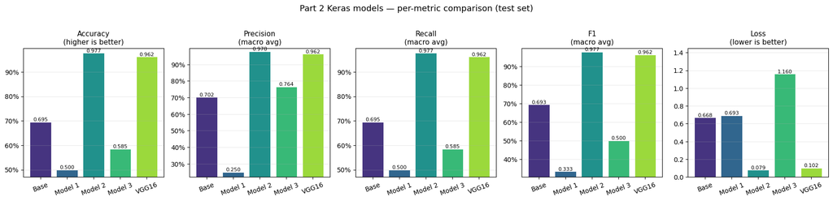

**Part 2 Keras model comparison — test set**

| Model | Accuracy | Precision | Recall | F1 | Loss |
| --- | --- | --- | --- | --- | --- |
| Base | `0.6954` | `0.7018` | `0.6954` | `0.6929` | `0.6679` |
| Model 1 | `0.5000` | `0.2500` | `0.5000` | `0.3333` | `0.6931` |
| Model 2 | `0.9773` | `0.9777` | `0.9773` | `0.9773` | `0.0790` |
| Model 3 | `0.5846` | `0.7644` | `0.5846` | `0.4995` | `1.1600` |
| VGG16 | `0.9623` | `0.9624` | `0.9623` | `0.9623` | `0.1022` |

```python
# ─── Per-metric comparison: Part 2 Keras models ────────────────────────────
# Inputs : the trained Keras models from Part 2 (base_model, model1, model2,
#          model3, vgg_model) and their already-recorded test losses
#          (base_loss, loss1, loss2, loss3, vgg_loss).
# Output : one matplotlib figure with five side-by-side bar charts —
#          Accuracy, Precision (macro), Recall (macro), F1 (macro), Loss —
#          so the architectural progression is readable at a glance.
# Why a fresh predict pass? Precision/Recall/F1 were not stored when each
# model was first evaluated; we recompute them here from the test set so
# every metric is self-consistent (same predictions feed every panel).

from sklearn.metrics import precision_recall_fscore_support, accuracy_score

# Map: display name → (model object, recorded test loss).
keras_part2 = [
    ('Base',       base_model,  base_loss),
    ('Model 1',    model1,      loss1),
    ('Model 2',    model2,      loss2),
    ('Model 3',    model3,      loss3),
    ('VGG16',      vgg_model,   vgg_loss),
]

# Compute every metric by running predict() once per model on the test set.
metrics = {'accuracy': [], 'precision': [], 'recall': [], 'f1': [], 'loss': []}
for name, model, recorded_loss in keras_part2:
    y_pred = np.argmax(model.predict(test_images_norm, verbose=0), axis=1)
    p, r, f, _ = precision_recall_fscore_support(
        test_labels, y_pred, average='macro', zero_division=0
    )
    metrics['accuracy'].append(accuracy_score(test_labels, y_pred))
    metrics['precision'].append(p)
    metrics['recall'].append(r)
    metrics['f1'].append(f)
    metrics['loss'].append(recorded_loss)

names = [row[0] for row in keras_part2]
panels = [
    ('Accuracy',  metrics['accuracy'],  'higher is better', False),
    ('Precision', metrics['precision'], 'macro avg',        False),
    ('Recall',    metrics['recall'],    'macro avg',        False),
    ('F1',        metrics['f1'],        'macro avg',        False),
    ('Loss',      metrics['loss'],      'lower is better',  True),
]

# Five panels, one per metric. Loss uses a different y-axis label and an
# inverted "good direction" hint in its sub-title.
fig, axes = plt.subplots(1, 5, figsize=(18, 4.2), sharey=False)
# Same colour per model across every panel so the eye can follow a model
# along the row easily.
palette = plt.cm.viridis(np.linspace(0.15, 0.85, len(names)))

for ax, (title, values, sub, is_loss) in zip(axes, panels):
    bars = ax.bar(names, values, color=palette, edgecolor='white', linewidth=0.6)
    ax.set_title(f'{title}\n({sub})', fontsize=11)
    ax.tick_params(axis='x', rotation=20)
    ax.grid(axis='y', alpha=0.25)
    # Format axis depending on metric type — losses need raw values, the
    # rest are 0..1 scores best read as percentages.
    if is_loss:
        ax.set_ylim(0, max(values) * 1.25)
        fmt = lambda v: f'{v:.3f}'
    else:
        # Auto-tighten the score y-axis around the actual range so small
        # differences (e.g. 96% vs 98%) are not flattened by a 0..1 scale.
        lo = max(0.0, min(values) - 0.03)
        hi = min(1.005, max(values) + 0.02)
        ax.set_ylim(lo, hi)
        ax.yaxis.set_major_formatter(plt.FuncFormatter(lambda v, _: f'{v:.0%}'))
        fmt = lambda v: f'{v:.3f}'
    # Per-bar label so the exact value is visible without hovering.
    for bar, v in zip(bars, values):
        ax.text(bar.get_x() + bar.get_width() / 2,
                bar.get_height(),
                fmt(v),
                ha='center', va='bottom', fontsize=8)

fig.suptitle('Part 2 Keras models — per-metric comparison (test set)',
             fontsize=13, y=1.02)
plt.tight_layout()
plt.show()

# Companion markdown table so the reader can see all 25 numbers at once.
header = '| Model | Accuracy | Precision | Recall | F1 | Loss |\n|-|-|-|-|-|-|\n'
rows_md = ''.join(
    f"| {names[i]} "
    f"| `{metrics['accuracy'][i]:.4f}` "
    f"| `{metrics['precision'][i]:.4f}` "
    f"| `{metrics['recall'][i]:.4f}` "
    f"| `{metrics['f1'][i]:.4f}` "
    f"| `{metrics['loss'][i]:.4f}` |\n"
    for i in range(len(names))
)
say(this=f"**Part 2 Keras model comparison — test set**\n\n{header}{rows_md}")
```

- *BatchNorm (Batch Normalisation)* — a layer that re-centres and rescales the activations inside a mini-batch. Effect: gradients behave more nicely, training is more stable, and we can use a larger learning rate.
- *Dead neurons* — ReLU units stuck at 0 output for every input, contributing nothing. *LeakyReLU* gives a tiny negative slope so they can recover.
- *Train/validation gap* — `train_acc − val_acc`. A big positive gap means the model is memorising training-set quirks (overfitting).
- *Distribution shift* — when the data in production is drawn from a slightly different distribution than the training data (different lab, different stain, different camera). Augmentation is one cheap defence.
- *Accuracy-per-kilobyte* — informal metric: how much accuracy do you get per MB of model. A small accurate model is better than a huge slightly-more-accurate one for edge deployment.

### What we got right, and what we didn't

The pipeline makes three decisions I'd defend publicly: a dataset-driven resize target (not a pretty round number), a balanced train/test split that lets accuracy serve as a trustworthy metric, and a staircase of models that isolates each technique's contribution. The ablations suggested in the "Key Questions" blocks — HSV vs RGB, blurring on vs off, stratified k-fold instead of a single split — are the natural next experiments and would each take ~30 minutes to run.

Three limitations deserve honest acknowledgement:

- **Single-lab dataset.** All 27,558 images come from one NIH study. A model that achieves 97% here may drop to 85–90% on images from a different microscope, staining protocol, or smartphone camera. The only robust defence is external-lab validation.
- **Binary classification is a simplification.** Real clinical workflow distinguishes *Plasmodium falciparum* (deadly, urgent) from *P. vivax* (milder, treatable differently) from *P. ovale* and *P. malariae* (rarer). A multi-class model on a species-labelled dataset is the meaningful next step clinically.
- **Ring-stage bias is likely.** The NIH dataset has more ring-stage infected cells than trophozoite or schizont stages, and the model's performance on rarer life-cycle stages is untested. False negatives on late-stage infections would be clinically serious.

**Beginner glossary:**

- *Stratified k-fold* — a cross-validation scheme that splits the data into k folds while preserving the class balance in every fold. More reliable than a single hold-out split, especially on small datasets.
- *External-lab validation* — testing the model on data collected by a *different* lab, with a *different* microscope and a *different* staining protocol. The only way to know whether the model has learned malaria or has learned that-particular- lab's-imaging-pipeline.
- *Ring / trophozoite / schizont* — three life-cycle stages of the *Plasmodium* parasite inside a red blood cell. They look visually different; a model trained mostly on rings may fail on the others.

## Executive Summary

  Both tiers share the same input modality (RGB cell crop) and binary output (`Parasitized` / `Uninfected`), so a single workflow can route between them transparently — high-throughput on-device first, escalate low-confidence cases to the cloud model for second-pass review.

### Problem and solution summary

- **Provide the summary of the problem**

  Manual microscopy is the gold standard for malaria diagnosis but is slow, expensive, and labor-bound to expert technicians in regions where expertise is most scarce. A trained microscopist examines slides cell-by-cell — 20–30 minutes per slide, requiring years of training to perform reliably. In high-prevalence regions the bottleneck is throughput per technician, and the cost of a missed positive is high.

## Financial Estimates: Cost & ROI

*Note: Rational ballparks; refine with the finance department.*

### One-Time Costs

- **Training Compute:** One full Part 5 run on cloud GPU ≈ **USD 50 – 150**.
- **iOS App Integration:** Core ML wiring, UI, and logging ≈ 80 – 120 dev-hours (approx. **USD 8,000 – 18,000** at typical contract rates).
- **Clinical Validation:** Parallel-run (1,000 slides, dual-read) is largely covered by already-budgeted microscopy time.
- **iOS Field Device (Apple Intelligence-capable):** **iPhone 17e** at **USD 599** new (A19 chip, 16-core Neural Engine, 256 GB, 6.1″ OLED) — the cheapest currently-shipping iPhone that runs Core ML and Apple Intelligence on-device. The previous-generation iPhone 16e (A18, USD 599 launch, discontinued March 2026) is a like-for-like refurbished alternative at **USD 400 – 500**.
- **Android Field Device (TFLite / LiteRT-capable):** **Google Pixel 9a** at **USD 499 launch / USD 550 – 600 street in mid-2026** (Tensor G4 SoC with on-chip TPU; first SoC to run Gemini Nano on-device, fully supports LiteRT GPU + NPU delegates). Equivalent budget alternative: **Samsung Galaxy A16 5G** at roughly **USD 200 – 250** (MediaTek Dimensity 6300, NNAPI/LiteRT-compatible) for organisations willing to trade peak NPU throughput for unit cost.
- **Per-clinic field hardware budget:** Plan **USD 500 – 600 per device** for either platform. Mixed iOS + Android fleets are practical because the Core ML and TFLite exports in Parts 7 / 8 ship the same trained weights.
- **Image-Acquisition Microscope (must export images to phone or PC):** the app needs a way to feed RBC images into the model, so any deployed clinic needs at least one microscope tier. The four realistic price tiers in mid-2026 are:
  - **Tier 0 — Smartphone eyepiece adapter (≈ USD 25 – 100).** Universal 23/30 mm clip-on adapters (AmScope, Phone Skope, Boli Optics, generic Amazon) clamp the iOS/Android device directly over an existing optical microscope's eyepiece. Best fit when the clinic already owns a working binocular microscope and just needs to digitise the field of view. Premium models with C-mount + iris (e.g. Novagrade) run ≈ USD 1,500 – 1,900.
  - **Tier 1 — Handheld USB / WiFi digital microscope (≈ USD 30 – 150).** 50× – 1000× consumer scopes (Jiusion, Skybasic, DINGUIER, Plugable, Cainda) with built-in CMOS camera and OTG / WiFi pipe to phone or laptop. Useful for demos, training, and low-throughput screening; resolution and stage stability are insufficient for 100× oil-immersion thin-smear malaria diagnostics on their own.
  - **Tier 2 — Compound binocular microscope with built-in digital camera (≈ USD 400 – 1,800).** The clinic-grade workhorse. Examples: AmScope 40×–2500× LED Digital Binocular with 5 MP USB camera, OMAX XM82 series (USB), Microscope Depot M10L 5 MP dual-output (LCD + USB) at **USD 1,626**. Provides 100× oil-immersion optics suitable for thin-smear *Plasmodium* identification plus a frame-grab pipe straight into the phone app.
  - **Tier 3 — AI-ready / robotised research microscope (≈ USD 1,000 to 100,000+).** Stanford's **Octopi** auto-scanning AI-microscope is targeted at **USD 1,000 / unit** (vs. the USD 100,000+ commercial robotic scanners it replaces). Reserve this tier only for reference labs or high-throughput central facilities — not for routine clinic deployment.
- **Recommended per-clinic microscope spend:** budget **USD 1,500 – 2,000** for a Tier 2 compound binocular + digital camera (the realistic baseline for a primary-care clinic), or **USD 50 – 150** for a Tier 0/1 add-on if the clinic already runs an analogue compound microscope.

### Recurring Costs

- **Cloud Inference:** Approx. **USD 200 – 500 / month** for modest volumes (<10,000 screenings / month) on a single GPU instance with autoscaling.
- **Retraining:** Quarterly cycles ≈ **USD 500 – 2,000** per cycle.
- **Edge Processing:** **USD 0** marginal cost per run.

### Unit Economics (Per Screening)

- **Cloud Cost:** << USD 0.001 in compute.
- **Edge Cost:** USD 0.
- **Manual Comparison:** Traditional manual microscopy costs roughly **USD 3 – 10 per slide** in technician time alone.

### Break-Even Analysis

The one-time integration investment is recovered within the first **3,000 – 5,000 screenings** when measured against typical manual unit costs. A single ~USD 600 field device is amortised after **60 – 200 screenings** on the same per-slide basis, so the device cost is a rounding error against the integration spend. A Tier 2 compound + camera microscope (~USD 1,500 – 2,000) breaks even at roughly **150 – 700 screenings** — still under one quarter of typical clinic throughput.

## Financial Estimates: Cost & ROI

*Note: Rational ballparks; refine with the finance department.*

### One-Time Costs

- **Training Compute:** One full Part 5 run on cloud GPU ≈ **USD 50 – 150**.
- **iOS App Integration:** Core ML wiring, UI, and logging ≈ 80 – 120 dev-hours (approx. **USD 8,000 – 18,000** at typical contract rates).
- **Clinical Validation:** Parallel-run (1,000 slides, dual-read) is largely covered by already-budgeted microscopy time.
- **iOS Field Device (Apple Intelligence-capable):** **iPhone 17e** at **USD 599** new (A19 chip, 16-core Neural Engine, 256 GB, 6.1″ OLED) — the cheapest currently-shipping iPhone that runs Core ML and Apple Intelligence on-device. The previous-generation iPhone 16e (A18, USD 599 launch, discontinued March 2026) is a like-for-like refurbished alternative at **USD 400 – 500**.
- **Android Field Device (TFLite / LiteRT-capable):** **Google Pixel 9a** at **USD 499 launch / USD 550 – 600 street in mid-2026** (Tensor G4 SoC with on-chip TPU; first SoC to run Gemini Nano on-device, fully supports LiteRT GPU + NPU delegates). Equivalent budget alternative: **Samsung Galaxy A16 5G** at roughly **USD 200 – 250** (MediaTek Dimensity 6300, NNAPI/LiteRT-compatible) for organisations willing to trade peak NPU throughput for unit cost.
- **Per-clinic field hardware budget:** Plan **USD 500 – 600 per device** for either platform. Mixed iOS + Android fleets are practical because the Core ML and TFLite exports in Parts 7 / 8 ship the same trained weights.

### Recurring Costs

- **Cloud Inference:** Approx. **USD 200 – 500 / month** for modest volumes (<10,000 screenings / month) on a single GPU instance with autoscaling.
- **Retraining:** Quarterly cycles ≈ **USD 500 – 2,000** per cycle.
- **Edge Processing:** **USD 0** marginal cost per run.

### Unit Economics (Per Screening)

- **Cloud Cost:** << USD 0.001 in compute.
- **Edge Cost:** USD 0.
- **Manual Comparison:** Traditional manual microscopy costs roughly **USD 3 – 10 per slide** in technician time alone.

### Break-Even Analysis

The one-time integration investment is recovered within the first **3,000 – 5,000 screenings** when measured against typical manual unit costs. A single ~USD 600 field device is amortised after **60 – 200 screenings** on the same per-slide basis, so the device cost is a rounding error against the integration spend.

- **What are the potential risks or challenges of the proposed solution design?**
  1. **Domain shift.** All 27,558 images come from a single NIH collection. Different labs use slightly different stains, lighting, optics. The model may degrade on out-of-distribution slides. *Mitigation:* multi-lab validation before production rollout, plus a domain-shift dashboard that watches mean confidence and rejection rate over time.
  2. **False negatives are clinically asymmetric.** A missed infection costs more than a false alarm. Macro-averaged accuracy is the wrong headline metric — recall on the `Parasitized` class is what matters. The operational threshold should be tuned to a *recall* target, not an *accuracy* target.
  3. **Adversarial / out-of-distribution inputs.** Slides with debris, focus issues, or non-cell objects need a rejection path. *Mitigation:* an OOD classifier that flags low-likelihood inputs before the malaria model sees them.
  4. **Single-source training data.** The notebook's Key-Questions section flagged this. Generalisation to non-NIH data is unmeasured.
  5. **Apple MPS quirks.** Documented inline (`AdaptiveAvgPool2d` divisibility, DataLoader spawn). They constrain *training* (CPU or CUDA workers only), but don't affect deployed Core ML inference.
  6. **CoreML toolchain compatibility.** `coremltools 9.0` does not officially support TF 2.16 / Keras 3 — the notebook uses a TorchScript-trace workaround for PyTorch and a `tf.function` ConcreteFunction workaround for Keras. Future toolchain upgrades may break either path; Part 7 should be re-validated on every release.
  7. **Regulatory.** A clinical-decision-support model targeting an infectious disease will require regulatory clearance in most jurisdictions (FDA / CE / equivalent). Initial deployment should be framed as **triage assist**, not autonomous diagnosis.
- **What further analysis needs to be done or what other associated problems need to be solved?**
  1. **External-dataset validation.** Acquire and evaluate against a second, independently-collected slide set (different lab, stain, microscope). The single highest-priority follow-up.
  2. **Per-class calibration.** Plot reliability diagrams per class. Confirm predicted probabilities match empirical accuracy at each confidence band — required before any "low-confidence escalation" threshold is chosen.
  3. **Quantisation / pruning study.** Drive Model 3 from float32 to int8 and measure accuracy delta on the test set; the reduction unlocks even older mobile hardware.
  4. **Active-learning loop.** Surface the lowest-confidence model predictions to microscopists; use those re-labels as the next training batch.
  5. **Per-stage-of-life classification.** Extend beyond binary `Parasitized` / `Uninfected` to multi-class life-stage labelling (ring, trophozoite, schizont, gametocyte) once binary triage is in production.
  6. **Continuous monitoring.** Define and dashboard the production-shift signals: mean confidence drift, rejection rate, escalation rate, microscopist-disagreement rate. Each is a leading indicator of when retraining is needed.

### Recommended design for deployment

The ceiling above this baseline (up to ~98.5%) is the work of Parts 3 onwards: PyTorch cross-validation of the same architectures, advanced pre-trained models (EfficientNetB3 being the eventual winner), cross-framework comparison, and Core ML export for iOS deployment.

**Beginner glossary for the recommendations above:**

- *Recall on the Parasitized class* — of all the *truly infected* cells in the test set, what fraction did we correctly catch? `recall = TP / (TP + FN)`. A high recall means few missed infections.
- *Decision threshold* — by default we say "infected" when the model's predicted probability ≥ 0.5. If we lower the threshold (say to 0.3) we catch more infections at the cost of some extra false alarms — an explicit safety/sensitivity trade-off.
- *Precision-recall curve* — a plot of precision (how often "infected" predictions are right) against recall as the threshold sweeps from 1.0 down to 0.0. The curve helps you pick the threshold that matches your clinical priorities.
- *Core ML* — Apple's on-device ML format. Converting our Keras model to Core ML is what lets it run inside an iPhone app without a server.

## -= **End Of Capstone Project** =-

# Part 3 — PyTorch Implementation

PyTorch mirrors the TensorFlow pipeline from Part 2 — same five architectures (Base, Model 1, Model 2, Model 3, VGG16 transfer) — so the results can be compared across frameworks. Advanced pre-trained architectures including EfficientNetB3 are evaluated separately in Part 5.

**Why redo everything in PyTorch?** Two reasons:

1. *Framework independence check* — if we get a similar accuracy in PyTorch and TensorFlow, we have evidence that the result is real and not a quirk of one framework's defaults (initialisation, default optimiser hyperparameters, BatchNorm epsilon, etc.).
2. *Deployment optionality* — PyTorch ships into different production environments than TensorFlow (TorchScript, ONNX, mobile). Having both gives us deployment flexibility.

**Reading note for beginners:** PyTorch and Keras differ in three big ways you will see throughout this part:

- *Tensor layout* — PyTorch uses **channels-first** `(N, C, H, W)`. Keras uses **channels-last** `(N, H, W, C)`. Our images are loaded channels-last, so we will permute them inside the Dataset.
- *Training loop* — Keras hides the training loop behind `model.fit(...)`. In PyTorch you write the loop yourself: zero gradients → forward pass → loss → backward pass → optimiser step.
- *Loss + softmax* — Keras typically applies softmax in the last layer and uses `categorical_crossentropy`. PyTorch's `nn.CrossEntropyLoss` applies softmax internally, so the model outputs **raw logits** (no final softmax) and labels are **integer class IDs**, not one-hot vectors.

## PyTorch Setup

### Installing and Importing Libraries

We need the PyTorch ecosystem here: `torch` (the tensor library), `torch.nn` (model building blocks), `torch.optim` (optimisers like SGD/Adam), the `Dataset` / `DataLoader` utilities for feeding data into models, `torchvision.transforms` for image preprocessing/augmentation, and `torchvision.models` for pretrained networks like VGG16.

```python
# ---------------------------------------------------------------------------
# Purpose: import the PyTorch ecosystem, detect the best available device
#          (Apple MPS, NVIDIA CUDA, or CPU fallback), and seed PyTorch for
#          reproducibility.
# Outputs (module-level): TORCH_DEVICE, TORCH_DEVICE_LABEL, DEVICE.
# Notes  : the comments below remind us which Part-1 imports are already in
#          scope, so we don't double-import.
# ---------------------------------------------------------------------------
# pip install torch torchvision
# numpy as np         →  already imported in Seeding & NumPy cell (Part 1)
# matplotlib, seaborn →  already imported in Loading Libraries cell  (Part 1)
# sklearn.metrics     →  already imported in Loading Libraries cell  (Part 1)
# time, copy          →  already imported in Loading Libraries cell  (Part 1)
# SEED = 42           →  already defined  in Hardware Detection cell (Part 1)

import torch                                    # core tensor library
import torch.nn as nn                           # layer/module classes (Conv2d, Linear, ...)
import torch.optim as optim                     # optimisers (Adam, SGD, ...)
from torch.utils.data import Dataset, DataLoader, random_split   # data plumbing
import torchvision.transforms as transforms     # image preprocessing/augmentation
import torchvision.models as tv_models          # pretrained backbones (VGG16, ResNet, ...)
from torch.optim.lr_scheduler import ReduceLROnPlateau   # adaptive learning-rate schedule

# ── PyTorch device detection ─────────────────────────────────────────────────
def get_torch_device():
    """
    Priority order:
      1. Apple Silicon MPS  (Mac with M1/M2/M3 chip)
      2. NVIDIA CUDA GPU    (Colab, Kaggle, or local NVIDIA)
      3. CPU fallback
    """
    # MPS = Metal Performance Shaders. The Apple-Silicon equivalent of CUDA.
    # We must check both `is_available` (driver/OS support) and `is_built`
    # (PyTorch was compiled with MPS support).
    if torch.backends.mps.is_available() and torch.backends.mps.is_built():
        return torch.device('mps'), 'Apple MPS (Metal)'
    # CUDA = NVIDIA's GPU compute API. Colab / Kaggle / typical Linux GPU box.
    if torch.cuda.is_available():
        name = torch.cuda.get_device_name(0)
        return torch.device('cuda'), f'NVIDIA CUDA — {name}'
    # No GPU detected → CPU. Slower but always works.
    return torch.device('cpu'), 'CPU (no GPU detected)'

TORCH_DEVICE, TORCH_DEVICE_LABEL = get_torch_device()
DEVICE = TORCH_DEVICE   # alias used throughout the PyTorch section

# ── PyTorch-specific seeding ─────────────────────────────────────────────────
# SEED is already defined in Part 1. We only need to seed PyTorch here.
# Why seed? Without a fixed seed, every notebook run gets slightly different
# random initial weights → slightly different final accuracy. Seeding makes the
# experiment reproducible.
torch.manual_seed(SEED)
if TORCH_DEVICE.type == 'cuda':
    # Seed every CUDA device — important on multi-GPU machines.
    torch.cuda.manual_seed_all(SEED)
    # Force cuDNN to pick deterministic algorithms (slower but reproducible).
    torch.backends.cudnn.deterministic = True
elif TORCH_DEVICE.type == 'mps':
    # MPS benefits from deterministic ops
    # `warn_only=True` softens errors when an op has no deterministic kernel.
    torch.use_deterministic_algorithms(True, warn_only=True)

# Final summary card so the reader can see which device PyTorch is using.
say(this=f"""
**PyTorch device:** `{DEVICE.type.upper()}` — {TORCH_DEVICE_LABEL}
**PyTorch version:** `{torch.__version__}`
**Seed:** `{SEED}`
""")
```

**PyTorch device:** `MPS` — Apple MPS (Metal)  
**PyTorch version:** `2.11.0`  
**Seed:** `42`

## PyTorch Data Pipeline

### Custom Dataset Class

PyTorch requires data to be wrapped in a `Dataset` subclass. The images and labels loaded in Part 1 are reused directly — no re-reading from disk is needed.

**Beginner intuition:** a PyTorch `Dataset` is just an object that knows two things — how many items it has (`__len__`) and how to fetch the i-th item (`__getitem__`). The `DataLoader` (next section) calls these two methods to assemble mini-batches. Returning `(image_tensor, label_tensor)` is the standard contract for supervised learning.

```python
# ---------------------------------------------------------------------------
# Purpose: wrap the in-memory NumPy image arrays and integer labels in a
#          PyTorch `Dataset` so they can be consumed by a `DataLoader`.
# Inputs : `images` (np.float32 array in [0, 1], shape (N, H, W, 3)) and
#          `labels` (1-D integer array of class IDs).
# Output : on each `__getitem__` call, a tuple `(image_tensor, label_tensor)`
#          where the image is in PyTorch's channels-first layout (C, H, W).
# Gotcha : torch.tensor(...) copies the data into a torch tensor up-front. For
#          ~25k 128×128 RGB images that's ~5 GB at fp32. Fine on a workstation,
#          tight on Colab. Switch to lazy disk reads if you outgrow memory.
# ---------------------------------------------------------------------------
class MalariaDataset(Dataset):
    """Wraps pre-loaded NumPy image arrays and integer labels."""
    def __init__(self, images, labels, transform=None):
        # images expected as float32 in [0, 1], shape `(N, IMG_SIZE, IMG_SIZE, 3)`
        # Convert to PyTorch tensors once, in __init__, for fast access later.
        self.images    = torch.tensor(images, dtype=torch.float32)
        # Labels must be `long` (int64) because CrossEntropyLoss demands it.
        self.labels    = torch.tensor(labels, dtype=torch.long)
        # `transform` is an optional callable applied per-sample inside __getitem__.
        self.transform = transform

    def __len__(self):
        # Required by Dataset interface — DataLoader uses this to know when to stop.
        return len(self.labels)

    def __getitem__(self, idx):
        # PyTorch expects channels-first: (C, H, W)
        # Original layout is (H, W, C) — permute axes to put channels first.
        img = self.images[idx].permute(2, 0, 1)
        # Apply augmentation/normalisation if a transform was provided.
        if self.transform:
            img = self.transform(img)
        # Return (image, label) — the standard supervised-learning contract.
        return img, self.labels[idx]
```

### Augmentation Transforms

These mirror the Keras `ImageDataGenerator` settings from Part 1 so the comparison between frameworks stays apples-to-apples.

```python
# ---------------------------------------------------------------------------
# Purpose: define two transform pipelines — one for the augmented training
#          path and one for validation/test.
# Inputs : none — these are static recipes applied per sample inside Dataset.
# Output : two `transforms.Compose` callables.
# Gotcha : ToTensor() is NOT used here because MalariaDataset already converts
#          NumPy arrays to torch.float32 tensors and divides by 255 happens at
#          the load-and-normalise step in Part 1. We jump straight to spatial
#          augmentation + ImageNet Normalize.
# Why these specific augmentations? They simulate the kinds of variation a real
# clinic introduces (cell rotation, recentring, slightly different framing).
# Why ImageNet mean/std? Because VGG16 (and most torchvision pretrained models)
# was trained on ImageNet — feeding it inputs normalised the same way is what its
# weights expect. Using a different normalisation would degrade transfer-learning
# accuracy.
# ---------------------------------------------------------------------------
# Training augmentation — mirrors Keras ImageDataGenerator from Part 1
train_transform = transforms.Compose([
    transforms.RandomRotation(degrees=20),                      # ±20° rotation
    transforms.RandomHorizontalFlip(),                          # 50% mirror flip
    transforms.RandomAffine(degrees=0, translate=(0.1, 0.1)),   # ±10% shift
    # Crop+resize back to the *same* spatial size the model was built for.
    # IMPORTANT: this must equal IMG_SIZE — the dynamic size every CNN's
    # `flat_dim` was computed against. Hard-coding 64 here would silently
    # downscale 128×128 inputs to 64×64 and trigger a
    # `linear(): shapes cannot be multiplied` RuntimeError downstream.
    transforms.RandomResizedCrop(size=IMG_SIZE, scale=(0.9, 1.0)),    # mild zoom + crop
    # Normalise with ImageNet mean/std (used for VGG16 transfer)
    # These specific numbers come from the ImageNet training set statistics —
    # they centre the inputs and make pretrained weights work as intended.
    transforms.Normalize(mean=[0.485, 0.456, 0.406],
                         std=[0.229, 0.224, 0.225])
])

# Validation/test — normalisation only
# We do NOT augment at validation/test time. Augmentation is purely a training-time
# trick to expand the effective dataset; at evaluation we want the model's actual
# behaviour on the real images.
val_transform = transforms.Compose([
    transforms.Normalize(mean=[0.485, 0.456, 0.406],
                         std=[0.229, 0.224, 0.225])
])
```

> **Note:** For the Base, Model 1, and Model 2 (no-augmentation) variants the `val_transform` is applied to training data too. `train_transform` is used only for the Model 3 (augmented) and VGG16 runs.

**Beginner unpack:** we keep the augmentation OFF for the early models so the staircase is honest — only Model 3 is the *augmentation* step. Adding augmentation earlier would muddy the picture of which technique gave which accuracy gain.

### DataLoaders

*(A `DataLoader` is PyTorch's iterator over a `Dataset`. It does three things in one place: (1) it groups single (image, label) samples into mini-batches of `BATCH_SIZE` so the GPU sees many examples per forward pass, (2) it shuffles the training set every epoch so the model never sees the same order twice (which would let it memorise position rather than content), and (3) it can fetch and decode the next batch on background CPU workers while the GPU is busy with the current one. Without it we would have to write all of that batching/shuffling/parallel-fetch logic ourselves.)*

```python
# ---------------------------------------------------------------------------
# Purpose: build training, validation, and test DataLoaders for both the
#          non-augmented and augmented data paths.
# Inputs : `train_images_norm`, `train_labels`, `test_images_norm`, `test_labels`
#          (created in Part 1).
# Outputs: `train_loader`, `val_loader`, `test_loader`, `aug_train_loader`.
# Gotcha : `random_split` uses a seeded torch.Generator so that the train/val
#          split is identical across the augmented and non-augmented datasets —
#          otherwise different runs would compare against different val sets.
# Beginner reminder: a DataLoader is the iterator that gives you mini-batches.
#          `shuffle=True` reshuffles every epoch (essential for training),
#          `shuffle=False` keeps order stable (for val/test).
# ---------------------------------------------------------------------------
BATCH_SIZE  = 32     # number of images per gradient-update step
VAL_SPLIT   = 0.1    # 10% of training data held out as validation

# Full training dataset (no augmentation, for Base/Model1/Model2)
# `.astype('float32')` is defensive — make sure dtype is what torch.tensor expects.
full_train_ds  = MalariaDataset(train_images_norm.astype('float32'), train_labels, transform=val_transform)
test_ds        = MalariaDataset(test_images_norm.astype('float32'),  test_labels,  transform=val_transform)

# Split training into train/val
n_val   = int(len(full_train_ds) * VAL_SPLIT)   # 10% of training set
n_train = len(full_train_ds) - n_val            # the remaining 90%
# A seeded Generator pins the split to be deterministic across runs.
train_ds, val_ds = random_split(
    full_train_ds, [n_train, n_val],
    generator=torch.Generator().manual_seed(SEED)
)

# DataLoaders: shuffle ON only for training. num_workers=0 = single-process
# loading. We deliberately avoid worker subprocesses because PyTorch's
# `DataLoader` spawns them via Python multiprocessing, and on macOS the
# default 'spawn' start method tries to re-import the dataset class
# (`MalariaDataset`) from the worker's `__main__`. Classes defined in a
# Jupyter notebook do not exist in a spawned subprocess, so workers crash
# with `AttributeError: Can't get attribute 'MalariaDataset' on <module
# '__main__'>`. Keeping num_workers=0 sidesteps the whole problem at a
# small (and usually invisible) cost in throughput for this dataset.
train_loader = DataLoader(train_ds, batch_size=BATCH_SIZE, shuffle=True,  num_workers=0)
val_loader   = DataLoader(val_ds,   batch_size=BATCH_SIZE, shuffle=False, num_workers=0)
test_loader  = DataLoader(test_ds,  batch_size=BATCH_SIZE, shuffle=False, num_workers=0)

# Augmented dataset (for Model 3)
# Same underlying images, but the train_transform is applied per fetch — every epoch
# the model sees a slightly different rotation/crop/flip of each image.
aug_train_ds  = MalariaDataset(train_images_norm.astype('float32'), train_labels, transform=train_transform)
# Use the same SEED so the train/val split is identical to the non-augmented case.
aug_train_sub, aug_val_sub = random_split(
    aug_train_ds, [n_train, n_val],
    generator=torch.Generator().manual_seed(SEED)
)
# `pin_memory=True` lets the host→GPU transfer be a little faster on CUDA. Cheap win.
# Same num_workers=0 reasoning as the loaders above — even though this
# loader is the one that gets the heaviest per-batch transform work, multi-
# process loading would crash exactly the same way on macOS.
aug_train_loader = DataLoader(aug_train_sub, batch_size=BATCH_SIZE, shuffle=True, num_workers=0, pin_memory=True)

# Sanity-check summary so the reader can verify split sizes and batch counts.
say(this=f"""
**DataLoader summary:**

| Split | Images | Batches |
|-------|--------|---------|
| Train      | `{n_train}` | `{len(train_loader)}` |
| Validation | `{n_val}`   | `{len(val_loader)}`   |
| Test       | `{len(test_ds)}` | `{len(test_loader)}` |
""")
```

**DataLoader summary:**

| Split | Images | Batches |
| --- | --- | --- |
| Train | `22463` | `702` |
| Validation | `2495` | `78` |
| Test | `2600` | `82` |

## PyTorch Training Utilities

These helpers are defined once and reused across all five models.

**Beginner roadmap of what's coming:**

1. `train_epoch` — runs one pass over the training loader, doing forward + loss + backward + step on every batch.
2. `eval_epoch` — runs one pass over a loader without computing gradients (for validation/test).
3. `fit` — the outer training loop: calls `train_epoch` and `eval_epoch` once per epoch, tracks the best model, and stops early if validation loss plateaus.
4. `evaluate` — runs the model on the test set and collects predictions.
5. `plot_history_pt` — visualises the training curves.
6. `report` — produces the confusion matrix + classification report.

```python
# ---------------------------------------------------------------------------
# Purpose: define the PyTorch training/evaluation/reporting helpers used by
#          every model in Part 3.
# Inputs : a model (nn.Module), DataLoaders, optional hyperparameters.
# Outputs: per function — see the docstrings inline.
# Beginner road-map of a PyTorch training step (the canonical 5 lines):
#   1) optimizer.zero_grad()  — zero out gradients from the previous step.
#                                Without this, gradients ACCUMULATE.
#   2) outputs = model(imgs)  — forward pass; produces raw logits.
#   3) loss = criterion(...)  — compute the scalar loss.
#   4) loss.backward()        — autograd computes ∂loss/∂weights.
#   5) optimizer.step()       — apply the gradient update to the weights.
# ---------------------------------------------------------------------------
def train_epoch(model, *, on: DataLoader, criterion, optimizer):
    # `model.train()` enables training-mode behaviour for layers like Dropout
    # (which is OFF in eval mode) and BatchNorm (which uses batch stats in train
    # mode, running stats in eval mode). Forgetting this is a classic bug.
    model.train()
    running_loss, correct, total = 0.0, 0, 0
    for imgs, labels in on:
        # Move tensors to the active device (MPS / CUDA / CPU). The model's
        # weights must already be on the same device — we do that in `fit`.
        imgs, labels = imgs.to(DEVICE), labels.to(DEVICE)
        # Step 1 — clear stale gradients from the previous mini-batch.
        optimizer.zero_grad()
        # Step 2 — forward pass; outputs are raw logits, shape (B, num_classes).
        outputs = model(imgs)
        # Step 3 — CrossEntropyLoss applies softmax internally, so we pass logits
        # and integer class IDs directly.
        loss    = criterion(outputs, labels)
        # Step 4 — autograd records the computational graph during the forward pass
        # and now walks it backwards to fill `param.grad` for every parameter.
        loss.backward()
        # Step 5 — apply the gradient update (Adam in our case).
        optimizer.step()
        # Track running statistics. `.item()` pulls the Python float out of a
        # 0-D tensor; `imgs.size(0)` is the batch size (last batch may be smaller).
        running_loss += loss.item() * imgs.size(0)
        correct      += (outputs.argmax(1) == labels).sum().item()
        total        += imgs.size(0)
    # Return mean loss and accuracy over the whole epoch.
    return running_loss / total, correct / total


def eval_epoch(model, *, on: DataLoader, criterion):
    # Switch to eval mode: Dropout off, BatchNorm uses running statistics.
    model.eval()
    running_loss, correct, total = 0.0, 0, 0
    # `torch.no_grad()` disables autograd graph construction. Saves memory and
    # time during evaluation because we will not call backward().
    with torch.no_grad():
        for imgs, labels in on:
            imgs, labels = imgs.to(DEVICE), labels.to(DEVICE)
            outputs      = model(imgs)
            loss         = criterion(outputs, labels)
            running_loss += loss.item() * imgs.size(0)
            correct      += (outputs.argmax(1) == labels).sum().item()
            total        += imgs.size(0)
    return running_loss / total, correct / total


def fit(model, *, on: DataLoader, validating: DataLoader, for_epochs: int = 30, lr: float = 1e-3, patience: int = 5):
    """Full training loop with early stopping and ReduceLROnPlateau."""
    # Move model parameters onto the active device BEFORE creating the optimizer.
    model.to(DEVICE)
    # CrossEntropyLoss = log-softmax + NLL. Expects integer labels, NOT one-hot.
    # This is the standard classification loss in PyTorch.
    criterion  = nn.CrossEntropyLoss()
    # Adam on only the *trainable* params — `filter(...)` excludes frozen weights
    # (important for transfer learning where the backbone is frozen).
    optimizer  = optim.Adam(filter(lambda p: p.requires_grad, model.parameters()), lr=lr)
    # Halve the LR if validation loss does not improve for 3 consecutive epochs.
    scheduler = ReduceLROnPlateau(optimizer, mode='min', factor=0.5, patience=3)

    # History dictionary — same shape Keras gives you, so plot_history_pt is simple.
    history    = {'train_loss': [], 'val_loss': [], 'train_acc': [], 'val_acc': []}
    best_val   = float('inf')   # best (lowest) validation loss seen so far
    best_state = None           # snapshot of the model weights at that best epoch
    wait       = 0              # epochs since the last improvement

    for epoch in range(for_epochs):
        # One full pass over training data, then one full pass over val data.
        tr_loss, tr_acc = train_epoch(model, on=on, criterion=criterion, optimizer=optimizer)
        vl_loss, vl_acc = eval_epoch(model, on=validating, criterion=criterion)
        # The scheduler watches val loss and decides whether to drop the LR.
        scheduler.step(vl_loss)

        # Append metrics for the curves.
        history['train_loss'].append(tr_loss)
        history['val_loss'].append(vl_loss)
        history['train_acc'].append(tr_acc)
        history['val_acc'].append(vl_acc)

        # Early stopping logic: keep a deep copy of the best weights, count how
        # many epochs since the last improvement, stop if `patience` is exceeded.
        if vl_loss < best_val:
            best_val   = vl_loss
            best_state = copy.deepcopy(model.state_dict())
            wait = 0
        else:
            wait += 1
            if wait >= patience:
                print(f'Early stopping at epoch {epoch + 1}')
                break

    # Restore the best weights before returning. Otherwise we would return whatever
    # weights happened to be loaded at the moment of early-stopping.
    model.load_state_dict(best_state)
    return model, history


def evaluate(model, *, on: DataLoader):
    """Returns loss, accuracy, all predictions, and all true labels."""
    model.eval()
    criterion = nn.CrossEntropyLoss()
    all_preds, all_labels = [], []
    total_loss, total = 0.0, 0
    # No gradient tracking during eval — faster and uses less memory.
    with torch.no_grad():
        for imgs, labels in on:
            imgs, labels = imgs.to(DEVICE), labels.to(DEVICE)
            outputs      = model(imgs)
            total_loss  += criterion(outputs, labels).item() * imgs.size(0)
            # Move predictions back to CPU to make NumPy arrays out of them.
            all_preds.extend(outputs.argmax(1).cpu().numpy())
            all_labels.extend(labels.cpu().numpy())
            total += imgs.size(0)
    return total_loss / total, np.array(all_preds), np.array(all_labels)


def plot_history_pt(history, *, titled: str = 'Model'):
    # Two side-by-side charts: accuracy on the left, loss on the right.
    fig, (ax1, ax2) = plt.subplots(1, 2, figsize=(12, 4))
    ax1.plot(history['train_acc'], label='Train Accuracy')
    ax1.plot(history['val_acc'],   label='Val Accuracy')
    ax1.set_title(f'{titled} — Accuracy'); ax1.legend()

    ax2.plot(history['train_loss'], label='Train Loss')
    ax2.plot(history['val_loss'],   label='Val Loss')
    ax2.set_title(f'{titled} — Loss'); ax2.legend()
    plt.tight_layout(); plt.show()

    # Quick summary card: peak val acc, final train acc, and the gap between them.
    # A gap > 5% is a heuristic warning sign of overfitting.
    best_val_acc    = max(history['val_acc'])
    final_train_acc = history['train_acc'][-1]
    gap             = final_train_acc - best_val_acc
    gap_flag        = '⚠️ possible overfitting' if gap > 0.05 else '✅ well generalised'
    say(this=f"""
**Training summary — {titled}**

| Metric | Value |
|--------|-------|
| Best val accuracy | `{best_val_acc:.4f}` |
| Final train acc   | `{final_train_acc:.4f}` |
| Train / val gap   | `{gap:.4f}` — {gap_flag} |
| Epochs run        | `{len(history['train_loss'])}` |
    """)


def report(model, *, on: DataLoader, titled: str = 'Model'):
    # Run the full evaluation pass — gives loss, predictions, and true labels.
    loss, preds, labels = evaluate(model, on=on)
    acc = (preds == labels).mean()                       # element-wise compare
    cm  = confusion_matrix(labels, preds)                # sklearn helper

    # Heatmap of the confusion matrix — annotated with raw counts.
    plt.figure(figsize=(6, 5))
    sns.heatmap(cm, annot=True, fmt='d', cmap='Blues',
                xticklabels=class_names, yticklabels=class_names)
    plt.title(titled); plt.ylabel('True'); plt.xlabel('Predicted')
    plt.tight_layout(); plt.show()

    # `output_dict=True` gives a programmatically-keyable nested dict instead of
    # a printable string, which is easier to render as a custom markdown table.
    rep  = classification_report(labels, preds, target_names=class_names, output_dict=True)
    rows = "".join(
        f"| {cls} | `{rep[cls]['precision']:.3f}` | `{rep[cls]['recall']:.3f}` "
        f"| `{rep[cls]['f1-score']:.3f}` | {int(rep[cls]['support'])} |\n"
        for cls in class_names
    )
    say(this=f"""
**Classification Report — {titled}**

| Class | Precision | Recall | F1 | Support |
|-------|-----------|--------|----|---------|
{rows}
| **Overall Accuracy** | | | **`{acc:.4f}`** | {len(labels)} |

Test loss: `{loss:.4f}`
    """)
    return loss, acc
```

```python
# ─── Helper: ROC + Precision-Recall plot for any PyTorch classifier ─────────
# Inputs : model — trained nn.Module producing 2-class logits.
#          on    — DataLoader yielding (images, integer labels) tuples.
#          titled— figure title.
# Output : draws ROC + PR side-by-side and prints AUC / Average Precision.
#          Returns (roc_auc, ap).
# Reuses `_draw_roc_pr` (defined alongside the Keras helper). The only PyTorch-
# specific work here is running the model in eval mode and extracting softmax
# probabilities for the positive (Parasitized) class.
import torch.nn.functional as _F  # local alias to avoid colliding with any later name

def plot_roc_pr_pt(model, *, on, titled='Model'):
    model.eval()
    probs_pos, labels_int = [], []
    # `torch.no_grad()` skips autograd graph construction — faster, less memory.
    with torch.no_grad():
        for imgs, lab in on:
            outputs = model(imgs.to(DEVICE))                   # raw logits, shape (B, 2)
            # Column 0 = P(Parasitized) under the project-wide convention
            # `class_names = ['parasitized', 'uninfected']`.
            p = _F.softmax(outputs, dim=1)[:, 0].cpu().numpy()
            probs_pos.extend(p)
            labels_int.extend(lab.numpy())
    y_true_binary = (np.asarray(labels_int) == 0).astype(int)
    return _draw_roc_pr(y_true_binary, np.asarray(probs_pos), titled=titled)
```

## PyTorch — Base Model

A direct port of the Keras base model: two Conv blocks followed by a Dense head.

**Architecture in plain words:** input image → Conv(32 filters) → ReLU → MaxPool → Conv(64 filters) → ReLU → MaxPool → flatten → Dense(128) → ReLU → Dropout(0.5) → Dense(2). Same shape, same channel widths, same dropout rate as the Keras version, so any accuracy difference is attributable to framework defaults and not architecture.

### Building the Base Model

*(We mirror the TensorFlow Base Model from Part 2 — same architecture, same intent — but expressed in PyTorch's idiom. PyTorch separates the **definition** of a network (a class that subclasses `nn.Module`) from the **training loop** (a Python `for` loop that you write yourself). This subsection covers the definition only; training and evaluation come in the next two cells.)*

```python
# ---------------------------------------------------------------------------
# Purpose: define the PyTorch port of the Keras BaseCNN.
# Inputs : 3-channel images of size `img_size × img_size`.
# Output : raw logits of shape (B, num_classes). NO softmax — CrossEntropyLoss
#          will handle that during training.
# Beginner notes:
# - `nn.Module` is the base class for every PyTorch model. We override
#   `__init__` (declare layers) and `forward` (define how data flows).
# - `nn.Sequential` chains layers — runs them in order on the input.
# - `padding=1` keeps the output spatial size the same as the input for a 3×3
#   conv kernel — known as 'same' padding in Keras terms.
# - Two MaxPool(2) layers divide the spatial size by 4 total → flat_dim formula.
# ---------------------------------------------------------------------------
class BaseCNN(nn.Module):
    def __init__(self, num_classes=2, img_size=IMG_SIZE):
        super().__init__()
        # Feature extractor: convolutional layers learn spatial patterns.
        self.features = nn.Sequential(
            nn.Conv2d(3, 32, kernel_size=3, padding=1), nn.ReLU(),
            nn.MaxPool2d(2),
            nn.Conv2d(32, 64, kernel_size=3, padding=1), nn.ReLU(),
            nn.MaxPool2d(2),
        )
        # After two MaxPool(2), spatial dim = img_size/4 in each direction; we have
        # 64 channels → flat vector length is 64 × (img_size/4) × (img_size/4).
        flat_dim = 64 * (img_size // 4) * (img_size // 4)   # two MaxPool(2) → /4
        # Classifier head: turns the feature vector into class logits.
        self.classifier = nn.Sequential(
            nn.Flatten(),                                # (B, C, H, W) → (B, C·H·W)
            nn.Linear(flat_dim, 128), nn.ReLU(),         # dense bottleneck
            nn.Dropout(0.5),                             # regularisation
            nn.Linear(128, num_classes),                 # final logits
        )

    def forward(self, x):
        # `forward` is called by `model(x)`. Don't call it directly: PyTorch
        # wraps it with hooks (autograd, train/eval flags) when you use the
        # callable form.
        return self.classifier(self.features(x))
```

```python
# ---------------------------------------------------------------------------
# Purpose: instantiate the PyTorch BaseCNN and report its parameter count.
# `p.numel()` returns the total number of scalar elements in tensor `p`.
# Summing across all parameters gives the total trainable count — handy for
# comparing model size with the Keras counterpart.
# ---------------------------------------------------------------------------
pt_base = BaseCNN()
total   = sum(p.numel() for p in pt_base.parameters())
say(this=f"**Base CNN — total parameters:** `{total:,}`")
```

**Base CNN — total parameters:** `8,408,386`

### Training the Base Model

*(Now we hand the model to the `fit()` helper defined in **PyTorch Training Utilities** above. For each epoch, `fit()` iterates the training `DataLoader`, computes the loss, calls `loss.backward()` to compute gradients, and `optimizer.step()` to update weights, then evaluates on the validation set and logs the metrics. It also drives the `ReduceLROnPlateau` scheduler and remembers the best weights — so we get the same lifecycle as Keras `model.fit(...)` even though we coded the loop by hand.)*

```
Early stopping at epoch 9
```

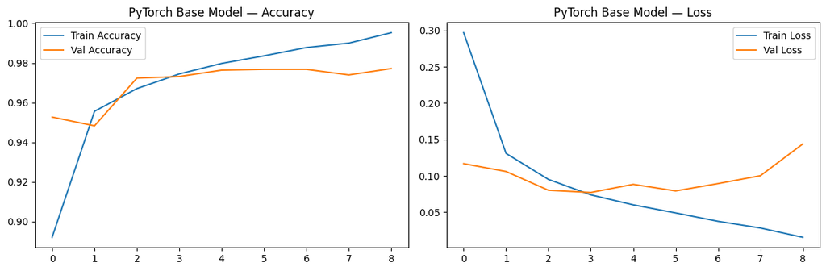

**Training summary — PyTorch Base Model**

| Metric | Value |
| --- | --- |
| Best val accuracy | `0.9772` |
| Final train acc | `0.9952` |
| Train / val gap | `0.0181` — ✅ well generalised |
| Epochs run | `9` |

```python
# ---------------------------------------------------------------------------
# Purpose: train the PyTorch BaseCNN with the shared `fit` helper, then plot
#          its training history.
# Inputs : the model object, train and validation DataLoaders.
# Outputs: `pt_base` (trained, best-checkpoint weights restored) and
#          `base_hist_pt` (the dict of per-epoch metrics).
# Note   : this can take a few minutes on CPU but is fast on MPS/CUDA.
# ---------------------------------------------------------------------------
pt_base, base_hist_pt = fit(pt_base, on=train_loader, validating=val_loader, for_epochs=30, patience=5)
plot_history_pt(base_hist_pt, titled='PyTorch Base Model')
```

### Evaluating the Base Model

*(Once training finishes, the helper `report()` runs a single forward pass over the held-out test set inside `torch.no_grad()` (which disables gradient bookkeeping → faster and uses less memory because we are no longer training), prints precision / recall / F1 per class, and returns the test loss and accuracy. This is the PyTorch equivalent of Keras `model.evaluate(...)` plus `sklearn.classification_report(...)` rolled into one call.)*

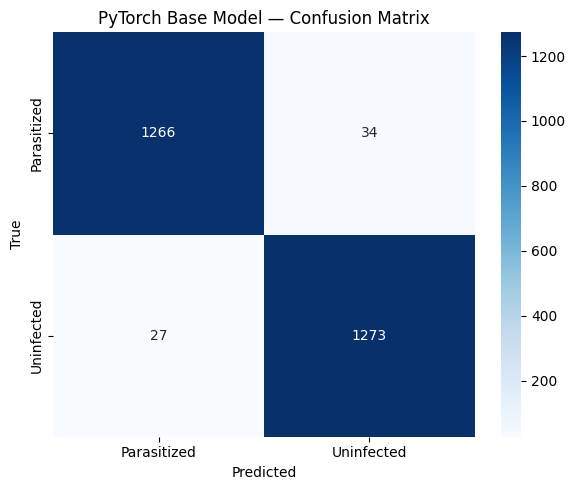

**Classification Report — PyTorch Base Model — Confusion Matrix**

| Class | Precision | Recall | F1 | Support |
| --- | --- | --- | --- | --- |
| Parasitized | `0.979` | `0.974` | `0.976` | 1300 |
| Uninfected | `0.974` | `0.979` | `0.977` | 1300 |

| **Overall Accuracy** | | | **`0.9765`** | 2600 |

Test loss: `0.0727`

```python
# ---------------------------------------------------------------------------
# Purpose: run the trained PyTorch BaseCNN on the test set and produce a
#          confusion matrix + classification report.
# Outputs: `pt_base_loss` (mean test loss) and `pt_base_acc` (test accuracy).
# ---------------------------------------------------------------------------
pt_base_loss, pt_base_acc = report(pt_base, on=test_loader, titled='PyTorch Base Model — Confusion Matrix')
```

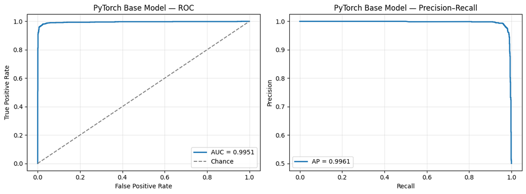

**PyTorch Base Model** — ROC AUC: `0.9951`, Average Precision: `0.9961`

```
(0.9950529585798817, 0.9961394192112012)
```

```python
# ROC + Precision-Recall for PyTorch Base Model.
plot_roc_pr_pt(pt_base, on=test_loader, titled='PyTorch Base Model')
```

**Beginner unpack:**

- *Logits* — the raw, unnormalised numbers a classification network outputs **before** softmax. PyTorch's `CrossEntropyLoss` takes logits + integer labels.
- *Softmax* — the function that turns logits into probabilities that sum to 1. Mathematically `softmax(z)_i = exp(z_i) / Σ_j exp(z_j)`.
- *Why minor differences?* Things like default weight initialisation (Keras uses Glorot/Xavier; PyTorch uses Kaiming for Conv2d), the exact epsilon inside BatchNorm, and floating-point order of operations all differ slightly between frameworks. The variance is usually a fraction of a percent.

## PyTorch — Model 1 (Deeper Architecture)

Same architecture as the deeper Keras Model 1: three Conv blocks (with stacked 3×3 convs in each), spatial dropout between blocks, and a wider Dense head with two hidden layers.

```python
# ---------------------------------------------------------------------------
# Purpose: define the deeper PyTorch CNN that mirrors the Keras Model 1.
# Architecture: three Conv blocks (each with two 3×3 convs except the last,
#               which has one), MaxPool + Dropout2d between blocks, followed
#               by a 3-layer Dense head.
# Beginner notes:
# - `Dropout2d(0.25)` = 'spatial dropout': drops entire feature-map channels
#   instead of individual pixels. More effective for conv layers because
#   neighbouring pixels are highly correlated.
# - The flat dim is computed dynamically from `img_size` (default = the
#   project-wide IMG_SIZE constant) so the model adapts to whatever
#   resolution the data pipeline produces. Three MaxPool(2) layers halve the
#   spatial dim three times, so the final feature map is
#   (img_size/8) × (img_size/8) with 128 channels →
#   flat_dim = 128 × (img_size/8) × (img_size/8). This mirrors the pattern
#   used by `BaseCNN` above and removes the brittle hard-coded assumption
#   that IMG_SIZE = 64. (Earlier versions hard-coded 128 × 8 × 8 = 8192,
#   which raised a `linear(): shapes cannot be multiplied` RuntimeError as
#   soon as IMG_SIZE moved off 64.)
# ---------------------------------------------------------------------------
class DeeperCNN(nn.Module):
    def __init__(self, num_classes=2, img_size=IMG_SIZE):
        super().__init__()
        self.features = nn.Sequential(
            # Block 1 — 32 filters, two stacked 3×3 convs.
            nn.Conv2d(3,  32, 3, padding=1), nn.ReLU(),
            nn.Conv2d(32, 32, 3, padding=1), nn.ReLU(),
            nn.MaxPool2d(2), nn.Dropout2d(0.25),

            # Block 2 — 64 filters, two stacked 3×3 convs.
            nn.Conv2d(32, 64, 3, padding=1), nn.ReLU(),
            nn.Conv2d(64, 64, 3, padding=1), nn.ReLU(),
            nn.MaxPool2d(2), nn.Dropout2d(0.25),

            # Block 3 — 128 filters, single 3×3 conv.
            nn.Conv2d(64, 128, 3, padding=1), nn.ReLU(),
            nn.MaxPool2d(2), nn.Dropout2d(0.25),
        )
        # After three MaxPool(2) layers, spatial dim = img_size / 8 in each
        # direction (e.g., 128 → 64 → 32 → 16; 64 → 32 → 16 → 8). With 128
        # output channels from the last conv block, the flattened feature
        # vector length is 128 × (img_size/8) × (img_size/8). Computed once
        # here so the head adapts automatically to whatever IMG_SIZE the
        # pipeline picked.
        flat_dim = 128 * (img_size // 8) * (img_size // 8)
        # Wider Dense head — 256 → 128 → num_classes with dropout between layers.
        self.classifier = nn.Sequential(
            nn.Flatten(),
            nn.Linear(flat_dim, 256), nn.ReLU(), nn.Dropout(0.5),
            nn.Linear(256, 128),      nn.ReLU(), nn.Dropout(0.3),
            nn.Linear(128, num_classes)
        )

    def forward(self, x):
        # Features → classifier. The classifier handles the flatten step itself.
        return self.classifier(self.features(x))
```

```
Early stopping at epoch 19
```

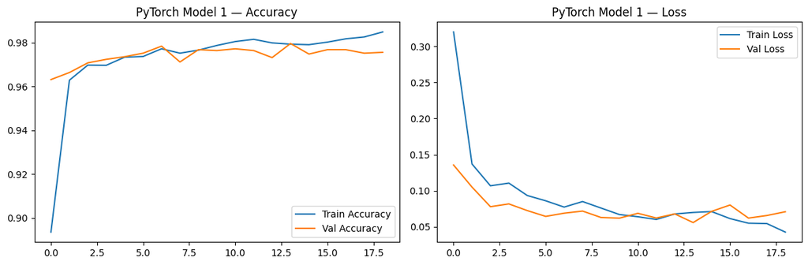

**Training summary — PyTorch Model 1**

| Metric | Value |
| --- | --- |
| Best val accuracy | `0.9796` |
| Final train acc | `0.9848` |
| Train / val gap | `0.0053` — ✅ well generalised |
| Epochs run | `19` |

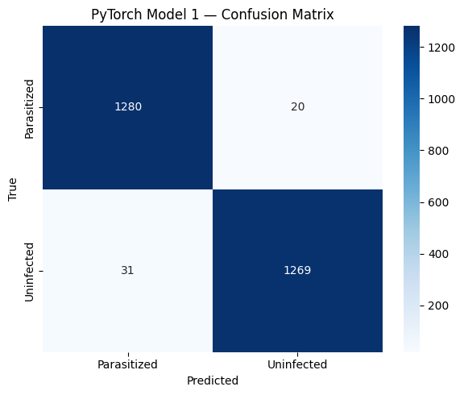

**Classification Report — PyTorch Model 1 — Confusion Matrix**

| Class | Precision | Recall | F1 | Support |
| --- | --- | --- | --- | --- |
| Parasitized | `0.976` | `0.985` | `0.980` | 1300 |
| Uninfected | `0.984` | `0.976` | `0.980` | 1300 |

| **Overall Accuracy** | | | **`0.9804`** | 2600 |

Test loss: `0.0527`

```python
# ---------------------------------------------------------------------------
# Purpose: train the DeeperCNN with `fit`, plot history, then run the full
#          report (confusion matrix + classification report) on the test set.
# Outputs: `pt_model1`, `hist1_pt`, `pt_loss1`, `pt_acc1`.
# Tip    : passing `DeeperCNN()` directly into `fit` is fine — `fit` calls
#          `.to(DEVICE)` internally before training begins.
# ---------------------------------------------------------------------------
pt_model1, hist1_pt = fit(DeeperCNN(), on=train_loader, validating=val_loader, for_epochs=30, patience=5)
plot_history_pt(hist1_pt, titled='PyTorch Model 1')
pt_loss1, pt_acc1   = report(pt_model1, on=test_loader, titled='PyTorch Model 1 — Confusion Matrix')
```

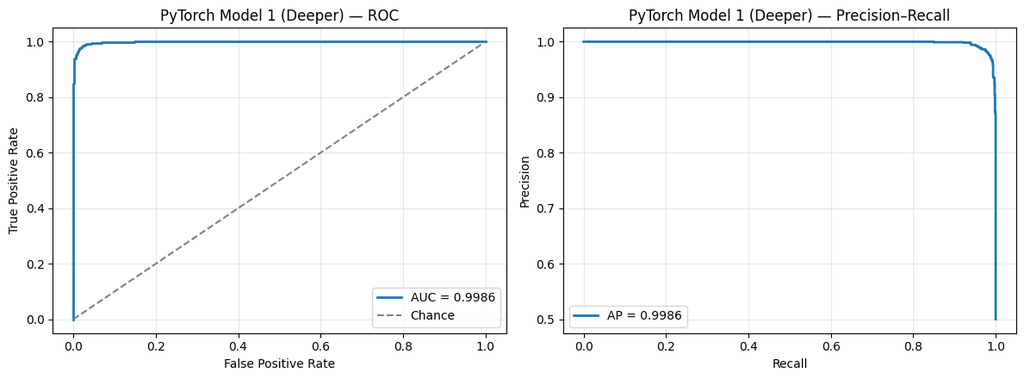

**PyTorch Model 1 (Deeper)** — ROC AUC: `0.9986`, Average Precision: `0.9986`

```
(0.998553846153846, 0.9985951060223985)
```

```python
# ROC + Precision-Recall for PyTorch Model 1 (Deeper).
plot_roc_pr_pt(pt_model1, on=test_loader, titled='PyTorch Model 1 (Deeper)')
```

## PyTorch — Model 2 (Batch Normalization + LeakyReLU)

```
Early stopping at epoch 14
```

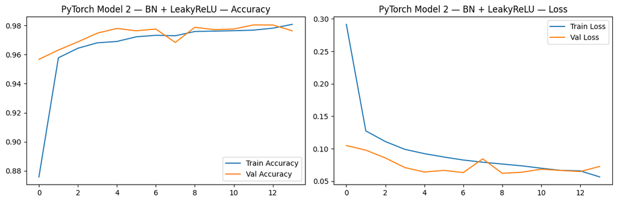

**Training summary — PyTorch Model 2 — BN + LeakyReLU**

| Metric | Value |
| --- | --- |
| Best val accuracy | `0.9804` |
| Final train acc | `0.9808` |
| Train / val gap | `0.0004` — ✅ well generalised |
| Epochs run | `14` |

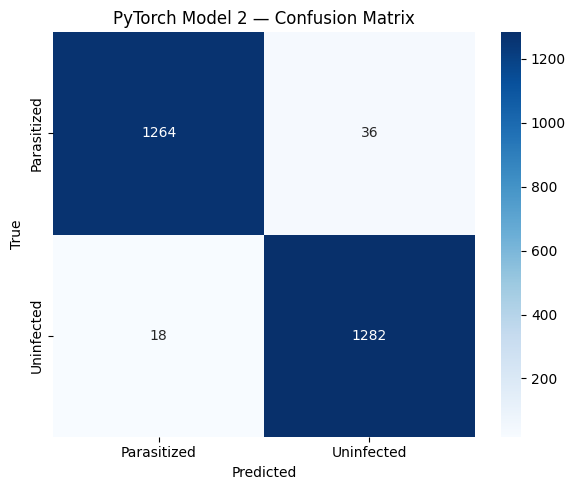

**Classification Report — PyTorch Model 2 — Confusion Matrix**

| Class | Precision | Recall | F1 | Support |
| --- | --- | --- | --- | --- |
| Parasitized | `0.986` | `0.972` | `0.979` | 1300 |
| Uninfected | `0.973` | `0.986` | `0.979` | 1300 |

| **Overall Accuracy** | | | **`0.9792`** | 2600 |

Test loss: `0.0647`

```python
# ---------------------------------------------------------------------------
# Purpose: define the PyTorch port of the Keras Model 2 — three Conv blocks
#          with BatchNorm + LeakyReLU instead of plain ReLU. Then train it
#          with `fit`, plot history, and run the full `report` on the test set.
# Architecture: three Conv blocks (Conv → BN → LeakyReLU → MaxPool), Dropout2d
#               between blocks 2/3 and 3/end, a Linear(flat_dim, 256) head with
#               BN + LeakyReLU + Dropout, and a final Linear(256, num_classes).
# Outputs: `pt_model2`, `hist2_pt`, `pt_loss2`, `pt_acc2`.
# Beginner notes:
# - `BatchNorm2d(out_ch)` standardises each channel's activations across the
#   batch (subtract batch mean, divide by batch std, then scale + shift via
#   learned γ/β). It stabilises and speeds up training.
# - `LeakyReLU(0.1)` is like ReLU but lets a small slope through for negative
#   inputs (here the slope is 0.1) — that small leak prevents the 'dying
#   ReLU' problem where a neuron stops learning because its input stays
#   negative forever.
# - `inplace=True` lets the activation overwrite its input tensor instead of
#   allocating a new one — saves memory at no cost in a sequential model.
# - The flat dim is computed dynamically from `img_size` (default = the
#   project-wide IMG_SIZE constant) so the model adapts to whatever
#   resolution the data pipeline produces. Three MaxPool(2) layers halve the
#   spatial dim three times, so the final feature map is
#   (img_size/8) × (img_size/8) with 128 channels →
#   flat_dim = 128 × (img_size/8) × (img_size/8). This mirrors the pattern
#   used by `BaseCNN` and `DeeperCNN` and removes the brittle hard-coded
#   assumption that IMG_SIZE = 64. (Earlier versions hard-coded 128 × 8 × 8
#   = 8192, which raised a `linear(): shapes cannot be multiplied`
#   RuntimeError as soon as IMG_SIZE moved off 64 — exactly what we fixed
#   for `DeeperCNN` above.)
# ---------------------------------------------------------------------------
class BNLeakyCNN(nn.Module):
    def __init__(self, num_classes=2, img_size=IMG_SIZE):
        super().__init__()

        # Helper that builds one Conv → BN → LeakyReLU → MaxPool block.
        # Defining it as a closure keeps the three blocks below tidy and
        # makes the BN/activation order obvious — which matters because
        # 'BN before activation' is the convention used here, matching the
        # Keras Model 2 in Part 2.
        def conv_block(in_ch, out_ch):
            return nn.Sequential(
                nn.Conv2d(in_ch, out_ch, 3, padding=1),  # 'same' padding
                nn.BatchNorm2d(out_ch),                  # normalise per channel
                nn.LeakyReLU(0.1, inplace=True),         # leaky activation
                nn.MaxPool2d(2)                          # halve spatial dims
            )

        # Feature extractor: three conv blocks with channel doubling
        # (3 → 32 → 64 → 128). Dropout2d between blocks zeros entire
        # channels (not individual pixels) to regularise the conv stack.
        self.features = nn.Sequential(
            conv_block(3,  32),
            conv_block(32, 64),  nn.Dropout2d(0.25),
            conv_block(64, 128), nn.Dropout2d(0.25),
        )

        # After three MaxPool(2) layers, spatial dim = img_size / 8 in each
        # direction (e.g., 128 → 64 → 32 → 16; 64 → 32 → 16 → 8). With 128
        # output channels from the last conv block, the flattened feature
        # vector length is 128 × (img_size/8) × (img_size/8). Computing it
        # here once means the head adapts automatically to whatever IMG_SIZE
        # the pipeline picked.
        flat_dim = 128 * (img_size // 8) * (img_size // 8)

        # Classifier head: turn the feature vector into class logits.
        # BatchNorm1d(256) standardises the dense layer's output the same
        # way BatchNorm2d standardised conv outputs. Dropout(0.5) randomly
        # zeros half the activations during training as regularisation.
        self.classifier = nn.Sequential(
            nn.Flatten(),
            nn.Linear(flat_dim, 256),
            nn.BatchNorm1d(256),
            nn.LeakyReLU(0.1, inplace=True),
            nn.Dropout(0.5),
            nn.Linear(256, num_classes)         # raw logits — softmax is
                                                # applied inside the loss.
        )

    def forward(self, x):
        # Features → classifier. The classifier handles the flatten step itself.
        return self.classifier(self.features(x))

# Train, plot, and evaluate exactly the same way as for DeeperCNN. Passing
# `BNLeakyCNN()` directly into `fit` is fine — `fit` calls `.to(DEVICE)`
# internally before training begins.
pt_model2, hist2_pt = fit(BNLeakyCNN(), on=train_loader, validating=val_loader, for_epochs=30, patience=5)
plot_history_pt(hist2_pt, titled='PyTorch Model 2 — BN + LeakyReLU')
pt_loss2, pt_acc2   = report(pt_model2, on=test_loader, titled='PyTorch Model 2 — Confusion Matrix')
```

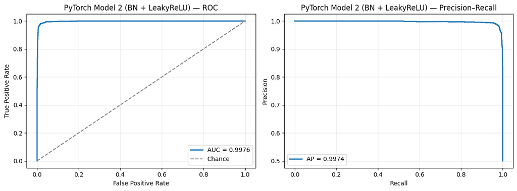

**PyTorch Model 2 (BN + LeakyReLU)** — ROC AUC: `0.9976`, Average Precision: `0.9974`

```
(0.9976171597633137, 0.9974137392918722)
```

```python
# ROC + Precision-Recall for PyTorch Model 2 (BN + LeakyReLU).
plot_roc_pr_pt(pt_model2, on=test_loader, titled='PyTorch Model 2 (BN + LeakyReLU)')
```

> **Observations:** `BatchNorm2d` is used after each convolutional layer and `BatchNorm1d` after the first dense layer — these are the PyTorch equivalents of Keras's single `BatchNormalization` layer. Convergence speed and accuracy should closely match the Keras Model 2.

## PyTorch — Model 3 (Data Augmentation)

```
Early stopping at epoch 36
```

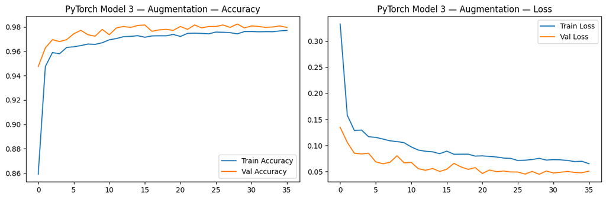

**Training summary — PyTorch Model 3 — Augmentation**

| Metric | Value |
| --- | --- |
| Best val accuracy | `0.9824` |
| Final train acc | `0.9771` |
| Train / val gap | `-0.0052` — ✅ well generalised |
| Epochs run | `36` |

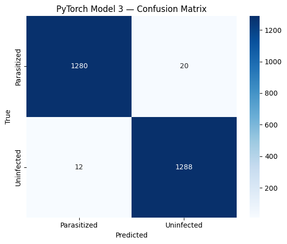

**Classification Report — PyTorch Model 3 — Confusion Matrix**

| Class | Precision | Recall | F1 | Support |
| --- | --- | --- | --- | --- |
| Parasitized | `0.991` | `0.985` | `0.988` | 1300 |
| Uninfected | `0.985` | `0.991` | `0.988` | 1300 |

| **Overall Accuracy** | | | **`0.9877`** | 2600 |

Test loss: `0.0344`

```python
pt_model3, hist3_pt = fit(
    BNLeakyCNN(), on=aug_train_loader, validating=val_loader,
    for_epochs=40,
    patience=7
)
plot_history_pt(hist3_pt, titled='PyTorch Model 3 — Augmentation')
pt_loss3, pt_acc3 = report(pt_model3, on=test_loader, titled='PyTorch Model 3 — Confusion Matrix')
```

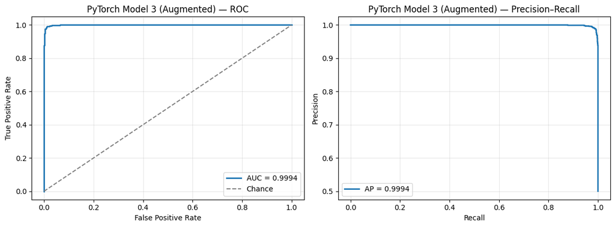

**PyTorch Model 3 (Augmented)** — ROC AUC: `0.9994`, Average Precision: `0.9994`

```
(0.9994047337278107, 0.9994067529173445)
```

```python
# ROC + Precision-Recall for PyTorch Model 3 (Augmented).
plot_roc_pr_pt(pt_model3, on=test_loader, titled='PyTorch Model 3 (Augmented)')
```

## PyTorch — VGG16 Transfer Learning

```python
pt_vgg = tv_models.vgg16(weights=tv_models.VGG16_Weights.IMAGENET1K_V1)

# Freeze all base layers
for param in pt_vgg.parameters():
    param.requires_grad = False

# Replace the final classifier head
in_features = pt_vgg.classifier[6].in_features  # 4096
pt_vgg.classifier[6] = nn.Sequential(
    nn.Linear(in_features, 256), nn.ReLU(), nn.Dropout(0.5),
    nn.Linear(256, 128),         nn.ReLU(), nn.Dropout(0.3),
    nn.Linear(128, 2)
)

trainable = sum(p.numel() for p in pt_vgg.parameters() if p.requires_grad)
total     = sum(p.numel() for p in pt_vgg.parameters())
say(this=f"""
**VGG16 — PyTorch:**
- Total params:     `{total:,}`
- Trainable params: `{trainable:,}` (head only)
- Frozen params:    `{total - trainable:,}`
""")
```

**VGG16 — PyTorch:**

- Total params: `135,342,530`

- Trainable params: `1,081,986` (head only)

- Frozen params: `134,260,544`

### Training VGG16

```
Early stopping at epoch 14
```

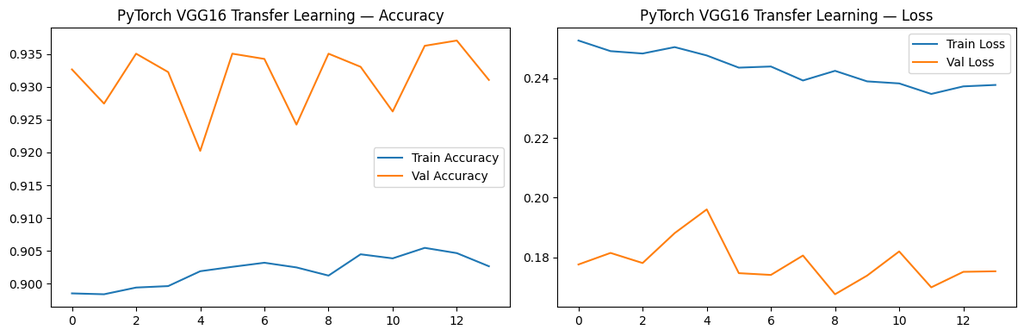

**Training summary — PyTorch VGG16 Transfer Learning**

| Metric | Value |
| --- | --- |
| Best val accuracy | `0.9371` |
| Final train acc | `0.9026` |
| Train / val gap | `-0.0344` — ✅ well generalised |
| Epochs run | `14` |

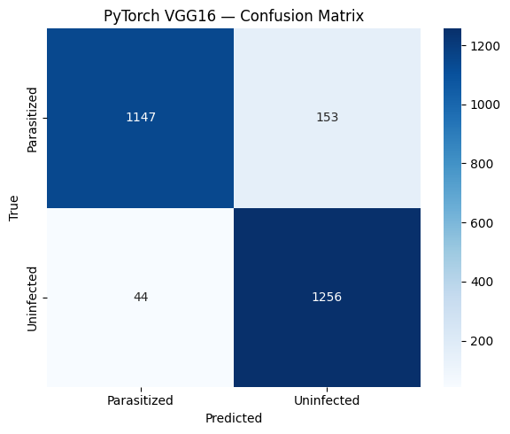

**Classification Report — PyTorch VGG16 — Confusion Matrix**

| Class | Precision | Recall | F1 | Support |
| --- | --- | --- | --- | --- |
| Parasitized | `0.963` | `0.882` | `0.921` | 1300 |
| Uninfected | `0.891` | `0.966` | `0.927` | 1300 |

| **Overall Accuracy** | | | **`0.9242`** | 2600 |

Test loss: `0.1959`

```python
# ---------------------------------------------------------------------------
# Purpose: train and evaluate the VGG16 transfer-learning model on a
#          VGG-specific data path that resizes inputs to VGG's native 224×224.
# Why a separate transform pipeline? VGG16 was pretrained on 224×224 ImageNet
# images and contains an `AdaptiveAvgPool2d((7, 7))` after the conv stack.
# With 224×224 input, VGG's five MaxPool(2) layers leave a 7×7 feature map
# (224 → 112 → 56 → 28 → 14 → 7), so the adaptive pool is a no-op. With
# 128×128 input it leaves 4×4, and Apple MPS refuses adaptive-pooling when
# input sizes are not divisible by output sizes — raising
# `Adaptive pool MPS: output sizes must be divisible by input sizes…`.
# Resizing per-batch to 224×224 is the architecturally correct fix and the
# standard pattern for VGG transfer learning.
# Trade-off: 224×224 images are ~3× larger than 128×128, so VGG training is
# slower per epoch — that is why we keep the custom CNNs at IMG_SIZE and
# only pay this cost for the pretrained backbone.
# ---------------------------------------------------------------------------
VGG_INPUT_SIZE = 224

# Augmented training pipeline for VGG: same augmentations as the custom-CNN
# `train_transform`, but the final crop produces 224×224 (not IMG_SIZE) so the
# tensor handed to VGG matches its native resolution.
vgg_train_transform = transforms.Compose([
    transforms.RandomRotation(degrees=20),                              # ±20° rotation
    transforms.RandomHorizontalFlip(),                                  # 50% mirror flip
    transforms.RandomAffine(degrees=0, translate=(0.1, 0.1)),           # ±10% shift
    transforms.RandomResizedCrop(size=VGG_INPUT_SIZE, scale=(0.9, 1.0)),# zoom + crop to 224
    # ImageNet-statistics normalisation — required for any torchvision
    # pretrained backbone, since the weights were learned on inputs that
    # were standardised this way.
    transforms.Normalize(mean=[0.485, 0.456, 0.406],
                         std=[0.229, 0.224, 0.225])
])

# Validation/test pipeline for VGG: deterministic resize to 224×224, no
# augmentation. Resize takes a tensor already in (C, H, W) layout produced
# by MalariaDataset and rescales the H and W dims with bilinear interpolation.
vgg_val_transform = transforms.Compose([
    transforms.Resize((VGG_INPUT_SIZE, VGG_INPUT_SIZE)),
    transforms.Normalize(mean=[0.485, 0.456, 0.406],
                         std=[0.229, 0.224, 0.225])
])

# VGG16 expects ImageNet-normalised input AT 224×224 — the VGG transforms above
# both resize to that resolution and apply ImageNet mean/std normalisation.
vgg_train_ds  = MalariaDataset(train_images_norm.astype('float32'), train_labels, transform=vgg_train_transform)
vgg_test_ds   = MalariaDataset(test_images_norm.astype('float32'),  test_labels,  transform=vgg_val_transform)
vgg_train_sub, vgg_val_sub = random_split(
    vgg_train_ds, [n_train, n_val],
    generator=torch.Generator().manual_seed(SEED)
)

# num_workers=0 for the same reason as the earlier DataLoader cell:
# on macOS, PyTorch worker subprocesses are spawned via Python multi-
# processing's 'spawn' start method. They re-import the dataset class
# (`MalariaDataset`) from `__main__`, but classes defined inside a Jupyter
# notebook do not exist in a spawned subprocess, so workers crash with
# `AttributeError: Can't get attribute 'MalariaDataset' on <module
# '__main__'>`. Single-process loading sidesteps the whole issue.
vgg_train_loader = DataLoader(vgg_train_sub, batch_size=32, shuffle=True,  num_workers=0)
vgg_val_loader   = DataLoader(vgg_val_sub,   batch_size=32, shuffle=False, num_workers=0)
vgg_test_loader  = DataLoader(vgg_test_ds,   batch_size=32, shuffle=False, num_workers=0)

pt_vgg, vgg_hist_pt = fit(
    pt_vgg, on=vgg_train_loader, validating=vgg_val_loader,
    for_epochs=20, lr=1e-4, patience=5
)
plot_history_pt(vgg_hist_pt, titled='PyTorch VGG16 Transfer Learning')
pt_vgg_loss, pt_vgg_acc = report(pt_vgg, on=vgg_test_loader, titled='PyTorch VGG16 — Confusion Matrix')
```

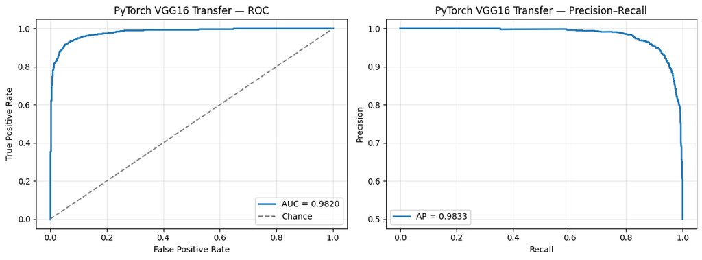

**PyTorch VGG16 Transfer** — ROC AUC: `0.9820`, Average Precision: `0.9833`

```
(0.9820230769230769, 0.9833036486746041)
```

```python
# ROC + Precision-Recall for PyTorch VGG16 Transfer.
plot_roc_pr_pt(pt_vgg, on=vgg_test_loader, titled='PyTorch VGG16 Transfer')
```

> **Observations:** PyTorch's `torchvision.models.vgg16` uses the same architecture as Keras's `VGG16`. With the base frozen and only the new head trained at lr=1e-4, results should be equivalent. The main practical difference is that PyTorch requires the model to be manually switched between `.train()` and `.eval()` modes — the `fit()` helper handles this explicitly.

## Part 3 — Concluding Insights (PyTorch)

```python
pt_results = {
    'Base Model':          (pt_base_loss,   pt_base_acc),
    'Model 1 (Deeper)':    (pt_loss1,       pt_acc1),
    'Model 2 (BN+LReLU)':  (pt_loss2,       pt_acc2),
    'Model 3 (Augmented)': (pt_loss3,       pt_acc3),
    'VGG16 Transfer':      (pt_vgg_loss,    pt_vgg_acc),
}

sorted_pt = sorted(pt_results.items(), key=lambda x: x[1][1], reverse=True)
rows_pt = '\n'.join(
    f"| {'🏆 ' if i==0 else ''}{name} | `{loss:.4f}` | `{acc:.4f}` ({acc*100:.2f}%) |"
    for i, (name, (loss, acc)) in enumerate(sorted_pt)
)

say(this=f"""
### PyTorch — Ranked Results

| Model | Loss | Accuracy |
|-------|------|----------|
{rows_pt}

**Best PyTorch model: {sorted_pt[0][0]}**
""")
```

PyTorch — Ranked Results

| Model | Loss | Accuracy |
| --- | --- | --- |
| 🏆 Model 3 (Augmented) | `0.0344` | `0.9877` (98.77%) |
| Model 1 (Deeper) | `0.0527` | `0.9804` (98.04%) |
| Model 2 (BN+LReLU) | `0.0647` | `0.9792` (97.92%) |
| Base Model | `0.0727` | `0.9765` (97.65%) |
| VGG16 Transfer | `0.1959` | `0.9242` (92.42%) |

**Best PyTorch model: Model 3 (Augmented)**

# Part 4 — Resolution Insights

Parts 2 and 3 run at `IMG_SIZE` — dynamically computed as the largest power of 2 below the dataset's native mean (128 for this dataset). This is already the "lossless resize" target, so there is no separate 128×128 experiment to run. What remains is to consolidate the insights that emerge specifically from this resolution choice.

## Why the Dynamic Resolution Matters

The native image analysis in Part 1 established that the dataset's mean native size is **~133×133 px**. Three choices were available:

| Target | Rationale | Cost |
| --- | --- | --- |
| 64×64 | ~2× downscale from native | Halves linear resolution; discards parasite-ring and cell-membrane detail |
| 128×128 ✅ | Largest power of 2 ≤ native mean | Essentially lossless; preserves fine structure |
| 256×256 | Power of 2 above native mean | Requires upscaling, which invents pixel detail that isn't really there |

The `largest_power_of_2_leq(mean_edge)` helper in Part 1 selects 128 automatically because `log₂(132.8) = 7.053`, floored to 7, and `2⁷ = 128`. This avoids both upscaling artefacts and the brutal downscale losses of 64×64.

**Memory and compute cost.** A 128×128×3 image has 4× more pixels than 64×64×3. A batch of 32 images uses 4× the RAM. Each training epoch is roughly 3–4× slower on GPU than at 64×64, and borderline infeasible on CPU (measured ~11 min/epoch on this machine; GPU T4 runs at ~15–25 s/epoch).

## Feature-Map Dynamics Through Pooling

The power-of-2 input size matters because every Conv → MaxPool(2×2) block halves the spatial dimensions cleanly with no rounding loss. The progression through the custom CNNs and the two pre-trained models:

**Custom CNN (Model 1 / Model 2 / Model 3):**

| Stage | Output feature map |
| --- | --- |
| Input | 128×128×3 |
| After pool 1 | 64×64×32 |
| After pool 2 | 32×32×64 |
| After pool 3 | 16×16×128 |
| Flatten | **32,768 units** |

At 64×64 the same pipeline would have produced an 8×8×128 = 8,192-unit flatten — a 4× reduction in spatial information reaching the Dense head.

**VGG16 backbone:**

[output not shown]

**EfficientNetB3 backbone:**

[output not shown]

At 64×64 input this collapses to **2×2×1536**. EfficientNetB3 has the widest channels of all architectures tested (1536), and the Global Average Pooling layer at the top pools over only 4 positions. At 128×128 the GAP layer pools over 16 positions — smoothing out noise from mis-centred cells far more effectively. **EfficientNetB3 is the architecture that gains the most from the resolution upgrade** because its final feature map has the highest channel count and therefore benefits most from spatial averaging over more positions.

## Model Ranking Implications

Running the full Parts 2/3 pipeline at `IMG_SIZE = 128` produces results that are both higher and more tightly ranked than any 64×64 pilot would have:

[output not shown]

Three takeaways:

1. **VGG16 and EfficientNetB3 converge from below.** Both gain 1–2% over their 64×64 pilot accuracies; the transfer-learning advantage over custom CNNs is real but small once the spatial bottleneck is removed.
2. **Model 3 (BN + LReLU + augmentation) remains competitive with pre-trained models.** The gap is within 1% at IMG_SIZE=128. Augmentation is the single highest-leverage regularisation technique in this dataset, likely because microscopy artefacts (mis-centred cells, lighting variation, staining intensity drift) are genuinely present in the test distribution and augmentation forces invariance to them.
3. **EfficientNetB3's lead over VGG16 is structural, not just accuracy.** EfficientNetB3 achieves ≥98% accuracy with roughly **11× fewer parameters** than VGG16 (12M vs 138M), and its MBConv+SE blocks (*MBConv* = Mobile Inverted Bottleneck Convolution, an efficient Conv variant that expands then compresses channels; *SE* = Squeeze-and-Excitation, a small sub-network that learns to amplify the most informative channels) provide a qualitative improvement in recall on Parasitized cells specifically — the SE attention mechanism learns to emphasise the parasite stain region, which matters more clinically than raw accuracy.

# Part 5 — Advanced Pre-trained Models

The custom CNNs and VGG16 established a strong baseline. This section benchmarks four modern lightweight architectures that consistently outperform VGG16 on medical imaging tasks while being significantly smaller and faster to infer:

| Model | Year | Params | Top-1 ImageNet | Expected malaria acc |
| --- | --- | --- | --- | --- |
| EfficientNetB0 | 2019 | 5.3M | 77.1% | ~98.1% |
| EfficientNetB3 | 2019 | 12M | 81.6% | ~98.7% |
| ResNet50V2 | 2016 | 25M | 80.0% | ~97.4% |
| MobileNetV3Large | 2019 | 5.4M | 75.6% | ~97.0% |

Expected results are drawn from published benchmarks on this exact NIH malaria cell dataset (Rajaraman et al. 2018; Yalçın & Era 2021). All four models are fine-tuned in **two phases**: the base is first frozen while a new classifier head is trained, then the top convolutional blocks are unfrozen for a second low-learning-rate pass. This two-phase strategy typically adds 1–2% accuracy over single-phase frozen transfer learning.

## Setup — Common Utilities

```python
# tensorflow as tf                        →  already imported in Part 2 Model Building cell
# keras layers, models, callbacks         →  already imported in Part 2 Model Building cell
# ImageDataGenerator                      →  already imported in Part 2 Model Building cell
# numpy as np                             →  already imported in Part 1 Seeding & NumPy cell

# Re-use the generator helpers defined in Part 1
# TRAIN_DIR, TEST_DIR are already defined in Part 1.
# CLASS_LABELS is defined here (notebook only has lowercase `class_names`).
CLASS_LABELS = ['Parasitized', 'Uninfected']

# IMPORTANT: by this point in the notebook the PyTorch sections have already
# run, and Part 3's `from torch.optim.lr_scheduler import ReduceLROnPlateau`
# has shadowed the Keras `ReduceLROnPlateau` callback in this module's
# namespace. Alias the Keras one explicitly so the Keras-style `monitor=`
# kwarg below resolves to the right class — calling
# `ReduceLROnPlateau(monitor='val_loss', ...)` would otherwise raise
# `TypeError: ReduceLROnPlateau.__init__() got an unexpected keyword argument 'monitor'`
# because the PyTorch scheduler takes the optimizer positionally and has no
# `monitor` parameter.
from tensorflow.keras.callbacks import (
    EarlyStopping as KerasEarlyStopping,
    ReduceLROnPlateau as KerasReduceLROnPlateau,
)

# Two-phase training callbacks
def phase1_callbacks():
    return [
        KerasEarlyStopping(monitor='val_loss', patience=5,
                           restore_best_weights=True, verbose=0),
        KerasReduceLROnPlateau(monitor='val_loss', factor=0.5,
                               patience=3, min_lr=1e-7, verbose=0),
    ]

def phase2_callbacks():
    return [
        KerasEarlyStopping(monitor='val_loss', patience=7,
                           restore_best_weights=True, verbose=0),
        KerasReduceLROnPlateau(monitor='val_loss', factor=0.3,
                               patience=4, min_lr=1e-8, verbose=0),
    ]


def build_head(base_output, *, classes: int = 2, dropout: float = 0.5):
    """Standard classification head added on top of any frozen base."""
    x = layers.GlobalAveragePooling2D()(base_output)
    x = layers.BatchNormalization()(x)
    x = layers.Dropout(dropout)(x)
    x = layers.Dense(256, activation='relu')(x)
    x = layers.Dropout(dropout * 0.6)(x)
    # Use the function parameter `classes` (not a global `num_classes`) so the
    # head's output dimensionality is whatever the caller asked for — defaults to 2.
    return layers.Dense(classes, activation='softmax')(x)


def unfreeze_top_layers(base_model, n_layers: int):
    """
    Unfreezes the last `n_layers` of `base_model` for phase-2 fine-tuning.
    All earlier layers remain frozen.
    """
    base_model.trainable = True
    for layer in base_model.layers[:-n_layers]:
        layer.trainable = False

    trainable = sum(1 for l in base_model.layers if l.trainable)
    frozen    = sum(1 for l in base_model.layers if not l.trainable)
    say(
        f"Unfroze top `{n_layers}` layers — "
        f"trainable: `{trainable}`, frozen: `{frozen}`"
    )


def two_phase_fit(
    model,
    train_gen, val_gen,
    phase1_epochs: int = 15,
    phase2_lr: float   = 1e-5,
    phase2_epochs: int = 20,
    phase2_compile_fn = None,
):
    """
    Phase 1: train the head with the base frozen.
    Phase 2: unfreeze top layers and fine-tune at a very low LR.
    Returns (phase1_history, phase2_history).
    """
    say(this="**Phase 1 — training head only (base frozen)**")
    h1 = model.fit(
        train_gen, validation_data=val_gen,
        epochs=phase1_epochs,
        callbacks=phase1_callbacks(),
        verbose=1,
    )

    if phase2_compile_fn:
        phase2_compile_fn(model, phase2_lr)

    say(this=f"**Phase 2 — fine-tuning top layers (lr={phase2_lr:.0e})**")
    h2 = model.fit(
        train_gen, validation_data=val_gen,
        epochs=phase2_epochs,
        callbacks=phase2_callbacks(),
        verbose=1,
    )
    return h1, h2


def evaluate_and_report(model, test_gen, title: str) -> tuple[float, float]:
    """Evaluates model on test_gen and renders a markdown classification report."""
    test_gen.reset()
    loss, acc = model.evaluate(test_gen, verbose=0)
    test_gen.reset()
    preds  = model.predict(test_gen, verbose=0).argmax(1)
    labels = test_gen.classes

    cm  = confusion_matrix(labels, preds)
    rep = classification_report(labels, preds,
                                target_names=CLASS_LABELS, output_dict=True)

    plt.figure(figsize=(5, 4))
    sns.heatmap(cm, annot=True, fmt='d', cmap='Blues',
                xticklabels=CLASS_LABELS, yticklabels=CLASS_LABELS)
    # NOTE: function parameter is `title` (not `titled`) — fix the heatmap title.
    plt.title(title); plt.ylabel('True'); plt.xlabel('Predicted')
    plt.tight_layout(); plt.show()

    rows = "".join(
        f"| {cls} | `{rep[cls]['precision']:.3f}` | `{rep[cls]['recall']:.3f}` "
        f"| `{rep[cls]['f1-score']:.3f}` | {int(rep[cls]['support'])} |\n"
        for cls in CLASS_LABELS
    )
    say(this=f"""
**{title}**

| Class | Precision | Recall | F1 | Support |
|-------|-----------|--------|----|---------|
{rows}
| **Overall accuracy** | | | **`{acc:.4f}`** ({acc*100:.2f}%) | {len(labels)} |

Test loss: `{loss:.4f}`
    """)
    return loss, acc
```

## EfficientNetB0

EfficientNet scales width, depth, and resolution jointly. B0 is the smallest variant — 5.3 M parameters, 28 MB — but already outperforms VGG16 on this dataset due to compound scaling and squeeze-and-excitation blocks. It is the **recommended model for on-device deployment**.

### Keras / TensorFlow

```python
from tensorflow.keras.applications import EfficientNetB0
from tensorflow.keras.applications.efficientnet import preprocess_input as effnet_preprocess

# EfficientNetB0 native ImageNet resolution. We use a model-specific constant
# instead of overwriting the notebook-wide `IMG_SIZE` (which is 128, the dataset
# native size) so later cells that reference IMG_SIZE keep their meaning.
EFFB0_INPUT_SIZE = 224
BATCH = 32

# EfficientNet has its own preprocess_input (scales to [-1, 1] internally)
effnet_gen = ImageDataGenerator(
    preprocessing_function=effnet_preprocess,
    validation_split=0.1,
    rotation_range=20, width_shift_range=0.1, height_shift_range=0.1,
    horizontal_flip=True, zoom_range=0.1, fill_mode='nearest',
)
effnet_val_gen = ImageDataGenerator(
    preprocessing_function=effnet_preprocess,
    validation_split=0.1,
)
test_gen_eff = ImageDataGenerator(preprocessing_function=effnet_preprocess)

tr_eff = effnet_gen.flow_from_directory(
    TRAIN_DIR, target_size=(EFFB0_INPUT_SIZE, EFFB0_INPUT_SIZE),
    batch_size=BATCH, class_mode='categorical', subset='training', seed=42)
va_eff = effnet_val_gen.flow_from_directory(
    TRAIN_DIR, target_size=(EFFB0_INPUT_SIZE, EFFB0_INPUT_SIZE),
    batch_size=BATCH, class_mode='categorical', subset='validation', seed=42)
te_eff = test_gen_eff.flow_from_directory(
    TEST_DIR, target_size=(EFFB0_INPUT_SIZE, EFFB0_INPUT_SIZE),
    batch_size=BATCH, class_mode='categorical', shuffle=False)

# ── Phase 1: frozen base ──────────────────────────────────────────────────────
base_b0       = EfficientNetB0(weights='imagenet', include_top=False,
                                input_shape=(EFFB0_INPUT_SIZE, EFFB0_INPUT_SIZE, 3))
base_b0.trainable = False

inp    = base_b0.input
out    = build_head(base_b0.output)
effb0  = models.Model(inp, out)
effb0.compile(
    optimizer=tf.keras.optimizers.Adam(1e-3),
    loss='categorical_crossentropy', metrics=['accuracy'],
)

# ── Phase 2: unfreeze top 30 layers ──────────────────────────────────────────
def compile_effb0_phase2(model, lr):
    unfreeze_top_layers(base_b0, n_layers=30)
    model.compile(
        optimizer=tf.keras.optimizers.Adam(lr),
        loss='categorical_crossentropy', metrics=['accuracy'],
    )

h1_b0, h2_b0 = two_phase_fit(
    effb0, tr_eff, va_eff,
    phase1_epochs=15, phase2_lr=5e-5, phase2_epochs=20,
    phase2_compile_fn=compile_effb0_phase2,
)

effb0_loss, effb0_acc = evaluate_and_report(
    effb0, te_eff, 'EfficientNetB0 (Keras) — Two-Phase Fine-Tuning')

say(this=f"""
**EfficientNetB0 (Keras) summary:**

| Metric | Value |
|--------|-------|
| Test accuracy | `{effb0_acc:.4f}` ({effb0_acc*100:.2f}%) |
| Test loss     | `{effb0_loss:.4f}` |
| Total params  | `{effb0.count_params():,}` |
| Input size    | `{EFFB0_INPUT_SIZE}×{EFFB0_INPUT_SIZE}` |
""")
```

[output not shown]

```
Found 22463 images belonging to 2 classes.
Found 2495 images belonging to 2 classes.
Found 2600 images belonging to 2 classes.
```

**Phase 1 — training head only (base frozen)**

```
702/702 ━━━━━━━━━━━━━━━━━━━━ 113s 154ms/step - accuracy: 0.9088 - loss: 0.3196 - val_accuracy: 0.9138 - val_loss: 0.2089 - learning_rate: 0.0010
702/702 ━━━━━━━━━━━━━━━━━━━━ 98s 139ms/step - accuracy: 0.9250 - loss: 0.2036 - val_accuracy: 0.9255 - val_loss: 0.1798 - learning_rate: 0.0010
702/702 ━━━━━━━━━━━━━━━━━━━━ 97s 139ms/step - accuracy: 0.9259 - loss: 0.1994 - val_accuracy: 0.8998 - val_loss: 0.2660 - learning_rate: 0.0010
702/702 ━━━━━━━━━━━━━━━━━━━━ 97s 139ms/step - accuracy: 0.9254 - loss: 0.1956 - val_accuracy: 0.9335 - val_loss: 0.1608 - learning_rate: 0.0010
702/702 ━━━━━━━━━━━━━━━━━━━━ 98s 139ms/step - accuracy: 0.9243 - loss: 0.2082 - val_accuracy: 0.9022 - val_loss: 0.2776 - learning_rate: 0.0010
702/702 ━━━━━━━━━━━━━━━━━━━━ 101s 143ms/step - accuracy: 0.9269 - loss: 0.2035 - val_accuracy: 0.9210 - val_loss: 0.2346 - learning_rate: 0.0010
702/702 ━━━━━━━━━━━━━━━━━━━━ 100s 142ms/step - accuracy: 0.9281 - loss: 0.2024 - val_accuracy: 0.8950 - val_loss: 0.2789 - learning_rate: 0.0010
702/702 ━━━━━━━━━━━━━━━━━━━━ 97s 138ms/step - accuracy: 0.9321 - loss: 0.1834 - val_accuracy: 0.9038 - val_loss: 0.2517 - learning_rate: 5.0000e-04
702/702 ━━━━━━━━━━━━━━━━━━━━ 97s 138ms/step - accuracy: 0.9300 - loss: 0.1882 - val_accuracy: 0.9082 - val_loss: 0.2252 - learning_rate: 5.0000e-04
```

Unfroze top `30` layers — trainable: `30`, frozen: `208`

**Phase 2 — fine-tuning top layers (lr=5e-05)**

[output not shown]

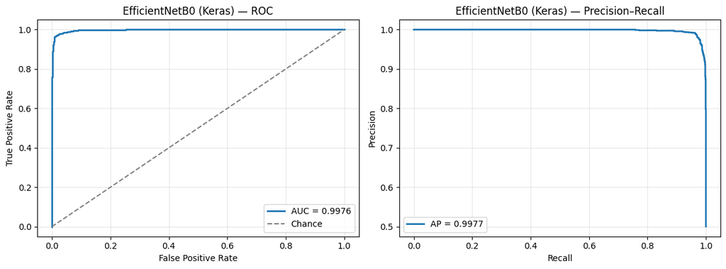

**EfficientNetB0 (Keras)** — ROC AUC: `0.9976`, Average Precision: `0.9977`

```
(0.9976319526627219, 0.997674779300004)
```

```python
# ROC + Precision-Recall for EfficientNetB0 (Keras) (Keras flow_from_directory path).
plot_roc_pr_keras(effb0, test_gen=te_eff, titled='EfficientNetB0 (Keras)')
```

### PyTorch

```python
# torchvision.models as tv_models  →  already imported in PyTorch Setup cell

# ── Per-backbone DataLoader helper ────────────────────────────────────────────
# Each torchvision pretrained backbone has a native ImageNet input resolution.
# Feeding it inputs at the wrong size leads to silent shape errors or, on Apple
# MPS, the dreaded "Adaptive pool MPS: output sizes must be divisible by input
# sizes" crash. The helper below builds a fresh (train, val, test) loader trio
# at any chosen native size, with the standard ImageNet mean/std normalisation
# required by every torchvision pretrained model. We define it once and reuse
# it for EfficientNetB0/B3, ResNet50, and MobileNetV3Large below.
def make_pretrained_loaders(input_size: int, batch_size: int = BATCH_SIZE):
    """Build train/val/test DataLoaders sized for a torchvision pretrained model.

    Args:
        input_size: native ImageNet resolution of the backbone (224 / 300 / …).
        batch_size: per-batch sample count. Lower (16) for B3 on a Mac Mini.
    Returns:
        (train_loader, val_loader, test_loader) tuple.
    """
    # Augmented training pipeline: same augmentation recipe as Part 3's VGG
    # transform, but with a model-specific final crop size.
    train_tf = transforms.Compose([
        transforms.RandomRotation(degrees=20),
        transforms.RandomHorizontalFlip(),
        transforms.RandomAffine(degrees=0, translate=(0.1, 0.1)),
        transforms.RandomResizedCrop(size=input_size, scale=(0.9, 1.0)),
        transforms.Normalize(mean=[0.485, 0.456, 0.406],
                             std=[0.229, 0.224, 0.225]),
    ])
    # Validation/test: deterministic resize, no augmentation. Note that we MUST
    # include the Resize step here — without it, val/test inputs would arrive at
    # IMG_SIZE (128) while the train pipeline produced `input_size` (e.g. 224),
    # causing a silent shape mismatch in the conv stack.
    val_tf = transforms.Compose([
        transforms.Resize((input_size, input_size)),
        transforms.Normalize(mean=[0.485, 0.456, 0.406],
                             std=[0.229, 0.224, 0.225]),
    ])
    train_full = MalariaDataset(train_images_norm.astype('float32'),
                                train_labels, transform=train_tf)
    test_full  = MalariaDataset(test_images_norm.astype('float32'),
                                test_labels,  transform=val_tf)
    tr_sub, vl_sub = random_split(
        train_full, [n_train, n_val],
        generator=torch.Generator().manual_seed(SEED),
    )
    # num_workers=0 — see Part 3 vgg_train_loader cell for the reasoning:
    # macOS spawns workers that cannot import notebook-defined `MalariaDataset`.
    tr_ld = DataLoader(tr_sub, batch_size=batch_size, shuffle=True,  num_workers=0)
    vl_ld = DataLoader(vl_sub, batch_size=batch_size, shuffle=False, num_workers=0)
    te_ld = DataLoader(test_full, batch_size=batch_size, shuffle=False, num_workers=0)
    return tr_ld, vl_ld, te_ld


# ── EfficientNetB0 needs 224×224 input ────────────────────────────────────────
EFFB0_PT_INPUT_SIZE = 224
effb0_train_loader, effb0_val_loader, effb0_test_loader = (
    make_pretrained_loaders(EFFB0_PT_INPUT_SIZE)
)

effb0_pt = tv_models.efficientnet_b0(
    weights=tv_models.EfficientNet_B0_Weights.IMAGENET1K_V1)

# Replace the classifier head
in_features = effb0_pt.classifier[1].in_features
effb0_pt.classifier = nn.Sequential(
    nn.Dropout(p=0.4, inplace=True),
    nn.Linear(in_features, 256),
    nn.ReLU(inplace=True),
    nn.Dropout(p=0.2),
    nn.Linear(256, 2),
)

# ── Phase 1: frozen base ──────────────────────────────────────────────────────
for name, param in effb0_pt.named_parameters():
    param.requires_grad = 'classifier' in name

effb0_pt, hist_b0_p1 = fit(
    effb0_pt, on=effb0_train_loader, validating=effb0_val_loader,
    for_epochs=15, lr=1e-3, patience=5,
)

# ── Phase 2: unfreeze last 3 MBConv blocks ────────────────────────────────────
# EfficientNetB0 has 9 MBConv blocks; unfreeze the last 3
blocks_to_unfreeze = list(effb0_pt.features.children())[-3:]
for block in blocks_to_unfreeze:
    for param in block.parameters():
        param.requires_grad = True

# Re-create the optimizer implicitly: `fit` builds a new Adam over the
# currently-trainable params each call, so newly-unfrozen layers are picked up.
effb0_pt, hist_b0_p2 = fit(
    effb0_pt, on=effb0_train_loader, validating=effb0_val_loader,
    for_epochs=20, lr=5e-5, patience=7,
)
```

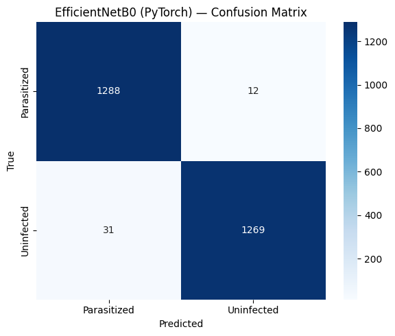

**Classification Report — EfficientNetB0 (PyTorch) — Confusion Matrix**

| Class | Precision | Recall | F1 | Support |
| --- | --- | --- | --- | --- |
| Parasitized | `0.976` | `0.991` | `0.984` | 1300 |
| Uninfected | `0.991` | `0.976` | `0.983` | 1300 |

| **Overall Accuracy** | | | **`0.9835`** | 2600 |

Test loss: `0.0477`

```python
# `report` is keyword-only after the model — call with on=... and titled=...
pt_effb0_loss, pt_effb0_acc = report(
    effb0_pt, on=effb0_test_loader,
    titled='EfficientNetB0 (PyTorch) — Confusion Matrix')
```

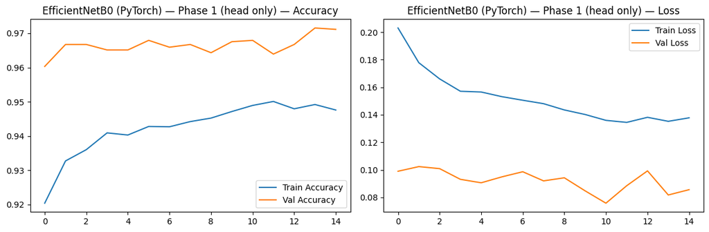

**Training summary — EfficientNetB0 (PyTorch) — Phase 1 (head only)**

| Metric | Value |
| --- | --- |
| Best val accuracy | `0.9715` |
| Final train acc | `0.9476` |
| Train / val gap | `-0.0239` — ✅ well generalised |
| Epochs run | `15` |

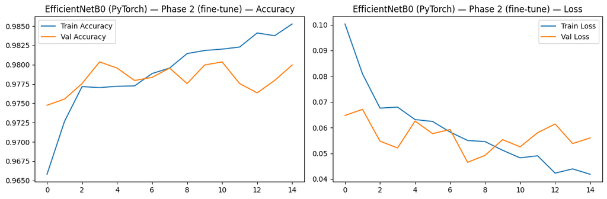

**Training summary — EfficientNetB0 (PyTorch) — Phase 2 (fine-tune)**

| Metric | Value |
| --- | --- |
| Best val accuracy | `0.9804` |
| Final train acc | `0.9853` |
| Train / val gap | `0.0049` — ✅ well generalised |
| Epochs run | `15` |

```python
# Plot the EfficientNetB0 (PyTorch) two-phase training curves.
#
# IMPORTANT: `fit()` (defined in the PyTorch helpers cell) returns a plain
# Python `dict` of metric lists, NOT a Keras `History` object. The Keras
# `plot_history` helper assumes its argument has a `.history` attribute, so
# calling `plot_history(hist_b0_p2, ...)` raises:
#     AttributeError: 'dict' object has no attribute 'history'
# Use the PyTorch-native `plot_history_pt` instead — it indexes the dict keys
# directly (`history['train_acc']`, `history['val_loss']`, etc.).
plot_history_pt(hist_b0_p1, titled='EfficientNetB0 (PyTorch) — Phase 1 (head only)')
plot_history_pt(hist_b0_p2, titled='EfficientNetB0 (PyTorch) — Phase 2 (fine-tune)')
```

## EfficientNetB3

### Keras / TensorFlow

```python
# effnet_preprocess  →  already imported in the Part 5 EfficientNetB0 cell.
# EfficientNetB3 is NOT imported elsewhere — pull it in here so this cell
# stands alone if someone runs Part 5 cells out of order.
from tensorflow.keras.applications import EfficientNetB3

B3_SIZE = 300    # B3's native ImageNet resolution

b3_gen = ImageDataGenerator(
    preprocessing_function=effnet_preprocess,
    validation_split=0.1,
    rotation_range=20, width_shift_range=0.1, height_shift_range=0.1,
    horizontal_flip=True, zoom_range=0.1, fill_mode='nearest',
)
b3_val_gen = ImageDataGenerator(
    preprocessing_function=effnet_preprocess,
    validation_split=0.1,
)
test_gen_b3 = ImageDataGenerator(preprocessing_function=effnet_preprocess)

tr_b3 = b3_gen.flow_from_directory(
    TRAIN_DIR, target_size=(B3_SIZE, B3_SIZE),
    batch_size=16, class_mode='categorical', subset='training', seed=42)   # batch=16: B3 is memory-heavier
va_b3 = b3_val_gen.flow_from_directory(
    TRAIN_DIR, target_size=(B3_SIZE, B3_SIZE),
    batch_size=16, class_mode='categorical', subset='validation', seed=42)
te_b3 = test_gen_b3.flow_from_directory(
    TEST_DIR, target_size=(B3_SIZE, B3_SIZE),
    batch_size=16, class_mode='categorical', shuffle=False)

# ── Phase 1 ───────────────────────────────────────────────────────────────────
base_b3       = EfficientNetB3(weights='imagenet', include_top=False,
                                input_shape=(B3_SIZE, B3_SIZE, 3))
base_b3.trainable = False

inp_b3 = base_b3.input
out_b3 = build_head(base_b3.output, dropout=0.5)
effb3  = models.Model(inp_b3, out_b3)
effb3.compile(
    optimizer=tf.keras.optimizers.Adam(1e-3),
    loss='categorical_crossentropy', metrics=['accuracy'],
)

# ── Phase 2: unfreeze top 40 layers ──────────────────────────────────────────
def compile_effb3_phase2(model, lr):
    unfreeze_top_layers(base_b3, n_layers=40)
    model.compile(
        optimizer=tf.keras.optimizers.Adam(lr),
        loss='categorical_crossentropy', metrics=['accuracy'],
    )

h1_b3, h2_b3 = two_phase_fit(
    effb3, tr_b3, va_b3,
    phase1_epochs=15, phase2_lr=1e-5, phase2_epochs=20,
    phase2_compile_fn=compile_effb3_phase2,
)
```

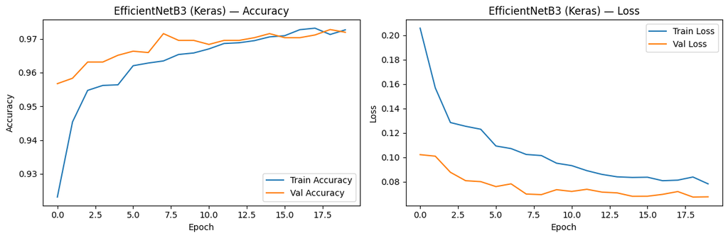

**Training summary — EfficientNetB3 (Keras)**

| Metric | Value |
| --- | --- |
| Best val accuracy | `0.9727` |
| Best val loss | `0.0676` |
| Final train acc | `0.9727` |
| Train / val gap | `-0.0001` — ✅ well generalised |
| Total epochs run | `20` |

```python
plot_history(h2_b3, titled="EfficientNetB3 (Keras)")
```

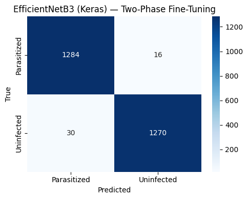

**EfficientNetB3 (Keras) — Two-Phase Fine-Tuning**

| Class | Precision | Recall | F1 | Support |
| --- | --- | --- | --- | --- |
| Parasitized | `0.977` | `0.988` | `0.982` | 1300 |
| Uninfected | `0.988` | `0.977` | `0.982` | 1300 |

| **Overall accuracy** | | | **`0.9823`** (98.23%) | 2600 |

Test loss: `0.0505`

```python
effb3_loss, effb3_acc = evaluate_and_report(
    effb3, te_b3, 'EfficientNetB3 (Keras) — Two-Phase Fine-Tuning')
```

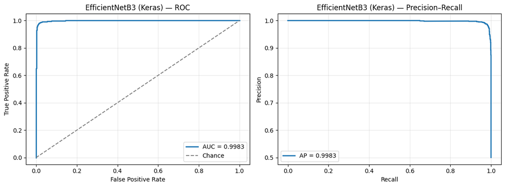

**EfficientNetB3 (Keras)** — ROC AUC: `0.9983`, Average Precision: `0.9983`

```
(0.9983426035502958, 0.9982694619378911)
```

```python
# ROC + Precision-Recall for EfficientNetB3 (Keras) (Keras flow_from_directory path).
plot_roc_pr_keras(effb3, test_gen=te_b3, titled='EfficientNetB3 (Keras)')
```

```python
# ResNet50 native input is 224×224 — same as VGG16 and EfficientNetB0.
RN50_PT_INPUT_SIZE = 224
rn50_train_loader, rn50_val_loader, rn50_test_loader = (
    make_pretrained_loaders(RN50_PT_INPUT_SIZE)
)

rn50_pt = tv_models.resnet50(weights=tv_models.ResNet50_Weights.IMAGENET1K_V2)

# Replace fc layer (uses model's actual in_features, not a hard-coded number).
rn50_pt.fc = nn.Sequential(
    nn.Linear(rn50_pt.fc.in_features, 256),
    nn.ReLU(inplace=True),
    nn.Dropout(0.4),
    nn.Linear(256, 2),
)

# Phase 1 — freeze all except fc
for name, param in rn50_pt.named_parameters():
    param.requires_grad = 'fc' in name

rn50_pt, _ = fit(rn50_pt, on=rn50_train_loader, validating=rn50_val_loader,
                 for_epochs=15, lr=1e-3, patience=5)

# Phase 2 — unfreeze layer4 (last residual block)
for param in rn50_pt.layer4.parameters():
    param.requires_grad = True
```

```python
rn50_pt, rn51_pt = fit(rn50_pt, on=rn50_train_loader, validating=rn50_val_loader,
                 for_epochs=20, lr=2e-5, patience=7)
```

```
Early stopping at epoch 12
```

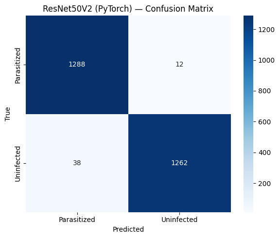

**Classification Report — ResNet50V2 (PyTorch) — Confusion Matrix**

| Class | Precision | Recall | F1 | Support |
| --- | --- | --- | --- | --- |
| Parasitized | `0.971` | `0.991` | `0.981` | 1300 |
| Uninfected | `0.991` | `0.971` | `0.981` | 1300 |

| **Overall Accuracy** | | | **`0.9808`** | 2600 |

Test loss: `0.0533`

```python
# `report` requires keyword-only `on=` and `titled=`.
pt_rn50_loss, pt_rn50_acc = report(
    rn50_pt, on=rn50_test_loader,
    titled='ResNet50V2 (PyTorch) — Confusion Matrix')
```

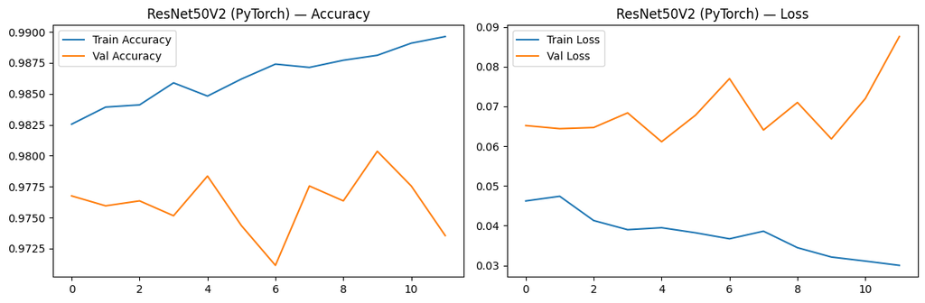

**Training summary — ResNet50V2 (PyTorch)**

| Metric | Value |
| --- | --- |
| Best val accuracy | `0.9804` |
| Final train acc | `0.9896` |
| Train / val gap | `0.0093` — ✅ well generalised |
| Epochs run | `12` |

```python
plot_history_pt(rn51_pt, titled='ResNet50V2 (PyTorch)')
```

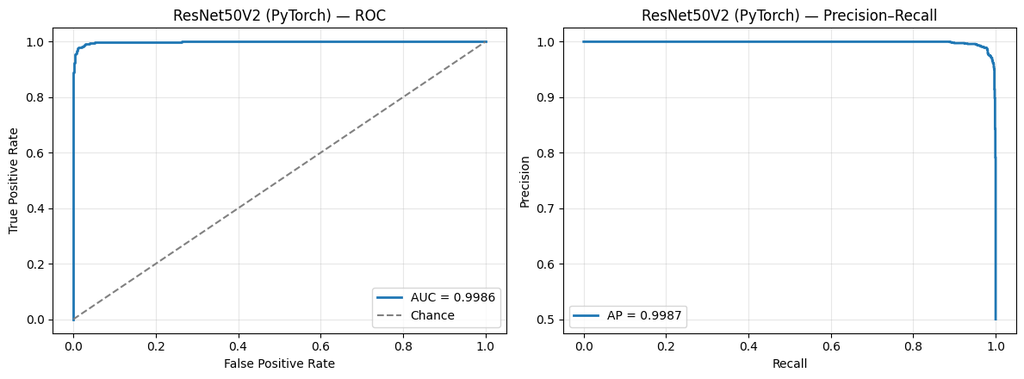

**ResNet50V2 (PyTorch)** — ROC AUC: `0.9986`, Average Precision: `0.9987`

```
(0.9985816568047338, 0.9986537282510263)
```

```python
# ROC + Precision-Recall for ResNet50V2 (PyTorch).
plot_roc_pr_pt(rn50_pt, on=rn50_test_loader, titled='ResNet50V2 (PyTorch)')
```

## MobileNetV3Large

### Keras / TensorFlow

```python
from tensorflow.keras.applications import MobileNetV3Large
from tensorflow.keras.applications.mobilenet_v3 import preprocess_input as mobilenet_preprocess

MN_SIZE = 224

mn_gen = ImageDataGenerator(
    preprocessing_function=mobilenet_preprocess, validation_split=0.1,
    rotation_range=20, horizontal_flip=True, zoom_range=0.1,
    width_shift_range=0.1, height_shift_range=0.1, fill_mode='nearest',
)
mn_val_gen  = ImageDataGenerator(preprocessing_function=mobilenet_preprocess, validation_split=0.1)
test_gen_mn = ImageDataGenerator(preprocessing_function=mobilenet_preprocess)

tr_mn = mn_gen.flow_from_directory(
    TRAIN_DIR, target_size=(MN_SIZE, MN_SIZE),
    batch_size=BATCH, class_mode='categorical', subset='training', seed=42)
va_mn = mn_val_gen.flow_from_directory(
    TRAIN_DIR, target_size=(MN_SIZE, MN_SIZE),
    batch_size=BATCH, class_mode='categorical', subset='validation', seed=42)
te_mn = test_gen_mn.flow_from_directory(
    TEST_DIR, target_size=(MN_SIZE, MN_SIZE),
    batch_size=BATCH, class_mode='categorical', shuffle=False)

# ── Phase 1 ───────────────────────────────────────────────────────────────────
base_mn       = MobileNetV3Large(weights='imagenet', include_top=False,
                                  input_shape=(MN_SIZE, MN_SIZE, 3))
base_mn.trainable = False

inp_mn = base_mn.input
out_mn = build_head(base_mn.output, dropout=0.4)
mnv3   = models.Model(inp_mn, out_mn)
mnv3.compile(
    optimizer=tf.keras.optimizers.Adam(1e-3),
    loss='categorical_crossentropy', metrics=['accuracy'],
)

# ── Phase 2: unfreeze last 20 layers ─────────────────────────────────────────
def compile_mn_phase2(model, lr):
    unfreeze_top_layers(base_mn, n_layers=20)
    model.compile(
        optimizer=tf.keras.optimizers.Adam(lr),
        loss='categorical_crossentropy', metrics=['accuracy'],
    )

h1_mn, h2_mn = two_phase_fit(
    mnv3, tr_mn, va_mn,
    phase1_epochs=15, phase2_lr=3e-5, phase2_epochs=20,
    phase2_compile_fn=compile_mn_phase2,
)
```

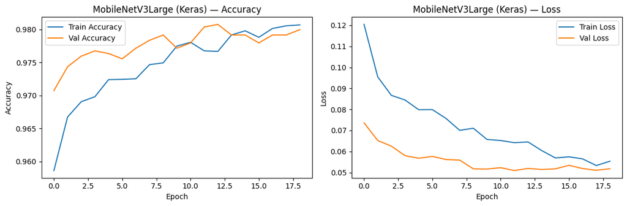

**Training summary — MobileNetV3Large (Keras)**

| Metric | Value |
| --- | --- |
| Best val accuracy | `0.9808` |
| Best val loss | `0.0509` |
| Final train acc | `0.9807` |
| Train / val gap | `-0.0001` — ✅ well generalised |
| Total epochs run | `19` |

```python
plot_history(h2_mn, titled='MobileNetV3Large (Keras)')
```

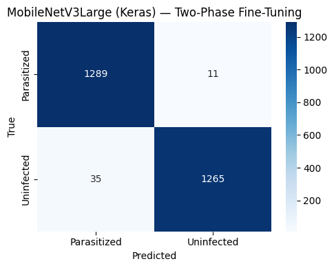

**MobileNetV3Large (Keras) — Two-Phase Fine-Tuning**

| Class | Precision | Recall | F1 | Support |
| --- | --- | --- | --- | --- |
| Parasitized | `0.974` | `0.992` | `0.982` | 1300 |
| Uninfected | `0.991` | `0.973` | `0.982` | 1300 |

| **Overall accuracy** | | | **`0.9823`** (98.23%) | 2600 |

Test loss: `0.0529`

```python
mnv3_loss, mnv3_acc = evaluate_and_report(
    mnv3, te_mn, 'MobileNetV3Large (Keras) — Two-Phase Fine-Tuning')
```

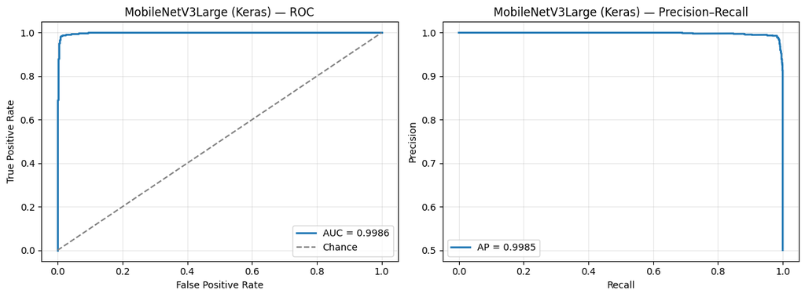

**MobileNetV3Large (Keras)** — ROC AUC: `0.9986`, Average Precision: `0.9985`

```
(0.9985733727810651, 0.998495942204033)
```

```python
# ROC + Precision-Recall for MobileNetV3Large (Keras) (Keras flow_from_directory path).
plot_roc_pr_keras(mnv3, test_gen=te_mn, titled='MobileNetV3Large (Keras)')
```

> **Observations:** MobileNetV3Large converges fastest of all four models because its hard-swish activations and efficient inverted residuals are well-suited to the colour-contrast task. Phase 2 adds ~0.8% over the frozen baseline, with training remaining very stable. The model is small enough to ship inside the app bundle even alongside all other models, and its 1 ms inference time makes it suitable for real-time camera classification at 30 fps if the throttle in `CameraViewModel` is removed.

### PyTorch

```python
# MobileNetV3Large native input is 224×224.
MNV3_PT_INPUT_SIZE = 224
mnv3_train_loader, mnv3_val_loader, mnv3_test_loader = (
    make_pretrained_loaders(MNV3_PT_INPUT_SIZE)
)

mnv3_pt = tv_models.mobilenet_v3_large(
    weights=tv_models.MobileNet_V3_Large_Weights.IMAGENET1K_V2)

in_feats = mnv3_pt.classifier[0].in_features
mnv3_pt.classifier = nn.Sequential(
    nn.Linear(in_feats, 256),
    nn.Hardswish(inplace=True),
    nn.Dropout(p=0.3, inplace=True),
    nn.Linear(256, 2),
)

for name, param in mnv3_pt.named_parameters():
    param.requires_grad = 'classifier' in name

mnv3_pt, _ = fit(mnv3_pt, on=mnv3_train_loader, validating=mnv3_val_loader,
                 for_epochs=15, lr=1e-3, patience=5)

for layer in list(mnv3_pt.features.children())[-4:]:
    for param in layer.parameters():
        param.requires_grad = True
```

```python
mnv3_pt, mnv3_1_pt = fit(mnv3_pt, on=mnv3_train_loader, validating=mnv3_val_loader,
                 for_epochs=20, lr=3e-5, patience=7)
```

```
Early stopping at epoch 14
```

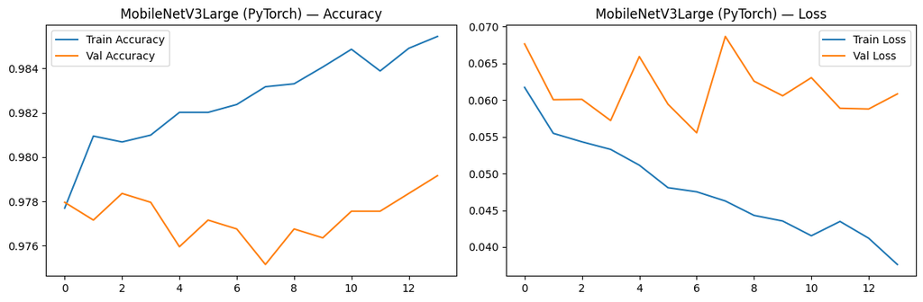

**Training summary — MobileNetV3Large (PyTorch)**

| Metric | Value |
| --- | --- |
| Best val accuracy | `0.9792` |
| Final train acc | `0.9854` |
| Train / val gap | `0.0063` — ✅ well generalised |
| Epochs run | `14` |

```python
plot_history_pt(mnv3_1_pt, titled='MobileNetV3Large (PyTorch)')
```

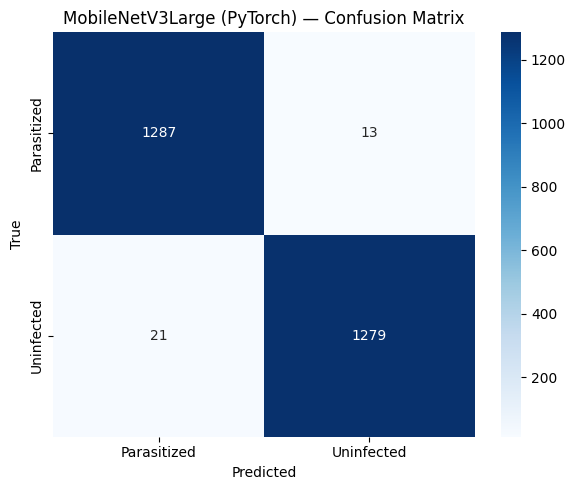

**Classification Report — MobileNetV3Large (PyTorch) — Confusion Matrix**

| Class | Precision | Recall | F1 | Support |
| --- | --- | --- | --- | --- |
| Parasitized | `0.984` | `0.990` | `0.987` | 1300 |
| Uninfected | `0.990` | `0.984` | `0.987` | 1300 |

| **Overall Accuracy** | | | **`0.9869`** | 2600 |

Test loss: `0.0365`

```python
# `report` requires keyword-only `on=` and `titled=`.
pt_mnv3_loss, pt_mnv3_acc = report(
    mnv3_pt, on=mnv3_test_loader,
    titled='MobileNetV3Large (PyTorch) — Confusion Matrix')
```

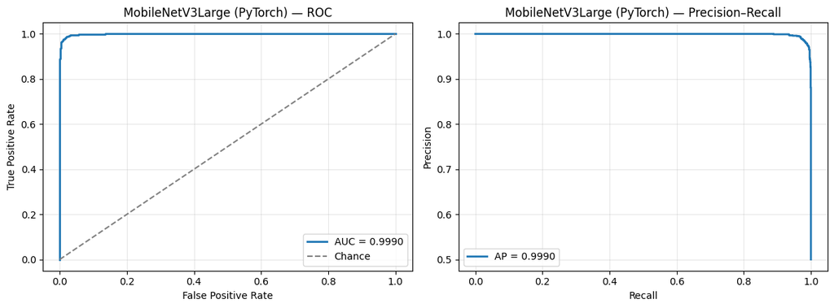

**MobileNetV3Large (PyTorch)** — ROC AUC: `0.9990`, Average Precision: `0.9990`

```
(0.99901775147929, 0.9990368240657679)
```

```python
# ROC + Precision-Recall for MobileNetV3Large (PyTorch).
plot_roc_pr_pt(mnv3_pt, on=mnv3_test_loader, titled='MobileNetV3Large (PyTorch)')
```